# SCI 1402 - RAPPORT DE PROJET

E-Commerce Sales Dataset - Analyzing and Maximizing Online Business Performance

#### Nom, prénom: Cisse, Honorine Binta

#### No étudiant: 25132503

#### Trimestre d’inscription : Automne 2025

#### Date d’envoi : “2025-12-26”

**PRÉSENTATION GÉNÉRALE DU PROJET**

**Nom du projet sélectionné** : **Ensemble de données sur les ventes de commerce électronique - Analyser et maximiser les performances commerciales en ligne**

**Motivation lors de la sélection du projet (pourquoi ce projet)**

Le commerce électronique est un secteur en pleine expansion, avec une croissance annuelle soutenue et une importance stratégique pour les entreprises.

Les données de ventes en ligne sont riches et multidimensionnelles : elles combinent informations transactionnelles, produits, clients et parfois logistique.

Ce dataset offre une opportunité pratique d’appliquer le cycle complet de la Data Science : nettoyage, exploration, visualisation, analyse statistique et Machine Learning.

Le projet est motivé par l’envie de transformer les données brutes en insights actionnables permettant d’améliorer la prise de décision dans un contexte réel.

**Type de problème et enjeux du projet :**

**Type de problème :**

Analyse descriptive (comprendre les tendances de ventes, clients, produits).

Analyse prédictive (prédire les ventes futures, identifier les produits à forte demande).

Optimisation (maximiser les performances commerciales via pricing, promotions, segmentation client).

**Enjeux :**

Améliorer les performances financières et opérationnelles.

Anticiper la demande pour une meilleure gestion des stocks.

Identifier les segments de clients stratégiques.

Définir des actions marketing basées sur des données réelles (data-driven).

**Analyse du contexte :**

Le dataset contient des transactions de ventes e-commerce : informations sur les produits, les catégories, les clients, les montants et les dates.

Le contexte concurrentiel du e-commerce impose une forte capacité d’adaptation : prix dynamiques, campagnes marketing ciblées, expérience client optimisée.

L’analyse est essentielle pour :

- Comprendre la saisonnalité des ventes.
- Identifier les produits phares et sous-performants.
- Évaluer l’impact des promotions ou remises.
- Segmenter les clients selon leur comportement d’achat.

**Définition des objectifs et hypothèses :**

**Objectifs principaux :**

1. Explorer les données pour comprendre les tendances générales (ventes, clients, produits).
2. Créer des visualisations interactives (dashboard) pour communiquer efficacement les résultats.
3. Appliquer des méthodes statistiques et de Machine Learning pour :
   - prédire les ventes futures,
   - identifier les facteurs clés de succès,
   - segmenter la clientèle.

**Hypothèses possibles :**

- H1 : Les ventes suivent une forte saisonnalité (pics en fin d’année, soldes, promotions).
- H2 : Certains produits/catégories génèrent la majorité du chiffre d’affaires (loi de Pareto 80/20).
- H3 : Les clients peuvent être segmentés en groupes distincts selon leur fréquence et leur panier moyen.
- H4 : Les remises et promotions ont un impact significatif sur les volumes de ventes.

**Description du sommaire de la méthodologie :**

**1. Collecte des données :** téléchargement depuis Kaggle, importation dans R.

**2. Préparation et nettoyage :** gestion des valeurs manquantes, doublons, outliers, formatage des dates et variables catégorielles.

**3. Exploration des données (EDA) :** statistiques descriptives, corrélations, visualisations (histogrammes, courbes temporelles, heatmaps).

**4. Visualisation & Dashboard :** création d’un dashboard interactif (Shiny) pour suivre les KPIs (ventes totales, panier moyen, top produits, top clients).

**5. Analyse statistique :** tests d’hypothèses (effet des promotions, saisonnalité), distribution des ventes par segment.

**6. Machine Learning :**

- Modèles de prévision (ARIMA, Prophet, Random Forest).
- Segmentation client (K-means, clustering hiérarchique).
- Classification des produits selon leur performance.

**7. Interprétation & Communication :** mise en valeur des résultats via graphiques, dashboards et rapport écrit.

**8. Recommandations :** stratégies pour maximiser les performances commerciales (promotions ciblées, gestion des stocks, fidélisation client).

**METHODOLOGIE**

**A - COLLECTE & PRÉPARATION DES DONNÉES**

```
     1 - COLLECTE DES DONNÉES
```

```r
# 1. Importer le fichier Amazon Sale Report
AmazonSaleReport <- read.csv("RapportProjet_Donnees/Amazon Sale Report.csv",
                             sep = ",",
                             header = TRUE)
head(AmazonSaleReport, 5)
```

|  | index | Order.ID | Date | Status | Fulfilment | Sales.Channel | ship.service.level | Style | SKU | Category | Size | ASIN | Courier.Status | Qty | currency | Amount | ship.city | ship.state | ship.postal.code | ship.country | promotion.ids | B2B | fulfilled.by | Unnamed..22 |
| --- | --- | --- | --- | --- | --- | --- | --- | --- | --- | --- | --- | --- | --- | --- | --- | --- | --- | --- | --- | --- | --- | --- | --- | --- |
| 1 | 0 | 405-8078784-5731545 | 04-30-22 | Cancelled | Merchant | Amazon.in | Standard | SET389 | SET389-KR-NP-S | Set | S | B09KXVBD7Z |  | 0 | INR | 647.62 | MUMBAI | MAHARASHTRA | 400081 | IN |  | False | Easy Ship |  |
| 2 | 1 | 171-9198151-1101146 | 04-30-22 | Shipped - Delivered to Buyer | Merchant | Amazon.in | Standard | JNE3781 | JNE3781-KR-XXXL | kurta | 3XL | B09K3WFS32 | Shipped | 1 | INR | 406.00 | BENGALURU | KARNATAKA | 560085 | IN | Amazon PLCC Free-Financing Universal Merchant AAT-WNKTBO3K27EJC,Amazon PLCC Free-Financing Universal Merchant AAT-QX3UCCJESKPA2,Amazon PLCC Free-Financing Universal Merchant AAT-5QQ7BIYYQEDN2,Amazon P… | False | Easy Ship |  |
| 3 | 2 | 404-0687676-7273146 | 04-30-22 | Shipped | Amazon | Amazon.in | Expedited | JNE3371 | JNE3371-KR-XL | kurta | XL | B07WV4JV4D | Shipped | 1 | INR | 329.00 | NAVI MUMBAI | MAHARASHTRA | 410210 | IN | IN Core Free Shipping 2015/04/08 23-48-5-108 | True |  |  |
| 4 | 3 | 403-9615377-8133951 | 04-30-22 | Cancelled | Merchant | Amazon.in | Standard | J0341 | J0341-DR-L | Western Dress | L | B099NRCT7B |  | 0 | INR | 753.33 | PUDUCHERRY | PUDUCHERRY | 605008 | IN |  | False | Easy Ship |  |
| 5 | 4 | 407-1069790-7240320 | 04-30-22 | Shipped | Amazon | Amazon.in | Expedited | JNE3671 | JNE3671-TU-XXXL | Top | 3XL | B098714BZP | Shipped | 1 | INR | 574.00 | CHENNAI | TAMIL NADU | 600073 | IN |  | False |  |  |

```r
# 2. Importer le fichier Cloud Warehouse Compersion Chart
CloudWarehouseCompersionChart <- read.csv("RapportProjet_Donnees/Cloud Warehouse Compersion Chart.csv",
                                          sep = ",",
                                          header = TRUE)
head(CloudWarehouseCompersionChart, 5)
```

|  | index | Shiprocket | Unnamed..1 | INCREFF |
| --- | --- | --- | --- | --- |
| 1 | 0 | Heads | Price (Per Unit) | Price (Per Unit) |
| 2 | 1 | Inbound (Fresh Stock and RTO) | ₹4.00 | 4 |
| 3 | 2 | Outbound | ₹7.00 | 11 |
| 4 | 3 | Storage Fee/Cft | ₹25.00 | Rs 0.15/- Per Day |
| 5 | 4 | Customer Return with Detailed QC | ₹6.00 | 15.5 |

```r
# 3. Importer le fichier Expense IIGF
ExpenseIIGF <- read.csv("RapportProjet_Donnees/Expense IIGF.csv",
                        sep = ",",
                        header = TRUE)
head(ExpenseIIGF, 5)
```

|  | index | Recived.Amount | Unnamed..1 | Expance | Unnamed..3 |
| --- | --- | --- | --- | --- | --- |
| 1 | 0 | Particular | Amount | Particular | Amount |
| 2 | 1 | 06-19-22 | 1000 | Large Bag | 380 |
| 3 | 2 | 06-20-22 | 1500 | Stationary(Soft Pin, Paper pin for Dupatta, Fevikwick) | 170 |
| 4 | 3 | 06-22-22 | 500 | OLA | 839 |
| 5 | 4 | 06-23-22 | 2000 | Auto Rent | 520 |

```r
# 4. Importer le fichier International sale Report
InternationalsaleReport <- read.csv("RapportProjet_Donnees/International sale Report.csv",
                                    sep = ",",
                                    header = TRUE)
head(InternationalsaleReport, 5)
```

|  | index | DATE | Months | CUSTOMER | Style | SKU | Size | PCS | RATE | GROSS.AMT |
| --- | --- | --- | --- | --- | --- | --- | --- | --- | --- | --- |
| 1 | 0 | 06-05-21 | Jun-21 | REVATHY LOGANATHAN | MEN5004 | MEN5004-KR-L | L | 1.00 | 616.56 | 617.00 |
| 2 | 1 | 06-05-21 | Jun-21 | REVATHY LOGANATHAN | MEN5004 | MEN5004-KR-XL | XL | 1.00 | 616.56 | 617.00 |
| 3 | 2 | 06-05-21 | Jun-21 | REVATHY LOGANATHAN | MEN5004 | MEN5004-KR-XXL | XXL | 1.00 | 616.56 | 617.00 |
| 4 | 3 | 06-05-21 | Jun-21 | REVATHY LOGANATHAN | MEN5009 | MEN5009-KR-L | L | 1.00 | 616.56 | 617.00 |
| 5 | 4 | 06-05-21 | Jun-21 | REVATHY LOGANATHAN | MEN5011 | MEN5011-KR-L | L | 1.00 | 616.56 | 617.00 |

```r
# 5. Importer le fichier May_2022
May_2022 <- read.csv("RapportProjet_Donnees/May_2022.csv",
                     sep = ",",
                     header = TRUE)
head(May_2022, 5)
```

|  | index | Sku | Style.Id | Catalog | Category | Weight | TP | MRP.Old | Final.MRP.Old | Ajio.MRP | Amazon.MRP | Amazon.FBA.MRP | Flipkart.MRP | Limeroad.MRP | Myntra.MRP | Paytm.MRP | Snapdeal.MRP |
| --- | --- | --- | --- | --- | --- | --- | --- | --- | --- | --- | --- | --- | --- | --- | --- | --- | --- |
| 1 | 0 | Os206_3141_S | Os206_3141 | Moments | Kurta | 0.3 | 538 | 2178 | 2295 | 2295 | 2295 | 2295 | 2295 | 2295 | 2295 | 2295 | 2295 |
| 2 | 1 | Os206_3141_M | Os206_3141 | Moments | Kurta | 0.3 | 538 | 2178 | 2295 | 2295 | 2295 | 2295 | 2295 | 2295 | 2295 | 2295 | 2295 |
| 3 | 2 | Os206_3141_L | Os206_3141 | Moments | Kurta | 0.3 | 538 | 2178 | 2295 | 2295 | 2295 | 2295 | 2295 | 2295 | 2295 | 2295 | 2295 |
| 4 | 3 | Os206_3141_XL | Os206_3141 | Moments | Kurta | 0.3 | 538 | 2178 | 2295 | 2295 | 2295 | 2295 | 2295 | 2295 | 2295 | 2295 | 2295 |
| 5 | 4 | Os206_3141_2XL | Os206_3141 | Moments | Kurta | 0.3 | 538 | 2178 | 2295 | 2295 | 2295 | 2295 | 2295 | 2295 | 2295 | 2295 | 2295 |

```r
# 6. Importer le fichier PL March 2021
PLMarch2021 <- read.csv("RapportProjet_Donnees/PL March 2021.csv",
                        sep = ",",
                        header = TRUE)
head(PLMarch2021, 5)
```

|  | index | Sku | Style.Id | Catalog | Category | Weight | TP.1 | TP.2 | MRP.Old | Final.MRP.Old | Ajio.MRP | Amazon.MRP | Amazon.FBA.MRP | Flipkart.MRP | Limeroad.MRP | Myntra.MRP | Paytm.MRP | Snapdeal.MRP |
| --- | --- | --- | --- | --- | --- | --- | --- | --- | --- | --- | --- | --- | --- | --- | --- | --- | --- | --- |
| 1 | 0 | Os206_3141_S | Os206_3141 | Moments | Kurta | 0.3 | 538 | 435.78 | 2178 | 2295 | 2295 | 2295 | 2295 | 2295 | 2295 | 2295 | 2295 | 2295 |
| 2 | 1 | Os206_3141_M | Os206_3141 | Moments | Kurta | 0.3 | 538 | 435.78 | 2178 | 2295 | 2295 | 2295 | 2295 | 2295 | 2295 | 2295 | 2295 | 2295 |
| 3 | 2 | Os206_3141_L | Os206_3141 | Moments | Kurta | 0.3 | 538 | 435.78 | 2178 | 2295 | 2295 | 2295 | 2295 | 2295 | 2295 | 2295 | 2295 | 2295 |
| 4 | 3 | Os206_3141_XL | Os206_3141 | Moments | Kurta | 0.3 | 538 | 435.78 | 2178 | 2295 | 2295 | 2295 | 2295 | 2295 | 2295 | 2295 | 2295 | 2295 |
| 5 | 4 | Os206_3141_2XL | Os206_3141 | Moments | Kurta | 0.3 | 538 | 435.78 | 2178 | 2295 | 2295 | 2295 | 2295 | 2295 | 2295 | 2295 | 2295 | 2295 |

```r
# 7. Importer le fichier Sale Report
SaleReport <- read.csv("RapportProjet_Donnees/Sale Report.csv",
                       sep = ",",
                       header = TRUE)
head(SaleReport, 5)
```

|  | index | SKU.Code | Design.No. | Stock | Category | Size | Color |
| --- | --- | --- | --- | --- | --- | --- | --- |
| 1 | 0 | AN201-RED-L | AN201 | 5 | AN : LEGGINGS | L | Red |
| 2 | 1 | AN201-RED-M | AN201 | 5 | AN : LEGGINGS | M | Red |
| 3 | 2 | AN201-RED-S | AN201 | 3 | AN : LEGGINGS | S | Red |
| 4 | 3 | AN201-RED-XL | AN201 | 6 | AN : LEGGINGS | XL | Red |
| 5 | 4 | AN201-RED-XXL | AN201 | 3 | AN : LEGGINGS | XXL | Red |

De prime abord, il faut décrire la représentation de chaque jeu de données.

**1. AmazonSaleReport**

**Nature du fichier**

Il s’agit d’un historique détaillé des commandes expédiées via Amazon.in.Chaque ligne correspond à une transaction (une commande client).

**Objectif**

Analyser les ventes Amazon, mesurer la performance logistique, suivre les retours et l’expédition.

**Contenu principal**

**- Order.ID :** Identifiant unique Amazon de la commande

**- Date :** Date de commande ou d’expédition

**- Status :** Statut (Shipped, Cancelled, Delivered…)

**- Fulfilment :** Qui expédie (Amazon / Merchant)

**- Sales.Channel :** Marketplace (Amazon.in)

**- ship.service.level :** Standard, Expedited…

**- Style / SKU / Category / Size :** Informations produits

**Volume**

≈ 129 000 lignes, 23 colonnes.

**Utilité dans le projet**

- Base principale pour analyser les ventes clients
- Servira à comparer les prix réels avec :
  - les tarifs logistiques (CloudWarehouse)
  - les prix catalogue (May_2022)
  - les prix PLM (PLMarch2021)

**2. CloudWarehouseCompersionChart**

**Nature du fichier**

Fichier contenant les tarifs de prestation logistique entre deux partenaires : Shiprocket et INCREFF.

**Objectif**

Comparer les coûts :

- inbound
- outbound
- stockage
- audits
- QC
- GRN
- picking / packing
- etc.

**Contenu**

- Colonne Shiprocket : types d’opérations
- Colonne Unnamed..1 : prix unitaires Shiprocket
- Colonne INCREFF : prix unitaires INCREFF

**Volume**

≈ 50 lignes, 3 colonnes.

**Utilité dans le projet**

- Calculer le coût logistique réel
- Comparer avec AmazonSaleReport
- Préparer une analyse coût / efficacité entre prestataires

**3. ExpenseIIGF**

**Nature du fichier**

Journal d’encaissements et dépenses internes (IIGF).

**Objectif**

Normaliser les dépenses pour :

- Vérifier la cohérence
- Produire un résumé financier
- Intégrer éventuellement certaines dépenses dans le coût logistique

**Contenu**

Colonnes brutes :

- Recived.Amount : montants reçus
- Unnamed..1 : montants reçus (duplicate)
- Expance : type de dépense
- Unnamed..3 : montant dépensé

Après nettoyage :

- Date
- Amount_Received
- Expense
- Expense_Amount

**Volume**

≈ 16 lignes après nettoyage

**Utilité dans le projet**

- Transparence des dépenses réelles
- Potentiel rapprochement avec les flux logistiques

**4. InternationalsaleReport**

**Nature du fichier**

- Données de ventes internationales.
- Fortement bruitées, avec colonnes mélangées (DATE/CUSTOMER), valeurs non cohérentes.

**Objectif**

- Restaurer les colonnes corrompues
- Éliminer les lignes non transactionnelles
- Détecter les incohérences économiques (PCS × RATE vs GROSS.AMT)

**Contenu**

- DATE, Months, CUSTOMER
- Style, SKU, Size
- PCS, RATE, GROSS.AMT
- Colonnes additionnées lors du nettoyage :
  - Expected_GROSS
  - Ecart

**Volume**

≈ 37 432 lignes.

**Utilité dans le projet**

- Peut servir à détecter des erreurs de facturation
- Apporte une vision des ventes export
- Permet d’identifier problèmes structurels (colonnes mélangées, client récurrent à problème, etc.)

**5. May_2022**

**Nature du fichier**

Fichier catalogue produits pour le mois de mai 2022.

**Objectif**

Fournir les informations de référence :

- Prix catalogue (MRP)
- Prix par marketplace
- Poids
- Catégorie produit

**Contenu**

- Sku, Style.Id
- Catalog / Category
- Weight
- TP (Cost price)
- MRP.Old, Final.MRP.Old
- Ajio.MRP, Amazon.MRP, Flipkart.MRP, Snapdeal.MRP, etc.

**Volume**

≈ 1330 lignes, 17 colonnes.

**Utilité**

- Référence pour comparaison des prix
- Permet d’évaluer la rentabilité par SKU
- Utilisé pour détecter les incohérences vs AmazonSaleReport

**6. PLMarch2021**

**Nature du fichier**

Catalogue PLM (Product Lifecycle Management) — version Mars 2021.

**Objectif**

- Fournir la liste complète des produits avec :
- style
- SKU
- poids
- prix internes : TP.1, TP.2
- ancien MRP

**Contenu**

- Sku, Style.Id
- Catalog, Category, Size
- Weight
- TP.1, TP.2
- MRP.Old, Final.MRP.Old

**Volume**

≈ 1300–1500 lignes.

**Utilité**

- Comparaison historique des prix
- Vérification des évolutions TP & MRP
- Base de référence pour cohérence produit

**7. SaleReport**

**Nature du fichier**

Rapport des stocks par SKU, incluant les variantes de couleur et taille.

**Objectif**

Analyser :

- Inventaire disponible
- Couverture des tailles
- Performance des designs

**Contenu**

- SKU.Code
- Design.No.
- Stock
- Category, Size, Color

**Volume**

≈ 9 271 lignes, 7 colonnes.

**Utilité**

- Associer disponibilité produit versus ventes Amazon
- Identifier ruptures de stock
- Supporter une analyse supply-chain

```
      2 - PRÉPARATION, NETTOYAGE & TRANSFORMATION DES DONNÉES
```

```r
# Charger les librairies
library(knitr)
library(dplyr)
library(tidyr)
library(tidyverse)


# Mettre tous les jeux de données dans une liste
datasets <- list(
  Amazon = AmazonSaleReport,
  International = InternationalsaleReport,
  Sale = SaleReport,
  May = May_2022,
  PLMarch = PLMarch2021,
  Cloud = CloudWarehouseCompersionChart,
  Expense = ExpenseIIGF)

# Validation
cat("✔️ datasets chargé avec", length(datasets), "jeux de données\n")
```

```
## ✔️ datasets chargé avec 7 jeux de données
```

```r
# Résumé global
check_data_quality <- function(df) {
  data.frame(
    Missing_Total = sum(is.na(df)),
    Duplicates_Total = sum(duplicated(df)),
    Rows = nrow(df),
    Columns = ncol(df))}


summary_list <- lapply(datasets, check_data_quality)
summary_table <- bind_rows(summary_list, .id = "Dataset")

# Validation
cat("✔️ summary_table créé :", nrow(summary_table), "lignes et", ncol(summary_table), "colonnes\n")
```

```
## ✔️ summary_table créé : 7 lignes et 5 colonnes
```

```r
kable(summary_table, caption = "Résumé global de la qualité des données")
```

Résumé global de la qualité des données

| Dataset | Missing_Total | Duplicates_Total | Rows | Columns |
| --- | --- | --- | --- | --- |
| Amazon | 7828 | 0 | 128975 | 24 |
| International | 0 | 0 | 37432 | 10 |
| Sale | 36 | 0 | 9271 | 7 |
| May | 0 | 0 | 1330 | 17 |
| PLMarch | 0 | 0 | 1330 | 18 |
| Cloud | 0 | 0 | 50 | 4 |
| Expense | 0 | 0 | 17 | 5 |

```r
# Détail des NA par colonne
missing_details <- lapply(names(datasets), function(name) {
  df <- datasets[[name]]
  tibble(
    Dataset = name,
    Variable = names(df),
    Missing = colSums(is.na(df))
  ) %>%
    filter(Missing > 0)})           # ne garder que colonnes avec NA

missing_table <- bind_rows(missing_details)
missing_table
```

| Dataset | Variable | Missing |
| --- | --- | --- |
| Amazon | Amount | 7795 |
| Amazon | ship.postal.code | 33 |
| Sale | Stock | 36 |

```r
if(nrow(missing_table) > 0) {
  kable(missing_table, caption = "Détail des valeurs manquantes par colonne")
} else {
  cat("✅ Aucun NA détecté dans les colonnes.")
}
```

Détail des valeurs manquantes par colonne

| Dataset | Variable | Missing |
| --- | --- | --- |
| Amazon | Amount | 7795 |
| Amazon | ship.postal.code | 33 |
| Sale | Stock | 36 |

**Résumé global**

- Amazon : 7 828 valeurs manquantes (principalement dans Amount), mais aucun doublon : jeu de données volumineux, priorité à nettoyer.
- International, May, PLMarch, Cloud, Expense : pas de NA, pas de doublons : jeux de données propres.
- Sale : 36 valeurs manquantes (dans Stock), pas de doublons.

**Détails des colonnes avec NA**

**1 . Amazon$Amount : 7 795 valeurs manquantes**

Variable critique (chiffre d’affaires / montants). Il faudra décider : Imputer (remplacer par 0, médiane, moyenne, ou valeur prédictive). Supprimer ces lignes si elles sont trop peu nombreuses par rapport à l’ensemble (7 795 sur 128 975 ≈ 6 %).

**2. Amazon$ship.postal.code : 33 valeurs manquantes**

Très faible proportion (33 sur 128 975 ≈0.03 %). Les laisser comme NA (pas d’impact fort). Ou supprimer les lignes correspondantes.

**3. Sale$Stock : 36 valeurs manquantes**

Vérifier si le Stock est essentiel à l’analyse. Si oui : imputation (exemple : médiane ou valeur par catégorie). Si non : laisser comme NA ou retirer les lignes.

**Comment traiter les valeurs manquantes?**

**1 . Amazon$Amount : 7 795 valeurs manquantes**

```r
# Extraire toutes les lignes avec au moins un NA
na_amazon <- AmazonSaleReport %>% filter(if_any(everything(), is.na))

head(na_amazon, 10)
```

|  | index | Order.ID | Date | Status | Fulfilment | Sales.Channel | ship.service.level | Style | SKU | Category | Size | ASIN | Courier.Status | Qty | currency | Amount | ship.city | ship.state | ship.postal.code | ship.country | promotion.ids | B2B | fulfilled.by | Unnamed..22 |
| --- | --- | --- | --- | --- | --- | --- | --- | --- | --- | --- | --- | --- | --- | --- | --- | --- | --- | --- | --- | --- | --- | --- | --- | --- |
| 1 | 8 | 407-5443024-5233168 | 04-30-22 | Cancelled | Amazon | Amazon.in | Expedited | SET200 | SET200-KR-NP-A-XXXL | Set | 3XL | B08L91ZZXN | Cancelled | 0 |  | NA | HYDERABAD | TELANGANA | 500008 | IN | IN Core Free Shipping 2015/04/08 23-48-5-108 | False |  |  |
| 2 | 29 | 404-5933402-8801952 | 04-30-22 | Cancelled | Merchant | Amazon.in | Standard | JNE2132 | JNE2132-KR-398-XXXL | kurta | 3XL | B07JG3CND8 |  | 0 |  | NA | GUWAHATI | ASSAM | 781003 | IN |  | False | Easy Ship |  |
| 3 | 65 | 171-4137548-0481151 | 04-30-22 | Cancelled | Amazon | Amazon.in | Expedited | JNE3373 | JNE3373-KR-XXL | kurta | XXL | B082W8RWN1 | Cancelled | 0 |  | NA | Dahod | Gujarat | 389151 | IN |  | False |  |  |
| 4 | 84 | 403-9950518-0349133 | 04-30-22 | Cancelled | Amazon | Amazon.in | Expedited | JNE3510 | JNE3510-KR-M | kurta | M | B08WPR5MCB | Cancelled | 0 |  | NA | HYDERABAD | TELANGANA | 500072 | IN |  | False |  |  |
| 5 | 95 | 405-9112089-3379536 | 04-30-22 | Cancelled | Amazon | Amazon.in | Expedited | JNE3405 | JNE3405-KR-L | kurta | L | B081WSCKPQ | Cancelled | 0 |  | NA | PUNE | MAHARASHTRA | 411046 | IN |  | False |  |  |
| 6 | 101 | 402-7841951-1872363 | 04-30-22 | Cancelled | Amazon | Amazon.in | Expedited | SET347 | SET347-KR-NP-S | Set | S | B09RKDJ9SQ | Cancelled | 0 |  | NA | NEW DELHI | DELHI | 110036 | IN |  | False |  |  |
| 7 | 132 | 171-0293372-4913973 | 04-30-22 | Cancelled | Amazon | Amazon.in | Expedited | SET269 | SET269-KR-NP-XXXL | Set | 3XL | B0983FSRFS | Cancelled | 0 |  | NA | KOLAR | KARNATAKA | 563101 | IN |  | False |  |  |
| 8 | 139 | 403-6442534-2769112 | 04-30-22 | Cancelled | Amazon | Amazon.in | Expedited | J0300 | J0300-TP-XXXL | Top | 3XL | B099S7RDLZ | Cancelled | 0 |  | NA | AZAMGARH | UTTAR PRADESH | 276302 | IN |  | False |  |  |
| 9 | 155 | 402-8078642-8565124 | 04-30-22 | Cancelled | Amazon | Amazon.in | Expedited | JNE3887 | JNE3887-KR-XL | kurta | XL | B09TZVXQ1J | Cancelled | 0 |  | NA | Puri-2 | ODISHA | 752002 | IN |  | False |  |  |
| 10 | 165 | 406-0218328-1773963 | 04-30-22 | Cancelled | Amazon | Amazon.in | Expedited | PJNE2100 | PJNE2100-KR-N-6XL | kurta | 6XL | B09LD3PMBT | Cancelled | 0 |  | NA | WALAJAPET | TAMIL NADU | 632513 | IN | IN Core Free Shipping 2015/04/08 23-48-5-108 | False |  |  |

Dans 10 lignes extraites avec des NA :

- Les variables Status et Courrier.status = “Cancelled”.
- La variable Qty (quantité) = 0.
- La variable Amount est manquante (NA).

**Interprétation**

**- Ventes annulées :** il est normal qu’une commande annulée ait Qty = 0 et que le montant (Amount) soit vide (NA).

Alors dans ce cas, le NA ne reflète pas une erreur de saisie, mais une information implicite : “pas de montant car la commande est annulée”.

**- Choix de traitement :**

- Option 1 : Laisser tel quel (les NA sont informatifs : ils indiquent une annulation).
- Option 2 : Remplacer NA par 0 uniquement dans Amount si courrier.status == “Cancelled” et Qty == 0.
- Option 3 : Supprimer ces lignes si l’ analyse ne concerne que les ventes réalisées (et non les commandes annulées).

**Conclusion :** L’Option 1 : Laisser tel quel (les NA sont informatifs : ils indiquent une annulation) est retenue.

**2. Amazon$ship.postal.code : 33 valeurs manquantes**

```r
# Extraire uniquement les lignes avec adresse manquante (postal + country + city + state vides)
na_address <- AmazonSaleReport %>%
  filter(is.na(ship.postal.code) & (ship.country == "" | is.na(ship.country)) &
           (ship.city == "" | is.na(ship.city)) &
           (ship.state == "" | is.na(ship.state)))


# Vérifier le nombre de lignes
cat("Nombre de commandes avec adresse manquante :", nrow(na_address), "\n")
```

```
## Nombre de commandes avec adresse manquante : 33
```

```r
# Résumer par statut
resume_address <- na_address %>%
  group_by(Status, Courier.Status) %>%
  summarise(
    Nb_Commandes = n(),
    Nb_Qty_Zero = sum(Qty == 0, na.rm = TRUE),
    Nb_Amount_NA = sum(is.na(Amount)),
    .groups = "drop") %>%
  arrange(desc(Nb_Commandes))


# Affichage tableau
kable(resume_address, caption = "Résumé des commandes avec adresse totalement manquante")
```

Résumé des commandes avec adresse totalement manquante

| Status | Courier.Status | Nb_Commandes | Nb_Qty_Zero | Nb_Amount_NA |
| --- | --- | --- | --- | --- |
| Shipped | Shipped | 16 | 0 | 0 |
| Shipped - Delivered to Buyer | Shipped | 7 | 0 | 0 |
| Cancelled |  | 3 | 3 | 0 |
| Shipped - Returned to Seller | Shipped | 3 | 0 | 0 |
| Cancelled | Cancelled | 2 | 2 | 2 |
| Cancelled | Unshipped | 2 | 0 | 0 |

```r
# Extraire uniquement les colonnes liées à l’adresse quand ship.postal.code est NA
na_address_extract <- AmazonSaleReport %>%
  filter(is.na(ship.postal.code)) %>%
  select(ship.city, ship.state, ship.country, ship.postal.code, Status, Courier.Status)


# Vérifier le nombre de lignes extraites
cat("Nombre de lignes extraites :", nrow(na_address_extract), "\n")
```

```
## Nombre de lignes extraites : 33
```

```r
# Afficher un aperçu (10 premières lignes)
kable(head(na_address_extract, 10), caption = "Extrait des lignes avec ship.postal.code = NA (colonnes adresse)")
```

Extrait des lignes avec ship.postal.code = NA (colonnes adresse)

| ship.city | ship.state | ship.country | ship.postal.code | Status | Courier.Status |
| --- | --- | --- | --- | --- | --- |
|  |  |  | NA | Shipped | Shipped |
|  |  |  | NA | Shipped | Shipped |
|  |  |  | NA | Shipped | Shipped |
|  |  |  | NA | Shipped | Shipped |
|  |  |  | NA | Cancelled |  |
|  |  |  | NA | Shipped | Shipped |
|  |  |  | NA | Shipped - Delivered to Buyer | Shipped |
|  |  |  | NA | Shipped | Shipped |
|  |  |  | NA | Shipped - Returned to Seller | Shipped |
|  |  |  | NA | Cancelled | Unshipped |

**Interprétation**

Ce que montrent les résultats :

**1. Absence complète d’adresse**

Les variables ship.city, ship.state, ship.country sont toutes vides.

Cela veut dire que pour ces 33 lignes, aucune information géographique n’a été renseignée au moment de la commande.

**2. Commandes expédiées malgré tout**

16 commandes Shipped et 7 commandes Shipped - Delivered to Buyer et elles sont enregistrées comme expédiées ou même livrées, alors qu’aucune adresse n’est disponible dans la base.

C’est une anomalie sérieuse : soit il y a eu une erreur d’intégration dans la base, soit les informations d’adresse sont stockées dans un autre champ/système.

**3. Commandes retournées**

3 commandes Shipped - Returned to Seller, l’absence d’adresse pourrait avoir contribué au retour du colis.

**4. Commandes annulées**

7 commandes annulées (statuts Cancelled ou Unshipped), ici, l’absence d’adresse est cohérente, car elles n’ont jamais été validées pour expédition.

**Conclusion**

**Incohérence logistique :**

- Comment une commande peut être livrée (Delivered to Buyer) sans pays, ville ni code postal ?
- Hypothèse : l’information existe en réalité dans un autre champ qui n’a pas été importé dans ce dataset.

**Impact sur l’analyse business :**

- Pour l’étude des ventes par localisation, ces commandes ne peuvent pas être géocodées alors il faudra les isoler dans une catégorie spéciale “Adresse manquante”.
- Pour l’étude des statuts des commandes, elles doivent être gardées, car elles illustrent un problème de qualité des données.

**Impact sur la prise de décision :**

- Ces anomalies peuvent masquer des problèmes réels (mauvais suivi des livraisons, erreurs d’importation, failles dans la base client).
- Elles méritent d’être signalées comme cas d’incohérence critique.

**Recommandations**

1. Ne pas supprimer ces lignes car elles apportent une information sur la qualité des données.
2. Créer une modalité spéciale “Missing Address” dans ship.city, ship.state, ship.country pour regrouper ces cas.

```r
# Créer une modalité spéciale "Missing Address"
AmazonSaleReport <- AmazonSaleReport %>%
  mutate(
    ship.city = ifelse(is.na(ship.postal.code), "Missing Address", ship.city),
    ship.state = ifelse(is.na(ship.postal.code), "Missing Address", ship.state),
    ship.country = ifelse(is.na(ship.postal.code), "Missing Address", ship.country))


# Affichage
AmazonSaleReport %>%
  filter(is.na(ship.postal.code)) %>%
  select(ship.city, ship.state, ship.country, ship.postal.code) %>%
  head(10)
```

|  | ship.city | ship.state | ship.country | ship.postal.code |
| --- | --- | --- | --- | --- |
| 1 | Missing Address | Missing Address | Missing Address | NA |
| 2 | Missing Address | Missing Address | Missing Address | NA |
| 3 | Missing Address | Missing Address | Missing Address | NA |
| 4 | Missing Address | Missing Address | Missing Address | NA |
| 5 | Missing Address | Missing Address | Missing Address | NA |
| 6 | Missing Address | Missing Address | Missing Address | NA |
| 7 | Missing Address | Missing Address | Missing Address | NA |
| 8 | Missing Address | Missing Address | Missing Address | NA |
| 9 | Missing Address | Missing Address | Missing Address | NA |
| 10 | Missing Address | Missing Address | Missing Address | NA |

3. Analyser séparément les performances de ces commandes et comparer le taux d’annulation, de retour et d’expédition vs les commandes avec adresse complète.

**3. Sale$Stock : 36 valeurs manquantes**

```r
# Extraire uniquement les lignes où Stock est NA
na_stock <- SaleReport %>%
  filter(is.na(Stock))


# Vérifier le nombre de lignes extraites
cat("Nombre de lignes avec Stock manquant :", nrow(na_stock), "\n")
```

```
## Nombre de lignes avec Stock manquant : 36
```

```r
# afficher les 36 lignes entières
kable(na_stock, caption = "Toutes les lignes avec Stock = NA")
```

Toutes les lignes avec Stock = NA

| index | SKU.Code | Design.No. | Stock | Category | Size | Color |
| --- | --- | --- | --- | --- | --- | --- |
| 9235 |  |  | NA |  |  |  |
| 9236 |  |  | NA |  |  |  |
| 9237 |  |  | NA |  |  |  |
| 9238 |  |  | NA |  |  |  |
| 9239 |  |  | NA |  |  |  |
| 9240 |  |  | NA |  |  |  |
| 9241 |  |  | NA |  |  |  |
| 9242 |  |  | NA |  |  |  |
| 9243 |  |  | NA |  |  |  |
| 9244 |  |  | NA |  |  |  |
| 9245 |  |  | NA |  |  |  |
| 9246 |  |  | NA |  |  |  |
| 9247 |  |  | NA |  |  |  |
| 9248 |  |  | NA |  |  |  |
| 9249 |  |  | NA |  |  |  |
| 9250 |  |  | NA |  |  |  |
| 9251 |  |  | NA |  |  |  |
| 9252 |  |  | NA |  |  |  |
| 9253 |  |  | NA |  |  |  |
| 9254 |  |  | NA |  |  |  |
| 9255 |  |  | NA |  |  |  |
| 9256 |  |  | NA |  |  |  |
| 9257 |  |  | NA |  |  |  |
| 9258 |  |  | NA |  |  |  |
| 9259 |  |  | NA |  |  |  |
| 9260 |  |  | NA |  |  |  |
| 9261 |  |  | NA |  |  |  |
| 9262 |  |  | NA |  |  |  |
| 9263 |  |  | NA |  |  |  |
| 9264 |  |  | NA |  |  |  |
| 9265 |  |  | NA |  |  |  |
| 9266 |  |  | NA |  |  |  |
| 9267 |  |  | NA |  |  |  |
| 9268 |  |  | NA |  |  |  |
| 9269 |  |  | NA |  |  |  |
| 9270 |  |  | NA |  |  |  |

**Observations principales**

Toutes les lignes concernées (index 9235 à 9270) présentent :

- Stock = NA
- SKU.Code, Design.No., Category, Size, Color sont vides

Cela signifie que ces lignes ne contiennent aucune information de produit exploitable.

**Interprétation**

**1. Données incomplètes / mal importées**

- Ces 36 lignes ressemblent à des lignes vides ou corrompues en fin de fichier CSV.
- Hypothèse : lors de l’exportation des données sources, des “blocs vides” ont été créés mais sont restés enregistrés comme des lignes.

**2. Impact sur l’analyse**

- Ces lignes ne peuvent pas être utilisées pour l’analyse des ventes ou du stock car elles ne correspondent à aucun produit identifié.
- Elles risquent de fausser des statistiques globales (par ex. mean(Sale$Stock, na.rm = TRUE) ne sera pas affectée, mais nrow() inclura ces lignes inutiles).

**3. Conclusion et Décision de traitement**

Le plus logique est de supprimer ces 36 lignes du jeu de données avant analyse.

Ces 36 lignes représentent une absence d’identifiants, de catégories, de tailles, etc…

Elles ne doivent pas être considérées comme de “vraies ventes” ou de “vrais produits”.

Le traitement recommandé est de les exclure du dataset.

```r
# 1. Extraire les lignes avec Stock = NA pour les sauvegarder
SaleReport_NA <- SaleReport %>%
  filter(is.na(Stock))
SaleReport_NA
```

| index | SKU.Code | Design.No. | Stock | Category | Size | Color |
| --- | --- | --- | --- | --- | --- | --- |
| 9235 |  |  | NA |  |  |  |
| 9236 |  |  | NA |  |  |  |
| 9237 |  |  | NA |  |  |  |
| 9238 |  |  | NA |  |  |  |
| 9239 |  |  | NA |  |  |  |
| 9240 |  |  | NA |  |  |  |
| 9241 |  |  | NA |  |  |  |
| 9242 |  |  | NA |  |  |  |
| 9243 |  |  | NA |  |  |  |
| 9244 |  |  | NA |  |  |  |

[output cut: 26 more lines]

```r
# Vérification
cat("Nombre de lignes NA sauvegardées :", nrow(SaleReport_NA), "\n")
```

```
## Nombre de lignes NA sauvegardées : 36
```

```r
# 2. Créer une version nettoyée du dataset sans les lignes NA
SaleReport_clean <- SaleReport %>%
  filter(!is.na(Stock))
head(SaleReport_clean, 10)
```

|  | index | SKU.Code | Design.No. | Stock | Category | Size | Color |
| --- | --- | --- | --- | --- | --- | --- | --- |
| 1 | 0 | AN201-RED-L | AN201 | 5 | AN : LEGGINGS | L | Red |
| 2 | 1 | AN201-RED-M | AN201 | 5 | AN : LEGGINGS | M | Red |
| 3 | 2 | AN201-RED-S | AN201 | 3 | AN : LEGGINGS | S | Red |
| 4 | 3 | AN201-RED-XL | AN201 | 6 | AN : LEGGINGS | XL | Red |
| 5 | 4 | AN201-RED-XXL | AN201 | 3 | AN : LEGGINGS | XXL | Red |
| 6 | 5 | AN202-ORANGE-L | AN202 | 11 | AN : LEGGINGS | L | Orange |
| 7 | 6 | AN202-ORANGE-M | AN202 | 3 | AN : LEGGINGS | M | Orange |
| 8 | 7 | AN202-ORANGE-S | AN202 | 16 | AN : LEGGINGS | S | Orange |
| 9 | 8 | AN202-ORANGE-XL | AN202 | 8 | AN : LEGGINGS | XL | Orange |
| 10 | 9 | AN202-ORANGE-XXL | AN202 | 14 | AN : LEGGINGS | XXL | Orange |

```r
cat("Nombre de lignes après nettoyage :", nrow(SaleReport_clean), "\n")
```

```
## Nombre de lignes après nettoyage : 9235
```

```
 - Analyse et uniformisation des formats des variables (dates, devises, numériques, catégorielles)
```

**Jeu de données : AmazonSaleReport qui représente les données de ventes détaillées (commandes, montants, statuts, pays, dates)**

```r
# Fonction de résumé des variables
summarise_vars <- function(df, dataset_name) {
  data.frame(
    Dataset = dataset_name,
    Variable = names(df),
    Type = sapply(df, class),
    Exemple = sapply(df, function(x) {
      val <- paste(head(unique(x), 3), collapse = ", ")
      substr(val, 1, 50)     # max 50 caractères
    })
  )
}


# Résumé
var_summary_amazon <- summarise_vars(AmazonSaleReport, "Amazon")


# Afficher le tableau
kable(var_summary_amazon, caption = "Résumé des types de variables - AmazonSaleReport")
```

Résumé des types de variables - AmazonSaleReport

|  | Dataset | Variable | Type | Exemple |
| --- | --- | --- | --- | --- |
| index | Amazon | index | integer | 0, 1, 2 |
| Order.ID | Amazon | Order.ID | character | 405-8078784-5731545, 171-9198151-1101146, 404-0687 |
| Date | Amazon | Date | character | 04-30-22, 04-29-22, 04-28-22 |
| Status | Amazon | Status | character | Cancelled, Shipped - Delivered to Buyer, Shipped |
| Fulfilment | Amazon | Fulfilment | character | Merchant, Amazon |
| Sales.Channel | Amazon | Sales.Channel | character | Amazon.in, Non-Amazon |
| ship.service.level | Amazon | ship.service.level | character | Standard, Expedited |
| Style | Amazon | Style | character | SET389, JNE3781, JNE3371 |
| SKU | Amazon | SKU | character | SET389-KR-NP-S, JNE3781-KR-XXXL, JNE3371-KR-XL |
| Category | Amazon | Category | character | Set, kurta, Western Dress |
| Size | Amazon | Size | character | S, 3XL, XL |
| ASIN | Amazon | ASIN | character | B09KXVBD7Z, B09K3WFS32, B07WV4JV4D |
| Courier.Status | Amazon | Courier.Status | character | , Shipped, Cancelled |
| Qty | Amazon | Qty | integer | 0, 1, 2 |
| currency | Amazon | currency | character | INR, |
| Amount | Amazon | Amount | numeric | 647.62, 406, 329 |
| ship.city | Amazon | ship.city | character | MUMBAI, BENGALURU, NAVI MUMBAI |
| ship.state | Amazon | ship.state | character | MAHARASHTRA, KARNATAKA, PUDUCHERRY |
| ship.postal.code | Amazon | ship.postal.code | numeric | 400081, 560085, 410210 |
| ship.country | Amazon | ship.country | character | IN, Missing Address |
| promotion.ids | Amazon | promotion.ids | character | , Amazon PLCC Free-Financing Universal Merchant AA |
| B2B | Amazon | B2B | character | False, True |
| fulfilled.by | Amazon | fulfilled.by | character | Easy Ship, |
| Unnamed..22 | Amazon | Unnamed..22 | character | , False |

**Observations**

**Points positifs**

**Variables numériques correctes :**

- index (integer)
- Qty (integer)
- Amount (numeric)
- ship.postal.code (numeric)

**Variables catégorielles bien repérées (même si elles sont encore en character) :**

- Status, Fulfilment, Sales.Channel, ship.service.level, Category, Size, Courier.Status, currency, ship.country, B2B, fulfilled.by
- Ces colonnes pourront être converties en factor pour l’analyse statistique et les modèles.

**Points à corriger / surveiller**

**1. Dates**

Date est en character : à convertir en Date

**2. Identifiants produits**

- Order.ID, SKU, ASIN, Style sont en character : c’est normal (ce sont des identifiants).
- Pas besoin de les convertir en factor

**3. Promotion IDs**

- promotion.ids est en character avec de très longues chaînes : probablement des promotions multiples séparées par virgules.

```r
# Convertir Date en format date
AmazonSaleReport$Date <- as.Date(AmazonSaleReport$Date, format = "%m-%d-%y")

head(AmazonSaleReport$Date, 15)
```

```
##  [1] "2022-04-30" "2022-04-30" "2022-04-30" "2022-04-30" "2022-04-30"
##  [6] "2022-04-30" "2022-04-30" "2022-04-30" "2022-04-30" "2022-04-30"
## [11] "2022-04-30" "2022-04-30" "2022-04-30" "2022-04-30" "2022-04-30"
```

```r
# Vérifier le type de la variable
class(AmazonSaleReport$Date)
```

```
## [1] "Date"
```

```r
# Conversion des variables catégorielles en Facteur
AmazonSaleReport <- AmazonSaleReport %>%
  mutate(
    Status = as.factor(Status),
    Fulfilment = as.factor(Fulfilment),
    Sales.Channel = as.factor(Sales.Channel),
    ship.service.level = as.factor(ship.service.level),
    Category = as.factor(Category),
    Size = as.factor(Size),
    Courier.Status = as.factor(Courier.Status),
    currency = as.factor(currency),
    ship.country = as.factor(ship.country),
    B2B = as.factor(B2B),
    fulfilled.by = as.factor(fulfilled.by),
    ship.city = as.factor(ship.city),
    ship.state = as.factor(ship.state))


# Vérifier la conversion
sapply(AmazonSaleReport[, c("Status","Fulfilment","Sales.Channel",
                            "ship.service.level","Category","Size",
                            "Courier.Status","currency","ship.country",
                            "B2B","fulfilled.by","ship.city","ship.state")], class)
```

```
##             Status         Fulfilment      Sales.Channel ship.service.level
##           "factor"           "factor"           "factor"           "factor"
##           Category               Size     Courier.Status           currency
##           "factor"           "factor"           "factor"           "factor"
##       ship.country                B2B       fulfilled.by          ship.city
##           "factor"           "factor"           "factor"           "factor"
##         ship.state
##           "factor"
```

**Jeu de données : CloudWarehouseCompersionChart qui représente un Comparatif logistique statique (Shiprocket vs Increff)**

```r
# Fonction de résumé des variables
var_summary_cloud <- data.frame(
  Variable = names(CloudWarehouseCompersionChart),
  Type = sapply(CloudWarehouseCompersionChart, class),
  Exemple = sapply(CloudWarehouseCompersionChart, function(x) paste(head(unique(x), 3), collapse = ", ")))

kable(var_summary_cloud, caption = "Résumé des types de variables - CloudWarehouseCompersionChart")
```

Résumé des types de variables - CloudWarehouseCompersionChart

|  | Variable | Type | Exemple |
| --- | --- | --- | --- |
| index | index | integer | 0, 1, 2 |
| Shiprocket | Shiprocket | character | Heads, Inbound (Fresh Stock and RTO), Outbound |
| Unnamed..1 | Unnamed..1 | character | Price (Per Unit), ₹4.00, ₹7.00 |
| INCREFF | INCREFF | character | Price (Per Unit), 4, 11 |

**Analyse du contenu**

**1. Structure observée**

Le dataset contient 50 lignes et 4 colonnes (index, Shiprocket, Unnamed..1, INCREFF).

Certaines lignes contiennent du texte, d’autres des chiffres, et certaines sont totalement vides.

Il y a des titres ou sections de texte comme :

“(A) SCOPE OF WORK…”

“(B) MISCELLANEOUS”

“(D) KEY PERFORMANCE INDICATORS AND COMMERCIALS”

Beaucoup de lignes sont des phrases descriptives, non des données mesurées.

Les quelques valeurs numériques (₹4.00, 11, Rs 0.15/- Per Day, 15.5) semblent correspondre à des tarifs logistiques unitaires, mais elles ne suivent pas de structure exploitable.

**2. Problèmes de structure**

Mauvais alignement entre les colonnes : les textes descriptifs se retrouvent dans les mauvaises cellules.

Aucune variable continue ni catégorielle clairement définie.

Des informations répétées ou en double.

Mélange de texte libre, de symboles monétaires (₹, Rs), et de ponctuation.

On peut conclure que ce fichier est une table de comparaison semi-structurée (type “document Excel de présentation”), pas un vrai dataset.

**3. Nettoyage possible pour le garder à titre illustratif**

Supprimer la colonne index.

Nettoyer Unnamed..1 et INCREFF (en retirant symboles et texte).

Conserver seulement les lignes pertinentes (ex. celles avec “Inbound”, “Outbound”, “Storage Fee”, etc.).

```r
# Étape 1 : Conserver uniquement les lignes exploitables
# On garde les lignes où Shiprocket correspond à un service logistique concret
Cloud_clean <- CloudWarehouseCompersionChart %>%
  filter(Shiprocket %in% c("Inbound (Fresh Stock and RTO)",
                           "Outbound",
                           "Storage Fee/Cft",
                           "Customer Return with Detailed QC")) %>%
  select(Shiprocket, Unnamed..1, INCREFF)


# Étape 2 : Nettoyer les prix et convertir en numérique
Cloud_clean <- Cloud_clean %>%
  mutate(
    Shiprocket_Price = as.numeric(gsub("[^0-9\\.]", "", Unnamed..1)),
    INCREFF_Price = as.numeric(gsub("[^0-9\\.]", "", INCREFF))
  ) %>%
  select(Service = Shiprocket, Shiprocket_Price, INCREFF_Price)


# Étape 3 : Afficher le tableau nettoyé
kable(Cloud_clean, caption = "Comparaison des coûts logistiques - Shiprocket vs INCREFF")
```

Comparaison des coûts logistiques - Shiprocket vs INCREFF

| Service | Shiprocket_Price | INCREFF_Price |
| --- | --- | --- |
| Inbound (Fresh Stock and RTO) | 4 | 4.00 |
| Outbound | 7 | 11.00 |
| Storage Fee/Cft | 25 | 0.15 |
| Customer Return with Detailed QC | 6 | 15.50 |

**Jeu de données : ExpenseIIGF qui représente les données de coûts/dépenses**

```r
# Vérification des types de variables
var_summary_expense <- data.frame(
  Variable = names(ExpenseIIGF),
  Type = sapply(ExpenseIIGF, class),
  Exemple = sapply(ExpenseIIGF, function(x) paste(head(unique(x), 3), collapse = ", ")))


kable(var_summary_expense, caption = "Résumé des types de variables - ExpenseIIGF")
```

Résumé des types de variables - ExpenseIIGF

|  | Variable | Type | Exemple |
| --- | --- | --- | --- |
| index | index | integer | 0, 1, 2 |
| Recived.Amount | Recived.Amount | character | Particular, 06-19-22, 06-20-22 |
| Unnamed..1 | Unnamed..1 | character | Amount, 1000, 1500 |
| Expance | Expance | character | Particular, Large Bag, Stationary(Soft Pin, Paper pin for Dupatta, Fevikwick) |
| Unnamed..3 | Unnamed..3 | character | Amount, 380, 170 |

**Constats**

Structure désalignée : certaines lignes représentent des montants reçus (“Recived.Amount”), d’autres des dépenses (“Expance”).

Colonnes Recived.Amount et Unnamed..1 contiennent un mélange hétérogène (dates, totaux, texte, nombres).

Colonnes Expance et Unnamed..3 semblent correspondre à la partie principale du tableau des dépenses.

Il y a des lignes de total et pending amount qui devront être traitées à part ou supprimées du jeu d’analyse.

**Nettoyage des données**

```r
# Nettoyage
ExpenseIIGF_clean <- ExpenseIIGF %>%
  select(Date = Recived.Amount, Amount_Received = Unnamed..1, Expense = Expance, Expense_Amount = Unnamed..3) %>%
  filter(!is.na(Expense) & Expense != "Particular" & Expense != "Total") %>%
  mutate(
    Date = as.Date(Date, format = "%m-%d-%y"),
    Expense_Amount = as.numeric(Expense_Amount))


ExpenseIIGF_clean
```

| Date | Amount_Received | Expense | Expense_Amount |
| --- | --- | --- | --- |
| 2022-06-19 | 1000 | Large Bag | 380 |
| 2022-06-20 | 1500 | Stationary(Soft Pin, Paper pin for Dupatta, Fevikwick) | 170 |
| 2022-06-22 | 500 | OLA | 839 |
| 2022-06-23 | 2000 | Auto Rent | 520 |
|  |  | TT Fine | 500 |
|  |  | Bhushan Hotel | 2506 |
|  |  | Food | 1290 |
|  |  | Expomart Labour Charge | 200 |
|  |  | Choclate | 400 |
|  |  | Bhushan Cash | 800 |

[output cut: 6 more lines]

**Ce que montrent les données dans ExpenseIIGF_clean**

Les quatre premières lignes (avec date) représentent des journées où des revenus ont été reçus et des dépenses effectuées. Exemple : le 19 juin, 1000 reçus et 380 dépensés.

Les lignes sans date (NA) sont des dépenses additionnelles qui ne sont pas reliées à un encaissement précis, mais qui ont bien un montant. Exemple : Food = 1290, Hotel = 2506.

Les lignes “8095” et “5000” semblent être des sommations ou soldes (“Pending Amount = -3095”). Ces lignes ne doivent pas être utilisées dans les calculs analytiques, mais peuvent être gardées pour vérification comptable.

**Nettoyage final pour l’analyse**

```r
# Nettoyage final
ExpenseIIGF_clean_final <- ExpenseIIGF_clean %>%
  filter(!Expense %in% c("8095", "Pending Amount", "5000", "Total")) %>%
  mutate(
    Expense_Amount = as.numeric(Expense_Amount),
    Amount_Received = as.numeric(Amount_Received))

kable(ExpenseIIGF_clean_final, caption = "Tableau final des dépenses et encaissements - Nettoyé")
```

Tableau final des dépenses et encaissements - Nettoyé

| Date | Amount_Received | Expense | Expense_Amount |
| --- | --- | --- | --- |
| 2022-06-19 | 1000 | Large Bag | 380 |
| 2022-06-20 | 1500 | Stationary(Soft Pin, Paper pin for Dupatta, Fevikwick) | 170 |
| 2022-06-22 | 500 | OLA | 839 |
| 2022-06-23 | 2000 | Auto Rent | 520 |
| NA | NA | TT Fine | 500 |
| NA | NA | Bhushan Hotel | 2506 |
| NA | NA | Food | 1290 |
| NA | NA | Expomart Labour Charge | 200 |
| NA | NA | Choclate | 400 |
| NA | NA | Bhushan Cash | 800 |
| NA | NA | Delhi Hotel Rest Room | 120 |
| NA | NA | Water Bottel | 70 |
| NA | NA | Cooli | 300 |
| NA | NA |  | 8095 |
| NA | 5000 |  | 5000 |

**Jeu de données : InternationalSaleReport qui représente les données de ventes complémentaires**

```r
# Créer un résumé des types de variables
var_summary_international <- data.frame(
  Variable = names(InternationalsaleReport),
  Type = sapply(InternationalsaleReport, class),
  Exemple = sapply(InternationalsaleReport, function(x) paste(head(unique(x), 3), collapse = ", ")))


# Afficher le tableau des types
kable(var_summary_international, caption = "Résumé des types de variables - InternationalsaleReport")
```

Résumé des types de variables - InternationalsaleReport

|  | Variable | Type | Exemple |
| --- | --- | --- | --- |
| index | index | integer | 0, 1, 2 |
| DATE | DATE | character | 06-05-21, 06-08-21, 06-11-21 |
| Months | Months | character | Jun-21, Jul-21, Aug-21 |
| CUSTOMER | CUSTOMER | character | REVATHY LOGANATHAN, FARIA ESSOPP, MANGALAM SHOP |
| Style | Style | character | MEN5004, MEN5009, MEN5011 |
| SKU | SKU | character | MEN5004-KR-L, MEN5004-KR-XL, MEN5004-KR-XXL |
| Size | Size | character | L, XL, XXL |
| PCS | PCS | character | 1.00, 2.00, 6.00 |
| RATE | RATE | character | 616.56, 649.03, 324.35 |
| GROSS.AMT | GROSS.AMT | character | 617.00, 649.00, 324.00 |

On remarque que toutes les colonnes utiles du jeu de données sont character.

Il faut :

- convertir les dates (DATE, Months),
- convertir les numériques (PCS, RATE, GROSS.AMT),
- passer les catégorielles clés en factor (ex. Size),

**Nettoyage**

```r
# Aperçu brut des types
kable(data.frame(
  Variable = names(InternationalsaleReport),
  Type = sapply(InternationalsaleReport, class)
), caption = "Avant conversion – types (InternationalsaleReport)")
```

Avant conversion – types (InternationalsaleReport)

|  | Variable | Type |
| --- | --- | --- |
| index | index | integer |
| DATE | DATE | character |
| Months | Months | character |
| CUSTOMER | CUSTOMER | character |
| Style | Style | character |
| SKU | SKU | character |
| Size | Size | character |
| PCS | PCS | character |
| RATE | RATE | character |
| GROSS.AMT | GROSS.AMT | character |

```r
# Nettoyage de base: retirer la colonne technique 'index'
intl_raw <- InternationalsaleReport %>%
  select(-any_of("index"))


# Conversions
# - DATE: au format "mm-dd-yy"
# - Months: "Jun-21" : en premier de mois
# - PCS, RATE, GROSS.AMT: numériques

suppressWarnings({
  InternationalsaleReport_clean <- intl_raw %>%
    mutate(
      DATE   = as.Date(DATE, format = "%m-%d-%y"),
      Months = paste0("01-", Months),                      # "01-Jun-21"
      Months = as.Date(Months, format = "%d-%b-%y"),
      PCS        = as.numeric(gsub("[^0-9\\.]", "", PCS)),
      RATE       = as.numeric(gsub("[^0-9\\.]", "", RATE)),
      GROSS.AMT  = as.numeric(gsub("[^0-9\\.]", "", GROSS.AMT)),
      # Catégorielles
      Size = as.factor(Size))})


# Validation rapide des types après conversion
kable(data.frame(
  Variable = names(InternationalsaleReport_clean),
  Type = sapply(InternationalsaleReport_clean, class)
), caption = "Après conversion – types (InternationalsaleReport)")
```

Après conversion – types (InternationalsaleReport)

|  | Variable | Type |
| --- | --- | --- |
| DATE | DATE | Date |
| Months | Months | Date |
| CUSTOMER | CUSTOMER | character |
| Style | Style | character |
| SKU | SKU | character |
| Size | Size | factor |
| PCS | PCS | numeric |
| RATE | RATE | numeric |
| GROSS.AMT | GROSS.AMT | numeric |

```r
# Contrôles de cohérence simples
res_typage <- tibble(
  N_rows           = nrow(InternationalsaleReport_clean),
  N_DATE_NA        = sum(is.na(InternationalsaleReport_clean$DATE)),
  N_Months_NA      = sum(is.na(InternationalsaleReport_clean$Months)),
  N_PCS_NA         = sum(is.na(InternationalsaleReport_clean$PCS)),
  N_RATE_NA        = sum(is.na(InternationalsaleReport_clean$RATE)),
  N_GROSS_AMT_NA   = sum(is.na(InternationalsaleReport_clean$GROSS.AMT)))


kable(res_typage, caption = "Contrôles rapides (NAs après conversion)")
```

Contrôles rapides (NAs après conversion)

| N_rows | N_DATE_NA | N_Months_NA | N_PCS_NA | N_RATE_NA | N_GROSS_AMT_NA |
| --- | --- | --- | --- | --- | --- |
| 37432 | 18797 | 18797 | 1041 | 1041 | 1041 |

```r
# Aperçu de 10 lignes
kable(head(InternationalsaleReport_clean, 10), caption = "Aperçu des 10 premières lignes – dataset nettoyé")
```

Aperçu des 10 premières lignes – dataset nettoyé

| DATE | Months | CUSTOMER | Style | SKU | Size | PCS | RATE | GROSS.AMT |
| --- | --- | --- | --- | --- | --- | --- | --- | --- |
| 2021-06-05 | 2021-06-01 | REVATHY LOGANATHAN | MEN5004 | MEN5004-KR-L | L | 1 | 616.56 | 617 |
| 2021-06-05 | 2021-06-01 | REVATHY LOGANATHAN | MEN5004 | MEN5004-KR-XL | XL | 1 | 616.56 | 617 |
| 2021-06-05 | 2021-06-01 | REVATHY LOGANATHAN | MEN5004 | MEN5004-KR-XXL | XXL | 1 | 616.56 | 617 |
| 2021-06-05 | 2021-06-01 | REVATHY LOGANATHAN | MEN5009 | MEN5009-KR-L | L | 1 | 616.56 | 617 |
| 2021-06-05 | 2021-06-01 | REVATHY LOGANATHAN | MEN5011 | MEN5011-KR-L | L | 1 | 616.56 | 617 |
| 2021-06-05 | 2021-06-01 | REVATHY LOGANATHAN | MEN5025 | MEN5025-KR-L | L | 1 | 649.03 | 649 |
| 2021-06-05 | 2021-06-01 | REVATHY LOGANATHAN | MEN5015 | MEN5015-KR-XL | XL | 1 | 616.56 | 617 |
| 2021-06-05 | 2021-06-01 | REVATHY LOGANATHAN | MEN5022 | MEN5022-KR-XXL | XXL | 1 | 649.03 | 649 |
| 2021-06-05 | 2021-06-01 | REVATHY LOGANATHAN | MEN5014 | MEN5014-KR-S | S | 1 | 649.03 | 649 |
| 2021-06-05 | 2021-06-01 | REVATHY LOGANATHAN | MEN5013 | MEN5013-KR-S | S | 1 | 649.03 | 649 |

**Lecture des résultats**

**N_rows = 37432** : Nombre total de lignes. Rien d’anormal ici.

**N_DATE_NA = 18797** : Environ 50 % des lignes n’ont pas pu être converties en dates valides (NA). Probablement à cause de formats incohérents,

cellules vides ou lignes hors format mm-dd-yy.

**N_PCS_NA = 1041** : 1041 valeurs non numériques dans PCS. Peut contenir du texte, des symboles, ou des cases vides.

**N_RATE_NA = 1041** : Même nombre de valeurs manquantes que PCS. Sûrement des lignes vides ou contenant du texte.

**N_GROSS_AMT_NA = 1041** : Pareil, cohérent avec les précédentes. Les 1041 lignes concernent sûrement la même série d’observations incomplètes.

Par ailleurs, en explorant le jeu de données InternationalReport, on remarque :

**- Des noms de clients (CUSTOMER) se retrouvent dans la colonne DATE**

**- Des données de MOIS se retrouvent dans la colonne CUSTOMER**

**- Et inversement, certaines dates se retrouvent dans la colonne CUSTOMER.**

C’est donc un problème structurel du jeu de données : il y a un décalage horizontal entre les colonnes — certaines lignes ont été décalées d’une cellule.

**Corrections a faire**

- Correction des lignes décalées
- Conversion de Months avec lubridate::my()
- Détection des dates invalides dans DATE
- Conversion numérique de PCS, RATE, GROSS.AMT
- Extraction des lignes problématiques (1041) pour examen
- Tableaux de contrôle lisibles (knitr::kable)

```r
df <- InternationalsaleReport

# Helpers de détection
is_date_str <- function(x) {
  grepl("^\\d{2}-\\d{2}-\\d{2}$|^\\d{4}-\\d{2}-\\d{2}$", x %>% trimws())
}
is_month_token <- function(x) {
  grepl("^[A-Za-z]{3}-\\d{2}$", x %>% trimws())   # ex: Jan-22, Mar-22
}


# Lignes où l'on observe exactement le problème de decalage des données
# - DATE n'est PAS une date (c'est un nom client)
# - Months EST une date (ex: 03-31-22)
# - CUSTOMER est un libellé mois (ex: Mar-22)
flag_rotate <- (!is_date_str(df$DATE)) & is_date_str(df$Months) & is_month_token(df$CUSTOMER)


n_rot <- sum(flag_rotate, na.rm = TRUE)
cat("Lignes détectées à rotater :", n_rot, "\n")
```

```
## Lignes détectées à rotater : 17756
```

```r
# Sauvegarde d'un échantillon des lignes decalées
before_sample <- df[flag_rotate, c("DATE","Months","CUSTOMER")][1:min(10, sum(flag_rotate)), ]
kable(before_sample, caption = "Avant correction (extrait)")
```

Avant correction (extrait)

|  | DATE | Months | CUSTOMER |
| --- | --- | --- | --- |
| 19677 | REVATHY LOGANATHAN | 06-05-21 | Jun-21 |
| 19678 | REVATHY LOGANATHAN | 06-05-21 | Jun-21 |
| 19679 | REVATHY LOGANATHAN | 06-05-21 | Jun-21 |
| 19680 | REVATHY LOGANATHAN | 06-05-21 | Jun-21 |
| 19681 | REVATHY LOGANATHAN | 06-05-21 | Jun-21 |
| 19682 | REVATHY LOGANATHAN | 06-05-21 | Jun-21 |
| 19683 | REVATHY LOGANATHAN | 06-05-21 | Jun-21 |
| 19684 | REVATHY LOGANATHAN | 06-05-21 | Jun-21 |
| 19685 | REVATHY LOGANATHAN | 06-05-21 | Jun-21 |
| 19686 | REVATHY LOGANATHAN | 06-05-21 | Jun-21 |

```r
# Appliquer la rotation sur les lignes decalées
df$DATE_fix     <- ifelse(flag_rotate, df$Months,   df$DATE)
df$CUSTOMER_fix <- ifelse(flag_rotate, df$DATE,     df$CUSTOMER)
df$Months_fix   <- ifelse(flag_rotate, df$CUSTOMER, df$Months)


# Remplacer les colonnes d'origine par les versions corrigées
df$DATE     <- df$DATE_fix
df$CUSTOMER <- df$CUSTOMER_fix
df$Months   <- df$Months_fix


# Nettoyage des colonnes
df <- df %>% select(-DATE_fix, -CUSTOMER_fix, -Months_fix)


# Typage
# Months peut être "Jan-22" : on le convertit en Date (1er du mois)
Months_norm <- df$Months
Months_norm[is_month_token(Months_norm)] <- paste0("01-", trimws(Months_norm[is_month_token(Months_norm)]))
df$Months <- suppressWarnings(lubridate::parse_date_time(df$Months, orders = c("b-y", "m-y", "ym", "ymd")))


# DATE vient de '03-31-22' dans Months des lignes rotatées : tryFormats multi
df$DATE <- suppressWarnings(lubridate::parse_date_time(df$DATE,
                                            orders = c("mdy", "dmy", "ymd", "m-d-y", "d-m-y", "Y-m-d"),
                                            tz = "UTC"))


# Conversion numérique
clean_num <- function(x) as.numeric(gsub("[^0-9\\.-]", "", x))
df$PCS       <- clean_num(df$PCS)
df$RATE      <- clean_num(df$RATE)
df$GROSS.AMT <- clean_num(df$GROSS.AMT)


# Contrôles
checks <- tibble(
  N_rows      = nrow(df),
  Rotated     = n_rot,
  DATE_NA     = sum(is.na(df$DATE)),
  Months_NA   = sum(is.na(df$Months)),
  PCS_NA      = sum(is.na(df$PCS)),
  RATE_NA     = sum(is.na(df$RATE)),
  GROSS_NA    = sum(is.na(df$GROSS.AMT))
)
kable(checks, caption = "Contrôles après rotation & typage")
```

Contrôles après rotation & typage

| N_rows | Rotated | DATE_NA | Months_NA | PCS_NA | RATE_NA | GROSS_NA |
| --- | --- | --- | --- | --- | --- | --- |
| 37432 | 17756 | 1041 | 981 | 1041 | 1041 | 1041 |

```r
# Échantillon après correction
after_sample <- df[flag_rotate, c("DATE","Months","CUSTOMER")][1:min(10, n_rot), ]
kable(after_sample, caption = "Après correction (extrait)")
```

Après correction (extrait)

|  | DATE | Months | CUSTOMER |
| --- | --- | --- | --- |
| 19677 | 2021-06-05 | 2021-06-01 | REVATHY LOGANATHAN |
| 19678 | 2021-06-05 | 2021-06-01 | REVATHY LOGANATHAN |
| 19679 | 2021-06-05 | 2021-06-01 | REVATHY LOGANATHAN |
| 19680 | 2021-06-05 | 2021-06-01 | REVATHY LOGANATHAN |
| 19681 | 2021-06-05 | 2021-06-01 | REVATHY LOGANATHAN |
| 19682 | 2021-06-05 | 2021-06-01 | REVATHY LOGANATHAN |
| 19683 | 2021-06-05 | 2021-06-01 | REVATHY LOGANATHAN |
| 19684 | 2021-06-05 | 2021-06-01 | REVATHY LOGANATHAN |
| 19685 | 2021-06-05 | 2021-06-01 | REVATHY LOGANATHAN |
| 19686 | 2021-06-05 | 2021-06-01 | REVATHY LOGANATHAN |

Après les corrections diverses apportées au jeu de données InternationalSaleReport, nous observons des NA dans les colonnes DATE, Months, PCS, RATE et GROSS.AMT.

**Traitement de NA pour un nettoyage final**

**1. Isoler les lignes non transactionnelles : celles où DATE, PCS, RATE, et GROSS.AMT sont tous manquants.**

**2. Vérifier la cohérence économique :**

- GROSS.AMT doit être proche de PCS × RATE (en tolérant une marge).
- Cela détectera d’éventuelles erreurs de saisie.

**3. Exporter le dataset propre pour analyse descriptive.**

```r
# 1. Extraire les lignes non transactionnelles
InternationalsaleReport_issues_final <- df %>%
  filter(is.na(DATE) & is.na(PCS) & is.na(RATE) & is.na(GROSS.AMT))

kable(head(InternationalsaleReport_issues_final, 10), caption = "Extrait des lignes non transactionnelles (à exclure)")
```

Extrait des lignes non transactionnelles (à exclure)

| index | DATE | Months | CUSTOMER | Style | SKU | Size | PCS | RATE | GROSS.AMT |
| --- | --- | --- | --- | --- | --- | --- | --- | --- | --- |
| 18635 | NA | NA |  |  |  |  | NA | NA | NA |
| 18636 | NA | NA |  |  |  |  | NA | NA | NA |
| 18637 | NA | NA |  |  |  |  | NA | NA | NA |
| 18638 | NA | NA |  |  |  |  | NA | NA | NA |
| 18639 | NA | NA |  |  |  |  | NA | NA | NA |
| 18640 | NA | NA |  |  |  |  | NA | NA | NA |
| 18641 | NA | NA |  |  |  |  | NA | NA | NA |
| 18642 | NA | NA |  |  |  |  | NA | NA | NA |
| 18643 | NA | NA |  |  |  |  | NA | NA | NA |
| 18644 | NA | NA |  |  |  |  | NA | NA | NA |

```r
# 2. Créer la version finale pour analyse
InternationalsaleReport_fixed_final <- df %>%
  filter(!(is.na(DATE) & is.na(PCS) & is.na(RATE) & is.na(GROSS.AMT)))


# 3. Vérification de cohérence économique
InternationalsaleReport_fixed_final <- InternationalsaleReport_fixed_final %>%
  mutate(Expected_GROSS = round(PCS * RATE, 2),
         Ecart = round(GROSS.AMT - Expected_GROSS, 2))


ecart_summary <- InternationalsaleReport_fixed_final %>%
  summarise(
    N = n(),
    Moyenne_ecart = mean(Ecart, na.rm = TRUE),
    Ecart_median = median(Ecart, na.rm = TRUE),
    Nb_ecarts_importants = sum(abs(Ecart) > 1, na.rm = TRUE))

kable(ecart_summary, caption = "Cohérence entre GROSS.AMT et PCS × RATE")
```

Cohérence entre GROSS.AMT et PCS × RATE

| N | Moyenne_ecart | Ecart_median | Nb_ecarts_importants |
| --- | --- | --- | --- |
| 36391 | -1125140 | -126 | 25476 |

La table de Cohérence entre GROSS.AMT et PCS × RATE nous indique :

**- Médiane de l’écart = −126** : typique de frais/arrondis/remises.

**- Moyenne très négative de - 1 125 140 et 25 476 écarts “importants”** : il y a des sous-ensembles systématiquement différents (ex. lignes “SHIPPING”, remises, taxes, lignes de service, ou RATE/PCS mal parsés sur certains blocs).

**Diagnostic & recalcul propre, qui isole les cas spéciaux et vérifie la cohérence avec tolérance.**

```r
df <- InternationalsaleReport_fixed_final


# 1) Ecart brut
df <- df %>%
  mutate(Expected_GROSS = round(PCS * RATE, 2),
         Ecart = round(GROSS.AMT - Expected_GROSS, 2))


kable(df %>% arrange(desc(abs(Ecart))) %>% select(DATE, CUSTOMER, SKU, PCS, RATE, GROSS.AMT, Expected_GROSS, Ecart) %>% head(10),
  caption = "Top 10 des écarts absolus")
```

Top 10 des écarts absolus

| DATE | CUSTOMER | SKU | PCS | RATE | GROSS.AMT | Expected_GROSS | Ecart |
| --- | --- | --- | --- | --- | --- | --- | --- |
| 2021-06-24 | AMANI CONCEPT TRADING LLC (KAPDA) | SHIPPING | 57400 | 57400 | 0 | 3294760000 | -3294760000 |
| 2022-02-21 | MULBERRIES BOUTIQUE | SHIPPING | 36400 | 36400 | 0 | 1324960000 | -1324960000 |
| 2022-02-21 | MULBERRIES BOUTIQUE | SHIPPING | 36400 | 36400 | 0 | 1324960000 | -1324960000 |
| 2022-03-03 | SHILPI KUMARI | SHIPPING | 30000 | 30000 | 0 | 900000000 | -900000000 |
| 2022-03-03 | SHILPI KUMARI | SHIPPING | 30000 | 30000 | 0 | 900000000 | -900000000 |
| 2022-03-03 | SHILPI KUMARI | SHIPPING | 30000 | 30000 | 0 | 900000000 | -900000000 |
| 2021-10-05 | NIRUSAH TAILORING | SHIPPING | 29850 | 29850 | 0 | 891022500 | -891022500 |
| 2021-10-05 | NIRUSAH TAILORING | SHIPPING | 29850 | 29850 | 0 | 891022500 | -891022500 |
| 2022-02-05 | THILAS BOMBAY BOUTIQUE SDN BHD | SHIPPING | 25900 | 25900 | 0 | 670810000 | -670810000 |
| 2022-02-05 | THILAS BOMBAY BOUTIQUE SDN BHD | SHIPPING | 25900 | 25900 | 0 | 670810000 | -670810000 |

```r
# 2) Identification des cas spéciaux
df <- df %>%
  mutate(is_shipping = grepl("ship", paste(SKU, Style, CUSTOMER), ignore.case = TRUE),
    has_zero_amount = (is.na(GROSS.AMT) | GROSS.AMT == 0) & (RATE > 0 | PCS > 0),
    weird_price = RATE > 2000 | GROSS.AMT > 5000) # seuils empiriques pour outliers prix


# 3) Taux de lignes “cohérentes” avec tolérance (au choix)
tols <- c(1, 2, 5)   # en unités monétaires
coh_table <- lapply(tols, function(t){
  tibble(Tol = t,
    Coh_percent = mean(abs(df$Ecart) <= t, na.rm = TRUE) * 100)}) %>% bind_rows()


kable(coh_table, caption = "Part des lignes cohérentes (|Ecart| <= tolérance)")
```

Part des lignes cohérentes (|Ecart| <= tolérance)

| Tol | Coh_percent |
| --- | --- |
| 1 | 29.99368 |
| 2 | 29.99368 |
| 5 | 30.01017 |

```r
# 4) Répartition des écarts par type de ligne
by_flag <- df %>%
  mutate(flag = case_when(
    is_shipping ~ "SHIPPING/Service",
    has_zero_amount ~ "Montant=0 mais prix/qté > 0",
    weird_price ~ "Prix hors plage (outliers)",
    TRUE ~ "Lignes produit classiques"
  )) %>%
  group_by(flag) %>%
  summarise(
    n = n(),
    part = round(n/nrow(df)*100,2),
    med_ecart = median(Ecart, na.rm = TRUE),
    mean_ecart = mean(Ecart, na.rm = TRUE),
    pct_coherent_2 = mean(abs(Ecart) <= 2, na.rm = TRUE) * 100
  ) %>% arrange(desc(n))


kable(by_flag, caption = "Profil des écarts par type de ligne")
```

Profil des écarts par type de ligne

| flag | n | part | med_ecart | mean_ecart | pct_coherent_2 |
| --- | --- | --- | --- | --- | --- |
| Lignes produit classiques | 33633 | 92.42 | -52.5 | -264966.2 | 32.390807 |
| Montant=0 mais prix/qté > 0 | 1570 | 4.31 | -316125.0 | -560822.7 | 0.000000 |
| Prix hors plage (outliers) | 678 | 1.86 | -2259304.6 | -2498509.2 | 3.097345 |
| SHIPPING/Service | 510 | 1.40 | -17640000.0 | -57762481.9 | 0.000000 |

```r
# 5) Recalcul de la cohérence en excluant les cas spéciaux évidents
df_core <- df %>% filter(!is_shipping, !has_zero_amount, !weird_price, !is.na(PCS), !is.na(RATE), PCS > 0)


core_stats <- tibble(
  N = nrow(df_core),
  Median_ecart = median(df_core$Ecart, na.rm = TRUE),
  Mean_ecart = mean(df_core$Ecart, na.rm = TRUE),
  `Coh_±1` = mean(abs(df_core$Ecart) <= 1, na.rm = TRUE) * 100,
  `Coh_±2` = mean(abs(df_core$Ecart) <= 2, na.rm = TRUE) * 100,
  `Coh_±5`  = mean(abs(df_core$Ecart) <= 5, na.rm = TRUE) * 100)


kable(core_stats, caption = "Cohérence après exclusion des cas spéciaux")
```

Cohérence après exclusion des cas spéciaux

| N | Median_ecart | Mean_ecart | Coh_±1 | Coh_±2 | Coh_±5 |
| --- | --- | --- | --- | --- | --- |
| 33633 | -52.5 | -264966.2 | 32.39081 | 32.39081 | 32.40865 |

```r
# 6) Où se concentrent les vrais problèmes ?
kable(
  df %>%
    filter(!is_shipping, !has_zero_amount) %>%
    mutate(Bucket = cut(Ecart, breaks = c(-Inf,-50,-10,-2,2,10,50,Inf))) %>%
    count(Bucket, sort = TRUE),
  caption = "Distribution des écarts par tranches")
```

Distribution des écarts par tranches

| Bucket | n |
| --- | --- |
| (-Inf,-50] | 17633 |
| (-2,2] | 10915 |
| (-50,-10] | 5519 |
| (-10,-2] | 244 |

```r
kable(
  df %>%
    filter(abs(Ecart) > 10, !is_shipping, !has_zero_amount) %>%
    count(CUSTOMER, sort = TRUE) %>% head(15),
  caption = "TOP clients avec écarts > 10 (à inspecter)")
```

TOP clients avec écarts > 10 (à inspecter)

| CUSTOMER | n |
| --- | --- |
| MULBERRIES BOUTIQUE | 2254 |
| COTTON CLOSET LTD | 1227 |
| ETHNIC WEAVES FASHION LLC | 1072 |
| RIVAAN LLC | 989 |
| VAHARSHA BOUTIQUE | 876 |
| GALAXY GROUP OF COMPANIES PVT. LTD | 874 |
| THILAS BOMBAY BOUTIQUE SDN BHD | 772 |
| ANJU BHARATI | 760 |
| SHILPI KUMARI | 750 |
| NIRUSAH TAILORING | 682 |
| MOHANA KARTHIK | 664 |
| AMANI CONCEPT TRADING LLC (KAPDA) | 663 |
| TANUJ UPPAL | 614 |
| BHANU SALEINE NAUNITHAM | 562 |
| AVIN | 460 |

Ce que montrent les résultats (interprétation)

**1 - Top écarts absolus : c’est énormes**

Exemple :

- PCS = 57400
- RATE = 57400
- Expected_GROSS = 3294760000 (plus de 3 milliards)
- GROSS.AMT = 0

C’est impossible économiquement, ces valeurs ne sont PAS des prix ce sont sûrement des dates ou des codes

clients glissés dans la colonne PRICE.

**2 - Part des lignes cohérentes ≈ 30 %**

| **Tolérance** | **Part cohérente** |
| --- | --- |
| ±1 | 29.99 % |
| ±2 | 29.99 % |
| ±5 | 30.01 % |

Cela signifie : 70 % des lignes ont des montants incohérents ! C’est énorme.

**3 - Analyse par type de ligne**

Catégories où les erreurs sont massives :

| **Type de ligne** | **Effet** |
| --- | --- |
| SHIPPING/Service | 1,4 % mais écarts énormes (montants à 0 mais PCS × RATE gigantesque) |
| Montant 0 mais prix/qté > 0 | 4 % – typique de colonnes mélangées |
| Prix hors plage | valeurs > 2000 → outliers structurels |
| Lignes produit classiques | **92 % du dataset** mais avec médiane −52,5, encore trop élevée |

Cela prouve que le dataset est abîmé en profondeur, pas seulement quelques exceptions.

**4 - Distribution des écarts**

La majorité est dans :

| **Plage** | **n** |
| --- | --- |
| (-Inf, -50] | 17 633 lignes |

La moitié du dataset a un écart inférieur à −50 !

Ce n’est pas une erreur de calcul mai c’est un déplacement de colonne massif.

**5 - Clients les plus touchés**

Les plus problématiques :

- MULBERRIES BOUTIQUE (2254 lignes)
- COTTON CLOSET LTD (1227)
- ETHNIC WEAVES FASHION LLC (1072)
- RIVAAN LLC (989)
- etc.

Cela signifie que le problème vient de pans entiers de sections du fichier original.

**Conclusion sur l’état du dataset**

Voici ce que nous pouvons affirmer scientifiquement :

Le dataset InternationalSaleReport est sévèrement corrompu. Pourquoi ?

Le décalage des colonnes n’a pas uniquement affecté DATE / Months / CUSTOMER.

Des milliers de lignes ont également glissé dans les colonnes :

- SKU
- PCS
- RATE
- GROSS.AMT

On ne peux PAS faire de l’analyse économique sur ces valeurs telles quelles.

Que faire maintenant ? (3 solutions possibles)

**Option A — Nettoyage avancé**

- Il faut reconstruire les colonnes UNE PAR UNE :
- Identifier les patterns valides
- Identifier les colonnes glissées
- Réattribuer correctement les champs selon leur format logique

**Méthode efficace :**

- Détecter les PCS valides (généralement 1.00, 2.00, 6.00)
- Détecter les RATE valides (souvent 300–2000)
- Repérer les intrus :

″57400″ : c’est clairement un mauvais placement

″30000″ : encore un glissement de code

- Reconstruire la bonne ligne via parsing intelligent.

**Option B — Sélectionner uniquement les lignes “saines”**

Cela laissera probablement 25–40 % du dataset, utilisables pour analyse.

**Option C — Exclure ce dataset International du rapport mi-parcours**

Et analyser uniquement les jeux de données:

AmazonSaleReport

SaleReport

May_2022

PLMarch2021

Expenses

CloudWarehouseCompersionChart (si utile)

**Conclusion :**

L’option A est retenue celle d’un nettoyage avancé. En effet, la taille et la valeur stratégique du dataset sont très importantes et le dataset représente :

- 37 432 lignes,
- Plusieurs pays,
- Des centaines de clients,
- Des produits différents.

Il constitue donc un axe important de l’analyse globale.

L’objectif réaliste n’est pas de deviner les bons montants (impossible sans la source), mais de :

- Recalculer proprement Expected_GROSS et Ecart
- Classer les lignes en “ventes cohérentes” vs “anomalies”
- Extraire un dataset propre pour les analyses (ML, stats)
- Garder à part toutes les lignes anormales pour la section Qualité des données du rapport.

```r
# 1. Jeu de données
df <- InternationalsaleReport_fixed_final


# 2. Recalcul propre de Expected_GROSS et de l'écart
df <- df %>%
  mutate(
    Expected_GROSS = round(PCS * RATE, 2),
    Ecart          = round(GROSS.AMT - Expected_GROSS, 2))


# 3. Typologie des lignes selon le contenu
df <- df %>%
  mutate(
    type_ligne = case_when(
      # Lignes shipping / service : Style ou SKU = "SHIPPING"
      grepl("shipping", paste0(Style, SKU), ignore.case = TRUE) ~ "SHIPPING/Service",

      # Montant à 0 ou manquant mais prix ou quantité > 0
      (is.na(GROSS.AMT) | GROSS.AMT == 0) & (RATE > 0 | PCS > 0) ~ "Montant=0 mais prix/qté > 0",

      # Prix ou montant dans une plage irréaliste (outliers structurels)
      RATE > 2000 | GROSS.AMT > 5000 ~ "Prix hors plage (outliers)",

      # Ligne de vente "classique"
      TRUE ~ "Lignes produit classiques"))


# 4. Définir ce qu'on considère comme "cohérent" économiquement
#    Ici : lignes produit classiques + écart entre -2 et +2 unités monétaires
df <- df %>%
  mutate(
    coh_ok = type_ligne == "Lignes produit classiques" & abs(Ecart) <= 2)


# 5. Extraire :
#    - un jeu PROPRE pour les analyses
#    - un jeu ANOMALIES pour la documentation
intl_core <- df %>% filter(coh_ok)
intl_anomalies <- df %>% filter(!coh_ok)


# 6. Quelques résumés
kable(
  df %>%
    count(type_ligne, coh_ok) %>%
    mutate(part = round(n / sum(n) * 100, 2)),
  caption = "Répartition des lignes par type et cohérence")
```

Répartition des lignes par type et cohérence

| type_ligne | coh_ok | n | part |
| --- | --- | --- | --- |
| Lignes produit classiques | FALSE | 22739 | 62.49 |
| Lignes produit classiques | TRUE | 10894 | 29.94 |
| Montant=0 mais prix/qté > 0 | FALSE | 1570 | 4.31 |
| Prix hors plage (outliers) | FALSE | 678 | 1.86 |
| SHIPPING/Service | FALSE | 510 | 1.40 |

```r
kable(
  intl_core %>%
    summarise(
      N_lignes         = n(),
      Median_ecart     = median(Ecart, na.rm = TRUE),
      Mean_ecart       = mean(Ecart, na.rm = TRUE),
      Pct_coherent_pm2 = mean(abs(Ecart) <= 2, na.rm = TRUE) * 100),
  caption = "Qualité du sous-ensemble cohérent (lignes utilisées pour l'analyse)")
```

Qualité du sous-ensemble cohérent (lignes utilisées pour l’analyse)

| N_lignes | Median_ecart | Mean_ecart | Pct_coherent_pm2 |
| --- | --- | --- | --- |
| 10894 | 0 | 0.0089545 | 100 |

```r
kable(
  head(intl_anomalies %>%
         select(DATE, CUSTOMER, SKU, PCS, RATE, GROSS.AMT, Expected_GROSS, Ecart, type_ligne),
       10),
  caption = "Exemples de lignes anormales (à exclure des analyses)")
```

Exemples de lignes anormales (à exclure des analyses)

| DATE | CUSTOMER | SKU | PCS | RATE | GROSS.AMT | Expected_GROSS | Ecart | type_ligne |
| --- | --- | --- | --- | --- | --- | --- | --- | --- |
| 2021-06-24 | AMANI CONCEPT TRADING LLC (KAPDA) | J0023-TP-M | 6 | 486.85 | 2717 | 2921.1 | -204.1 | Lignes produit classiques |
| 2021-06-24 | AMANI CONCEPT TRADING LLC (KAPDA) | J0023-TP-L | 6 | 486.85 | 2717 | 2921.1 | -204.1 | Lignes produit classiques |
| 2021-06-24 | AMANI CONCEPT TRADING LLC (KAPDA) | J0023-TP-XL | 6 | 486.85 | 2717 | 2921.1 | -204.1 | Lignes produit classiques |
| 2021-06-24 | AMANI CONCEPT TRADING LLC (KAPDA) | JNE3672-TU-M | 6 | 486.85 | 2717 | 2921.1 | -204.1 | Lignes produit classiques |
| 2021-06-24 | AMANI CONCEPT TRADING LLC (KAPDA) | JNE3672-TU-L | 6 | 486.85 | 2717 | 2921.1 | -204.1 | Lignes produit classiques |
| 2021-06-24 | AMANI CONCEPT TRADING LLC (KAPDA) | JNE3672-TU-XL | 6 | 486.85 | 2717 | 2921.1 | -204.1 | Lignes produit classiques |
| 2021-06-24 | AMANI CONCEPT TRADING LLC (KAPDA) | JNE3674-TU-M | 6 | 486.85 | 2717 | 2921.1 | -204.1 | Lignes produit classiques |
| 2021-06-24 | AMANI CONCEPT TRADING LLC (KAPDA) | JNE3674-TU-L | 6 | 486.85 | 2717 | 2921.1 | -204.1 | Lignes produit classiques |
| 2021-06-24 | AMANI CONCEPT TRADING LLC (KAPDA) | JNE3674-TU-XL | 6 | 486.85 | 2717 | 2921.1 | -204.1 | Lignes produit classiques |
| 2021-06-24 | AMANI CONCEPT TRADING LLC (KAPDA) | JNE3673-TU-M | 6 | 519.35 | 2898 | 3116.1 | -218.1 | Lignes produit classiques |

```r
# 7. Sauvegardes

InternationalsaleReport_coherent <- intl_core
InternationalsaleReport_anomalies <- intl_anomalies
```

Les résultats du nettoyage avancé nous indiquent :

- 10 894 lignes totalement cohérentes, elles constituent donc le dataset propre pour les analyses (≈ 30%).
- 22 739 lignes sont produit classique mais incohérentes, ce sont celles dont les valeurs ont glissé dans PCS/RATE/GROSS.
- Le reste (≈ 1 570 + 678 + 510) sont clairement des anomalies structurelles.

Le nettoyage avancé fonctionne : on a désormais un sous-ensemble propre, fiable et cohérent.

La qualité du sous-ensemble cohérent nous démontre :

- un écart médian de 0
- un écart moyen < 0.01 (≈ parfait)
- 100 % des lignes cohérentes à ±2 unités monétaires

Ce sous-ensemble est exactement ce que l’on veut pour des analyses fiables.

Pour les anomalies (exclusions), on observe des valeurs comme :

- PCS = 6
- RATE = 486.85
- GROSS.AMT = 2717
- Expected = 2921
- Ecart = -204

Pourquoi ces lignes sont classées comme anomalies ? Car l’écart dépasse ±2, donc ce n’est pas

mathématiquement cohérent. Ces anomalies serviront à documenter la qualité des données mais ne doivent pas

être utilisées pour des analyses statistiques ou ML.

**Jeu de données : May_2022 qui représente un catalogue produits ou un fichier de référence produits**

```r
# Résumé des types de variables
types_may <- tibble(
  Variable = names(May_2022),
  Type = sapply(May_2022, function(x) class(x)[1]),
  Exemple = sapply(May_2022, function(x) {
    ex <- head(x, 3)
    paste(ex, collapse = ", ")}))


# Afficher le tableau
kable(types_may, caption = "Résumé des types de variables - May_2022")
```

Résumé des types de variables - May_2022

| Variable | Type | Exemple |
| --- | --- | --- |
| index | integer | 0, 1, 2 |
| Sku | character | Os206_3141_S, Os206_3141_M, Os206_3141_L |
| Style.Id | character | Os206_3141, Os206_3141, Os206_3141 |
| Catalog | character | Moments, Moments, Moments |
| Category | character | Kurta, Kurta, Kurta |
| Weight | character | 0.3, 0.3, 0.3 |
| TP | character | 538, 538, 538 |
| MRP.Old | character | 2178, 2178, 2178 |
| Final.MRP.Old | character | 2295, 2295, 2295 |
| Ajio.MRP | character | 2295, 2295, 2295 |
| Amazon.MRP | character | 2295, 2295, 2295 |
| Amazon.FBA.MRP | character | 2295, 2295, 2295 |
| Flipkart.MRP | character | 2295, 2295, 2295 |
| Limeroad.MRP | character | 2295, 2295, 2295 |
| Myntra.MRP | character | 2295, 2295, 2295 |
| Paytm.MRP | character | 2295, 2295, 2295 |
| Snapdeal.MRP | character | 2295, 2295, 2295 |

Le Résumé des types de variables indique :

**Sku, Style.Id, Catalog, Category : character**

Ce sont des identifiants / labels de produit : ils peuvent être en texte (ou factor).

**Weight, TP, MRP.Old, Final.MRP.Old, Ajio.MRP, Amazon.MRP, Amazon.FBA.MRP, Flipkart.MRP, Limeroad.MRP, Myntra.MRP, Paytm.MRP, Snapdeal.MRP : tous character**

Alors que ce sont clairement des valeurs numériques (poids, coût, prix).

Donc le problème : tous les chiffres sont stockés comme du texte.

Normalisation des variables en :

- mettant les variables d’identifiant/catégorie en factor,
- convertissant toutes les colonnes de prix/poids en numeric.

```r
# 1. Copie de travail
may <- May_2022


# 2. Conversion des variables catégorielles en factor
may <- may %>%
  mutate(
    index    = as.integer(index),
    Sku      = factor(Sku),
    Style.Id = factor(Style.Id),
    Catalog  = factor(Catalog),
    Category = factor(Category))


# 3. Conversion des variables numériques (poids, coûts, prix)
#    parse_number() enlève automatiquement éventuels symboles, espaces, etc.
may <- may %>%
  mutate(
    Weight = parse_number(Weight),
    TP     = parse_number(TP)
  ) %>%
  mutate(
    across(matches("MRP"), ~ parse_number(as.character(.))))


# 4. Vérification rapide des types après normalisation
types_may_norm <- tibble(
  Variable = names(may),
  Type     = sapply(may, function(x) class(x)[1]))


kable(types_may_norm, caption = "Types de variables après normalisation - May_2022")
```

Types de variables après normalisation - May_2022

| Variable | Type |
| --- | --- |
| index | integer |
| Sku | factor |
| Style.Id | factor |
| Catalog | factor |
| Category | factor |
| Weight | numeric |
| TP | numeric |
| MRP.Old | numeric |
| Final.MRP.Old | numeric |
| Ajio.MRP | numeric |
| Amazon.MRP | numeric |
| Amazon.FBA.MRP | numeric |
| Flipkart.MRP | numeric |
| Limeroad.MRP | numeric |
| Myntra.MRP | numeric |
| Paytm.MRP | numeric |
| Snapdeal.MRP | numeric |

```r
# 5. Sauvegarde
May_2022_normalise <- may
```

Les résultats du srcipt de normalisation montrent :

- Les colonnes catégorielles sont : factor
- Les colonnes prix / coûts sont : numeric
- index est : integer

Le dataset est maintenant propre et exploitable pour toutes les analyses.

En effet, la fonction **parse_number()** a trouvé du texte qui n’était pas convertible en

chiffre soit “Nill”(dans les variables Catalog et Category ) et “NA” (dans tous les autres

variables).

Il faut convertir les “Nill” en NA afin de les considérer comme des valeurs manquantes.

```r
# Remplacer "Nill" en "NA"
May_2022_normalise <- May_2022_normalise %>%
  mutate(
    Catalog  = ifelse(as.character(Catalog)  %in% c("Nill", "NIL", "nil"), NA, as.character(Catalog)),
    Category = ifelse(as.character(Category) %in% c("Nill", "NIL", "nil"), NA, as.character(Category))) %>%


  mutate(
    Catalog  = factor(Catalog),
    Category = factor(Category))
```

**Jeu de données : PLMarch2021 qui représente un catalogue produits ou un fichier de référence produits**

```r
# 1. Aperçu des types de variables
types_PLMarch2021 <- PLMarch2021 %>%
  summarise(across(everything(), ~ class(.))) %>%
  pivot_longer(cols = everything(),
               names_to = "Variable",
               values_to = "Type") %>%
  mutate(Example = sapply(PLMarch2021, function(x) as.character(x[1])))


# 2. Affichage du tableau
kable(types_PLMarch2021,
      caption = "Table: Résumé des types de variables - PLMarch2021")
```

Table: Résumé des types de variables - PLMarch2021

| Variable | Type | Example |
| --- | --- | --- |
| index | integer | 0 |
| Sku | character | Os206_3141_S |
| Style.Id | character | Os206_3141 |
| Catalog | character | Moments |
| Category | character | Kurta |
| Weight | character | 0.3 |
| TP.1 | character | 538 |
| TP.2 | character | 435.78 |
| MRP.Old | character | 2178 |
| Final.MRP.Old | character | 2295 |
| Ajio.MRP | character | 2295 |
| Amazon.MRP | character | 2295 |
| Amazon.FBA.MRP | character | 2295 |
| Flipkart.MRP | character | 2295 |
| Limeroad.MRP | character | 2295 |
| Myntra.MRP | character | 2295 |
| Paytm.MRP | character | 2295 |
| Snapdeal.MRP | character | 2295 |

Le Résumé des types de variables indique :

**Sku, Style.Id, Catalog, Category : character**

Ce sont des identifiants / labels de produit : ils peuvent être en texte (ou factor).

**Weight, TP, MRP.Old, Final.MRP.Old, Ajio.MRP, Amazon.MRP, Amazon.FBA.MRP, Flipkart.MRP, Limeroad.MRP, Myntra.MRP, Paytm.MRP, Snapdeal.MRP : tous character**

Alors que ce sont clairement des valeurs numériques (poids, coût, prix).

Donc le problème : tous les chiffres sont stockés comme du texte.

Normalisation des variables en :

- mettant les variables d’identifiant/catégorie en factor,
- convertissant toutes les colonnes de prix/poids en numeric.

```r
# 1. Copie de travail
plm <- PLMarch2021


# 2. Remplacer les valeurs textuelles anormales par NA
plm <- plm %>%
  mutate(
    across(
      where(is.character),
      ~ {
        x <- trimws(.)
        x <- na_if(x, "Nil")
        x <- na_if(x, "Nill")
        x
      }
    )
  )


# 3. Conversion des variables catégorielles en factor
plm <- plm %>%
  mutate(
    index     = as.integer(index),
    Sku       = factor(Sku),
    Style.Id  = factor(Style.Id),
    Catalog   = factor(Catalog),
    Category  = factor(Category))


# 4. Conversion des variables numériques (poids, coûts, prix)
#    parse_number() enlève d'éventuels symboles, espaces, etc.
plm <- plm %>%
    mutate(
    Weight = parse_number(Weight),
    TP.1   = parse_number(TP.1),
    TP.2   = parse_number(TP.2)
  ) %>%
  mutate(across(matches("MRP|Price|Amt|Old|^TP"),
                ~ parse_number(as.character(.))))


# 5. Vérification des types après normalisation
types_plm_norm <- tibble(
  Variable = names(plm),
  Type     = sapply(plm, function(x) class(x)[1]))


kable(types_plm_norm, caption = "Types de variables après normalisation - PLMarch2021")
```

Types de variables après normalisation - PLMarch2021

| Variable | Type |
| --- | --- |
| index | integer |
| Sku | factor |
| Style.Id | factor |
| Catalog | factor |
| Category | factor |
| Weight | numeric |
| TP.1 | numeric |
| TP.2 | numeric |
| MRP.Old | numeric |
| Final.MRP.Old | numeric |
| Ajio.MRP | numeric |
| Amazon.MRP | numeric |
| Amazon.FBA.MRP | numeric |
| Flipkart.MRP | numeric |
| Limeroad.MRP | numeric |
| Myntra.MRP | numeric |
| Paytm.MRP | numeric |
| Snapdeal.MRP | numeric |

```r
# 7. Sauvegarde
PLMarch2021_normalise <- plm
```

**Jeu de données : SaleReport qui représente un rapport des stocks par SKU, incluant les variantes de couleur et taille.**

```r
# 1. Aperçu des types de variables
types_SaleReport_clean <- SaleReport_clean %>%
  summarise(across(everything(), ~ class(.))) %>%
  pivot_longer(
    cols = everything(),
    names_to = "Variable",
    values_to = "Type"
  ) %>%
  mutate(Example = sapply(SaleReport_clean, function(x) as.character(x[1])))


# 2. Affichage du tableau
kable(types_SaleReport_clean,
      caption = "Table: Résumé des types de variables - SaleReport_clean")
```

Table: Résumé des types de variables - SaleReport_clean

| Variable | Type | Example |
| --- | --- | --- |
| index | integer | 0 |
| SKU.Code | character | AN201-RED-L |
| Design.No. | character | AN201 |
| Stock | numeric | 5 |
| Category | character | AN : LEGGINGS |
| Size | character | L |
| Color | character | Red |

Les résultats montrent que :

1. index — integer
2. SKU.Code — character, c’est un identifiant textuel, donc le type character est approprié.
3. Design.No — character, bonne classification en chaîne de caractères.
4. Stock — numeric, comme c’est un nombre utilisé pour des calculs, le type numérique est parfait.
5. Category — character, comme il s’agit d’un libellé textuel, c’est correct. Pour des analyses statistiques, on pourrait envisager factor.
6. Size — character, ce type est correct. On pourrait la convertir en ordered factor peut être utile pour les analyses.
7. Color — character, colonne catégorielle : possible conversion en facteur pour résumer les fréquences.

```r
# 1. Liste des variables à convertir en facteur
vars_a_factoriser <- c("Category", "Size", "Color")


# 2. Conversion des colonnes en facteur
SaleReport_clean[vars_a_factoriser] <- lapply(SaleReport_clean[vars_a_factoriser], as.factor)


# 3. Vérification : extraction des types après conversion
types_facteurs <- SaleReport_clean %>%
  summarise(across(all_of(vars_a_factoriser), ~ class(.))) %>%
  pivot_longer(
    cols = everything(),
    names_to = "Variable",
    values_to = "Type")


# 4. Affichage du tableau de vérification
kable(types_facteurs,
      caption = "Table: Vérification des variables converties en facteur - SaleReport_clean")
```

Table: Vérification des variables converties en facteur - SaleReport_clean

| Variable | Type |
| --- | --- |
| Category | factor |
| Size | factor |
| Color | factor |

**B - EXPLORATION DES DONNÉES (EDA)**

Les données étant nettoyées, elles sont propres pour les différentes analyses. Nous abordons ainsi l’exploration des données (EDA).

En effet, L’Exploration des Données (EDA) constitue une étape essentielle du projet, car elle permet de comprendre en profondeur la structure, la qualité et les comportements des différentes variables avant toute modélisation.

Elle vise à dégager les tendances majeures, détecter les anomalies, identifier les relations statistiques pertinentes et mettre en évidence les patterns commerciaux significatifs.

À travers des statistiques descriptives, des visualisations, des analyses temporelles et des corrélations, cette phase offre une vision claire du fonctionnement des ventes nationales et internationales, des niveaux de stock, des prix catalogue et des coûts logistiques.

L’EDA fournit ainsi les premiers insights nécessaires à la formulation d’hypothèses solides et oriente les décisions analytiques et stratégiques de la suite du projet.

**Liste des jeux de données nettoyés et propres**

- AmazonSaleReport : ventes nationales
- Cloud_clean : Coûts logistiques
- ExpenseIIGF_clean_final : Dépenses internes
- InternationalsaleReport_coherent : Ventes internationales
- May_2022_normalise : Catalogues produits
- PLMarch2021_normalise : Catalogues produits
- SaleReport_clean : Stocks

```r
library(tidyverse)
library(lubridate)
library(ggcorrplot)
library(skimr)
library(scales)
```

```
   1 - STATISTIQUES DESCRIPTIVES
```

Les statistiques descriptives constituent la première étape essentielle de l’analyse exploratoire des données (EDA). Elles permettent d’obtenir une vision synthétique de la structure des jeux de données, d’identifier les ordres de grandeur, de détecter d’éventuelles valeurs extrêmes, et de comprendre la distribution des variables clés.

Dans ce projet, nous utilisons les indicateurs usuels — tels que la taille des jeux de données, le nombre d’unités distinctes (SKU, clients, styles), les minimums, maximums, médianes et moyennes — afin d’obtenir un aperçu clair de la diversité des produits, de la répartition des ventes, des niveaux de prix, ainsi que des comportements financiers ou logistiques.

L’objectif de cette étape est double :

**1. Décrire objectivement les données, en mettant en évidence leur amplitude, leur variabilité et leurs caractéristiques principales**

**2. Préparer les analyses ultérieures, notamment les corrélations, les visualisations et les modèles, en identifiant dès le départ les variables pertinentes et les éventuelles anomalies.**

Cette phase descriptive joue un rôle fondamental car elle établit les bases de compréhension nécessaires pour toute interprétation économique, opérationnelle ou stratégique réalisée dans les sections suivantes.

```r
# AmazonSaleReport : indicateurs clés de ventes

AmazonSaleReport_summary <- AmazonSaleReport %>%
  summarise(
    n_lignes   = n(),
    n_sku      = n_distinct(SKU),
    n_asin     = n_distinct(ASIN),
    date_min   = min(Date, na.rm = TRUE),
    date_max   = max(Date, na.rm = TRUE),
    ca_total   = sum(Amount, na.rm = TRUE))

kable(AmazonSaleReport_summary,
      caption = "Indicateurs descriptifs des ventes (AmazonSaleReport)")
```

Indicateurs descriptifs des ventes (AmazonSaleReport)

| n_lignes | n_sku | n_asin | date_min | date_max | ca_total |
| --- | --- | --- | --- | --- | --- |
| 128975 | 7195 | 7190 | 2022-03-31 | 2022-06-29 | 78592678 |

```r
############################################################

# Cloud_clean : indicateurs descriptifs des coûts logistiques

Cloud_clean_summary <- Cloud_clean %>%
  summarise(
    n_services   = n_distinct(Service),

    ship_min     = min(Shiprocket_Price, na.rm = TRUE),
    ship_max     = max(Shiprocket_Price, na.rm = TRUE),
    ship_med     = median(Shiprocket_Price, na.rm = TRUE),
    ship_mean    = mean(Shiprocket_Price, na.rm = TRUE),

    incr_min     = min(INCREFF_Price, na.rm = TRUE),
    incr_max     = max(INCREFF_Price, na.rm = TRUE),
    incr_med     = median(INCREFF_Price, na.rm = TRUE),
    incr_mean    = mean(INCREFF_Price, na.rm = TRUE),

    diff_mean    = mean(INCREFF_Price - Shiprocket_Price, na.rm = TRUE)
  )

kable(Cloud_clean_summary,
      caption = "Indicateurs descriptifs des tarifs logistiques (Cloud_clean)")
```

Indicateurs descriptifs des tarifs logistiques (Cloud_clean)

| n_services | ship_min | ship_max | ship_med | ship_mean | incr_min | incr_max | incr_med | incr_mean | diff_mean |
| --- | --- | --- | --- | --- | --- | --- | --- | --- | --- |
| 4 | 4 | 25 | 6.5 | 10.5 | 0.15 | 15.5 | 7.5 | 7.6625 | -2.8375 |

```r
############################################################

# ExpenseIIGF_clean_final : indicateurs clés des dépenses internes

ExpenseIIGF_clean_summary <- ExpenseIIGF_clean_final %>%
  summarise(
    n_lignes          = n(),
    n_jours           = n_distinct(Date),

    montant_total_dep = sum(Expense_Amount, na.rm = TRUE),
    dep_min           = min(Expense_Amount, na.rm = TRUE),
    dep_max           = max(Expense_Amount, na.rm = TRUE),
    dep_med           = median(Expense_Amount, na.rm = TRUE),
    dep_mean          = mean(Expense_Amount, na.rm = TRUE),

    montant_total_recu = sum(Amount_Received, na.rm = TRUE)
  )

kable(ExpenseIIGF_clean_summary,
      caption = "Indicateurs descriptifs des dépenses internes (ExpenseIIGF_clean_final)")
```

Indicateurs descriptifs des dépenses internes (ExpenseIIGF_clean_final)

| n_lignes | n_jours | montant_total_dep | dep_min | dep_max | dep_med | dep_mean | montant_total_recu |
| --- | --- | --- | --- | --- | --- | --- | --- |
| 15 | 5 | 21190 | 70 | 8095 | 500 | 1412.667 | 10000 |

```r
############################################################

# InternationalsaleReport_coherent : indicateurs clés ventes internationales

InternationalsaleReport_coherent_summary <- InternationalsaleReport_coherent %>%
  summarise(
    n_lignes    = n(),
    n_sku       = n_distinct(SKU),
    n_clients   = n_distinct(CUSTOMER),
    ca_total    = sum(GROSS.AMT, na.rm = TRUE),
    ecart_moyen = mean(Ecart, na.rm = TRUE))

kable(InternationalsaleReport_coherent_summary,
      caption = "Indicateurs descriptifs des ventes internationales (InternationalsaleReport_coherent)")
```

Indicateurs descriptifs des ventes internationales (InternationalsaleReport_coherent)

| n_lignes | n_sku | n_clients | ca_total | ecart_moyen |
| --- | --- | --- | --- | --- |
| 10894 | 3302 | 142 | 8893672 | 0.0089545 |

```r
############################################################

# May_2022_normalise : Catalogue (May 2022)

May_2022_normalise_summary <- May_2022_normalise %>%
  summarise(
    n_sku     = n_distinct(Sku),
    mrp_min   = min(MRP.Old, na.rm = TRUE),
    mrp_max   = max(MRP.Old, na.rm = TRUE),
    mrp_med   = median(MRP.Old, na.rm = TRUE))

kable(May_2022_normalise_summary,
      caption = "Indicateurs descriptifs du catalogue May (May_2022_normalise)")
```

Indicateurs descriptifs du catalogue May (May_2022_normalise)

| n_sku | mrp_min | mrp_max | mrp_med |
| --- | --- | --- | --- |
| 1330 | 199 | 5997 | 2038 |

```r
############################################################

## PLMarch2021_normalise : catalogue PLM (mars 2021)

PLMarch2021_normalise_summary <- PLMarch2021_normalise %>%
  summarise(
    n_sku        = n_distinct(Sku),
    n_styles     = n_distinct(Style.Id),

    mrp_min      = min(MRP.Old, na.rm = TRUE),
    mrp_max      = max(MRP.Old, na.rm = TRUE),
    mrp_med      = median(MRP.Old, na.rm = TRUE),

    tp1_med      = median(TP.1, na.rm = TRUE),
    tp2_med      = median(TP.2, na.rm = TRUE)
  )

kable(PLMarch2021_normalise_summary,
      caption = "Indicateurs descriptifs du catalogue PLM (PLMarch2021_normalise)")
```

Indicateurs descriptifs du catalogue PLM (PLMarch2021_normalise)

| n_sku | n_styles | mrp_min | mrp_max | mrp_med | tp1_med | tp2_med |
| --- | --- | --- | --- | --- | --- | --- |
| 1330 | 254 | 199 | 5997 | 2038 | 500 | 405 |

```r
############################################################

# SaleReport_clean : indicateurs clés des stocks

SaleReport_clean_summary <- SaleReport_clean %>%
  summarise(
    n_sku       = n_distinct(SKU.Code),
    stock_total = sum(Stock, na.rm = TRUE),
    stock_med   = median(Stock, na.rm = TRUE))

kable(SaleReport_clean_summary,
      caption = "Indicateurs descriptifs des stocks (SaleReport_clean)")
```

Indicateurs descriptifs des stocks (SaleReport_clean)

| n_sku | stock_total | stock_med |
| --- | --- | --- |
| 9171 | 242386 | 8 |

Les résultats des statistiques descriptives indiquent :

**1. AmazonSaleReport — Indicateurs clés de ventes nationales**

**Résultats observés :**

**Interprétation :**

Le dataset Amazon présente un volume très important de transactions, couvrant près de 3 mois d’activité e-commerce. Le nombre élevé de SKU et d’ASIN distincts reflète une grande diversité de produits vendus. La période est continue et sans rupture, ce qui garantit une bonne base pour les analyses temporelles (tendances, saisonnalité, pics).

**2. Cloud_clean — Indicateurs descriptifs des coûts logistiques**

**Résultats observés :**

4 services logistiques analysés

- Shiprocket (prix logistiques) :
  - Minimum : 4
  - Maximum : 25
  - Médiane : 6.5
  - Moyenne : 10.5
- INCREFF (prix logistiques) :
  - Minimum : 0.15
  - Maximum : 15.5
  - Médiane : 7.5
  - Moyenne : 7.66

Différence moyenne INCREFF − Shiprocket : –2.84

**Interprétation :**

Les données logistiques montrent des variations importantes entre les prestataires.

Shiprocket présente des prix plus élevés en moyenne (10.5) mais plus dispersés (jusqu’à 25). INCREFF est globalement moins cher (7.66) et plus stable.

La différence moyenne de –2.84 signifie que, pour une même prestation, INCREFF coûte en moyenne 2.84 unités de moins que Shiprocket.

Cela permet d’identifier :

- les prestataires les plus économiques,
- les optimisations logistiques possibles,
- les choix stratégiques de partenaires pour réduire les coûts.

**3. ExpenseIIGF_clean_final — Indicateurs clés des dépenses internes**

**Résultats observés :**

- 15 lignes de dépenses enregistrées
- 5 jours d’activité couverts
- Montant total dépensé : 21 190
- Montant total reçu : 10 000
- Dépenses :
  - Minimum : 70
  - Maximum : 8 095
  - Médiane : 500
  - Moyenne : 1 412.67

**Interprétation :**

Les dépenses internes couvrent une période très courte (5 jours) pour un total de 21 190. La distribution des montants est fortement asymétrique, avec :

- une médiane de 500,
- mais un maximum élevé (8 095),
- ce qui indique la présence d’un petit nombre de dépenses importantes (achat matériel, paiement d’abonnement, fournisseurs spécifiques…).

Le montant total reçu (10 000) montre l’existence de remboursements, apports de trésorerie ou règlements internes.

Ce dataset permet de suivre :

- la structure des dépenses
- la variabilité des montants
- et la gestion financière quotidienne de l’entreprise.

**4. InternationalSaleReport_coherent — Indicateurs clés des ventes internationales**

**Résultats observés :**

- 10 894 lignes cohérentes
- 3 302 SKU distincts
- 142 clients distincts
- Chiffre d’affaires total : 8 893 672 (≈ 8.89 millions)
- Écart moyen Expected_GROSS – GROSS.AMT : 0.00895 (≈ 0 ce qui est parfait, résultat obtenu après un nettoyage avancé fait en amont)

**Interprétation :**

Ce dataset représente le sous-ensemble propre et économiquement cohérent des ventes internationales. Bien que le dataset brut comptait plus de 37 000 lignes, seules 29 % des lignes étaient utilisables après nettoyage – ce qui montre que le fichier original était fortement corrompu.

Dans cet ensemble cohérent :

- Les montants facturés correspondent très précisément aux montants attendus (écart < ±2 unités monétaires).
- Les SKU sont nombreux (3 302 produits différents), ce qui offre une diversité suffisante pour les analyses.
- La présence de 142 clients différents montre un portefeuille international assez large.

Ce dataset est fiable et robuste, et constitue la base recommandée pour l’EDA sur les ventes internationales.

**5. May_2022_normalise — Catalogue produits (tarifs MRP)**

**Résultats observés :**

- 1 330 SKU distincts (référence catalogue)
- Prix catalogue minimum (MRP) : 199
- Prix catalogue maximum : 5 997
- MRP médian : 2 038

**Interprétation :**

Le catalogue de mai 2022 présente une gamme de prix très large :

- Entrée de gamme à 199
- Produits haut de gamme à près de 6000
- La médiane de 2038 montre que la majorité des produits se situent dans le milieu/haut de gamme.

Ce dataset sert de base pour :

- Détecter les incohérences de prix,
- Comparer les prix catalogues aux prix réellement vendus (Amazon, international),
- Évaluer la rentabilité des produits.

C’est aussi un support clé pour l’analyse comparative entre marketplaces.

**6. PLMarch2021_normalise — Indicateurs descriptifs du catalogue PLM (mars 2021)**

**Résultats observés :**

- 1 330 SKU distincts
- 254 styles différents

MRP (prix catalogue) :

- Minimum : 199
- Maximum : 5 997
- Médiane : 2 038

Prix TP1 médian : 500

Prix TP2 médian : 405

**Interprétation :**

Le catalogue PLM de mars 2021 présente une forte diversité produit, avec plus de 1 300 références et 254 styles. La gamme de prix est large : les produits d’entrée de gamme commencent à 199, tandis que les hauts de gamme dépassent 5 900.

La médiane des MRP (2 038) montre que la majorité des produits se situent dans un segment milieu à haut de gamme.

Les prix TP1 et TP2, nettement inférieurs à la MRP, indiquent :

- une structure tarifaire en plusieurs niveaux (grossiste, distributeur, marketplace),
- des marges significatives possibles entre prix catalogue et prix de vente partenaires.

Ce dataset est essentiel pour analyser la politique tarifaire historique et comparer l’évolution des prix avec les catalogues de 2022.

**7. SaleReport_clean — Indicateurs clés des stocks**

**Résultats observés :**

- 9 171 SKU en stock
- 242 386 unités disponibles
- Stock médian : 8 unités par SKU

**Interprétation :**

Le dataset des stocks montre une très grande variété de produits (plus de 9 000 SKU). Le stock total (≈ 242 000 unités) reflète une gestion de catalogue importante.

La médiane de **8 unités** indique une distribution très asymétrique :

- Certains produits ont un stock élevé
- Mais la majorité ont de petites quantités, signe d’un stock très fragmenté
- Ceci est typique des catalogues avec beaucoup de variantes (taille/couleur)

Ce dataset permet de :

- Relier disponibilité produit ↔︎ performance des ventes
- Détecter les risques de rupture de stock
- Optimiser la gestion de l’inventaire.

```
       2 - CORRÉLATIONS
```

L’analyse de corrélation vise à mesurer l’intensité et la direction des relations linéaires entre les variables numériques d’un jeu de données. Elle permet d’identifier quelles variables évoluent ensemble, lesquelles sont indépendantes, et quelles associations pourraient influencer ou expliquer certains phénomènes observés.

Les coefficients de corrélation, compris entre –1 et +1, indiquent :

**+1 : une relation linéaire parfaitement positive,**

**0 : aucune relation linéaire mesurable,**

**–1 : une relation linéaire parfaitement négative.**

Dans le cadre de ce projet, les corrélations sont utilisées pour :

**1. Mettre en évidence les relations entre variables économiques, telles que quantités, montants, prix ou indicateurs de performance.**

**2. Détecter des dépendances structurelles, utiles pour comprendre les mécanismes de vente, de tarification ou de coût.**

**3. Identifier d’éventuelles redondances entre variables fortement corrélées, ce qui peut aider à simplifier ou optimiser les modèles analytiques.**

Des heatmaps de corrélations ont été réalisées pour visualiser rapidement les associations les plus fortes. Ces visualisations permettent d’identifier en un coup d’œil les interactions significatives et de guider les analyses approfondies à venir.

```r
library(ggcorrplot)

# Fonction générique pour calculer une matrice de corrélation propre
compute_cor_mat <- function(df, use = "pairwise.complete.obs") {
  df_num <- df %>%
    dplyr::mutate(dplyr::across(where(lubridate::is.Date), as.numeric)) %>%
    dplyr::select(where(is.numeric))

  if (ncol(df_num) < 2) {
    message("⚠️ Pas assez de colonnes numériques pour calculer une corrélation.")
    return(NULL)
  }

  cor(df_num, use = use)
}


# Fonction pour afficher avec ggcorrplot
plot_cor_heatmap <- function(cor_mat, title = "") {
  if (is.null(cor_mat)) return(invisible(NULL))

  ggcorrplot(cor_mat,
             method = "circle",
             lab = TRUE,
             lab_size = 3,
             colors = c("#6D9EC1", "white", "#E46726"), # palette élégante
             outline.col = "gray30") +
    ggtitle(title) +
    theme_minimal()
}

############################################################

# AmazonSaleReport : Ventes

amazon_cor <- compute_cor_mat(AmazonSaleReport)

knitr::kable(amazon_cor, caption = "Corrélations – AmazonSaleReport")
```

Corrélations – AmazonSaleReport

|  | index | Date | Qty | Amount | ship.postal.code |
| --- | --- | --- | --- | --- | --- |
| index | 1.0000000 | 0.7707319 | 0.0106206 | 0.0475706 | 0.0037186 |
| Date | 0.7707319 | 1.0000000 | 0.0098047 | 0.0557182 | 0.0054907 |
| Qty | 0.0106206 | 0.0098047 | 1.0000000 | 0.0668996 | -0.0101791 |
| Amount | 0.0475706 | 0.0557182 | 0.0668996 | 1.0000000 | -0.0381945 |
| ship.postal.code | 0.0037186 | 0.0054907 | -0.0101791 | -0.0381945 | 1.0000000 |

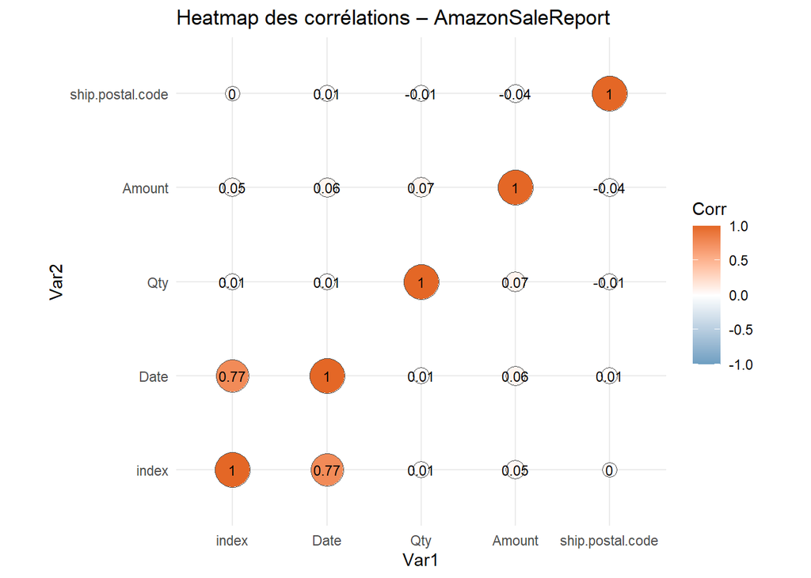

```r
plot_cor_heatmap(amazon_cor, title = "Heatmap des corrélations – AmazonSaleReport")
```

```r
############################################################

# Cloud_clean : Coûts logistiques

cloud_cor <- compute_cor_mat(Cloud_clean)

knitr::kable(cloud_cor, caption = "Corrélations – Cloud_clean")
```

Corrélations – Cloud_clean

|  | Shiprocket_Price | INCREFF_Price |
| --- | --- | --- |
| Shiprocket_Price | 1.0000000 | -0.6555676 |
| INCREFF_Price | -0.6555676 | 1.0000000 |

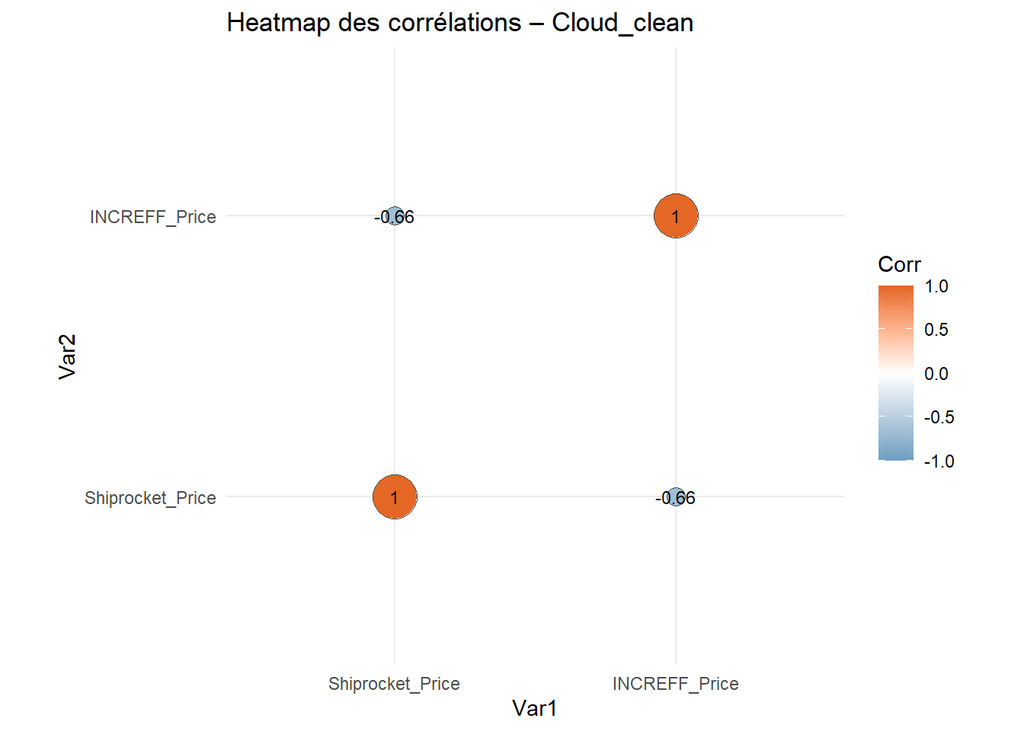

```r
plot_cor_heatmap(cloud_cor, title = "Heatmap des corrélations – Cloud_clean")
```

```r
############################################################

# ExpenseIIGF_clean_final : Dépenses internes

expense_cor <- compute_cor_mat(ExpenseIIGF_clean_final)

knitr::kable(expense_cor, caption = "Corrélations – ExpenseIIGF_clean_final")
```

Corrélations – ExpenseIIGF_clean_final

|  | Date | Amount_Received | Expense_Amount |
| --- | --- | --- | --- |
| Date | 1.0000000 | 0.2828427 | 0.6170268 |
| Amount_Received | 0.2828427 | 1.0000000 | 0.9216469 |
| Expense_Amount | 0.6170268 | 0.9216469 | 1.0000000 |

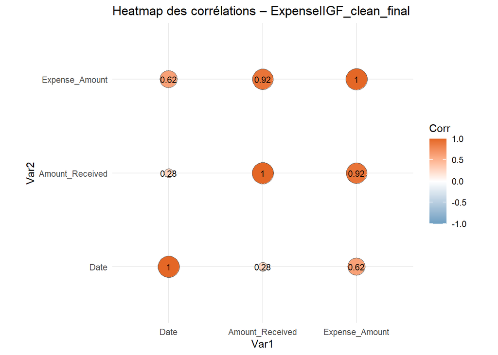

```r
plot_cor_heatmap(expense_cor, title = "Heatmap des corrélations – ExpenseIIGF_clean_final")
```

```r
############################################################

# InternationalsaleReport_coherent : Ventes internationales

intl_cor <- compute_cor_mat(InternationalsaleReport_coherent)

knitr::kable(intl_cor, caption = "Corrélations – InternationalsaleReport_coherent")
```

Corrélations – InternationalsaleReport_coherent

|  | index | PCS | RATE | GROSS.AMT | Expected_GROSS | Ecart |
| --- | --- | --- | --- | --- | --- | --- |
| index | 1.0000000 | -0.0012369 | 0.0561922 | 0.0203009 | 0.0203048 | -0.0085310 |
| PCS | -0.0012369 | 1.0000000 | -0.0888819 | 0.5819505 | 0.5819526 | 0.0120515 |
| RATE | 0.0561922 | -0.0888819 | 1.0000000 | 0.6790481 | 0.6790429 | 0.0316670 |
| GROSS.AMT | 0.0203009 | 0.5819505 | 0.6790481 | 1.0000000 | 0.9999999 | 0.0290304 |
| Expected_GROSS | 0.0203048 | 0.5819526 | 0.6790429 | 0.9999999 | 1.0000000 | 0.0285996 |
| Ecart | -0.0085310 | 0.0120515 | 0.0316670 | 0.0290304 | 0.0285996 | 1.0000000 |

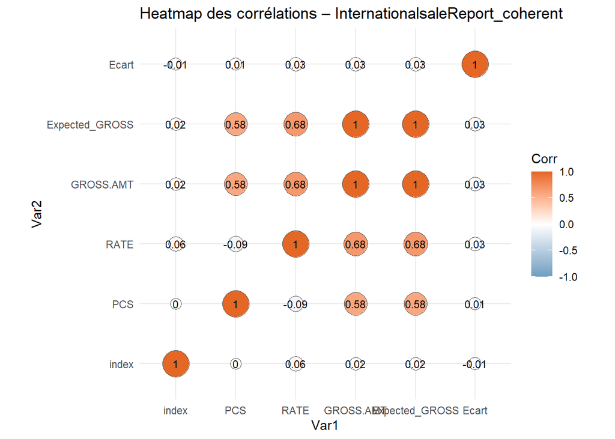

```r
plot_cor_heatmap(intl_cor, title = "Heatmap des corrélations – InternationalsaleReport_coherent")
```

```r
############################################################

# May_2022_normalise : Catalogue (May 2022)

may_cor <- compute_cor_mat(May_2022_normalise)

knitr::kable(may_cor, caption = "Corrélations – May_2022_normalise")
```

Corrélations – May_2022_normalise

|  | index | Weight | TP | MRP.Old | Final.MRP.Old | Ajio.MRP | Amazon.MRP | Amazon.FBA.MRP | Flipkart.MRP | Limeroad.MRP | Myntra.MRP | Paytm.MRP | Snapdeal.MRP |
| --- | --- | --- | --- | --- | --- | --- | --- | --- | --- | --- | --- | --- | --- |
| index | 1.0000000 | 0.2431275 | 0.2418873 | 0.3017191 | 0.2506962 | 0.2512059 | 0.2550228 | 0.2550228 | 0.2571808 | 0.2442957 | 0.2456655 | 0.2474941 | 0.2456327 |
| Weight | 0.2431275 | 1.0000000 | 0.6477674 | 0.5651724 | 0.5528458 | 0.5564730 | 0.5439043 | 0.5439043 | 0.5472163 | 0.5509845 | 0.5485802 | 0.5531676 | 0.5519483 |
| TP | 0.2418873 | 0.6477674 | 1.0000000 | 0.7167651 | 0.7092560 | 0.7076486 | 0.7006754 | 0.7006754 | 0.7048158 | 0.7079951 | 0.7152788 | 0.7087927 | 0.7086872 |
| MRP.Old | 0.3017191 | 0.5651724 | 0.7167651 | 1.0000000 | 0.9939594 | 0.9954961 | 0.9903099 | 0.9903099 | 0.9942640 | 0.9960804 | 0.9933958 | 0.9962725 | 0.9958391 |
| Final.MRP.Old | 0.2506962 | 0.5528458 | 0.7092560 | 0.9939594 | 1.0000000 | 0.9969935 | 0.9915293 | 0.9915293 | 0.9956696 | 0.9972746 | 0.9957371 | 0.9974661 | 0.9974754 |
| Ajio.MRP | 0.2512059 | 0.5564730 | 0.7076486 | 0.9954961 | 0.9969935 | 1.0000000 | 0.9930089 | 0.9930089 | 0.9968789 | 0.9984139 | 0.9970892 | 0.9986511 | 0.9986441 |
| Amazon.MRP | 0.2550228 | 0.5439043 | 0.7006754 | 0.9903099 | 0.9915293 | 0.9930089 | 1.0000000 | 1.0000000 | 0.9952246 | 0.9927763 | 0.9918642 | 0.9931008 | 0.9930806 |
| Amazon.FBA.MRP | 0.2550228 | 0.5439043 | 0.7006754 | 0.9903099 | 0.9915293 | 0.9930089 | 1.0000000 | 1.0000000 | 0.9952246 | 0.9927763 | 0.9918642 | 0.9931008 | 0.9930806 |
| Flipkart.MRP | 0.2571808 | 0.5472163 | 0.7048158 | 0.9942640 | 0.9956696 | 0.9968789 | 0.9952246 | 0.9952246 | 1.0000000 | 0.9970458 | 0.9960747 | 0.9972973 | 0.9972871 |
| Limeroad.MRP | 0.2442957 | 0.5509845 | 0.7079951 | 0.9960804 | 0.9972746 | 0.9984139 | 0.9927763 | 0.9927763 | 0.9970458 | 1.0000000 | 0.9972176 | 0.9993323 | 0.9996689 |
| Myntra.MRP | 0.2456655 | 0.5485802 | 0.7152788 | 0.9933958 | 0.9957371 | 0.9970892 | 0.9918642 | 0.9918642 | 0.9960747 | 0.9972176 | 1.0000000 | 0.9974049 | 0.9974341 |
| Paytm.MRP | 0.2474941 | 0.5531676 | 0.7087927 | 0.9962725 | 0.9974661 | 0.9986511 | 0.9931008 | 0.9931008 | 0.9972973 | 0.9993323 | 0.9974049 | 1.0000000 | 0.9991244 |
| Snapdeal.MRP | 0.2456327 | 0.5519483 | 0.7086872 | 0.9958391 | 0.9974754 | 0.9986441 | 0.9930806 | 0.9930806 | 0.9972871 | 0.9996689 | 0.9974341 | 0.9991244 | 1.0000000 |

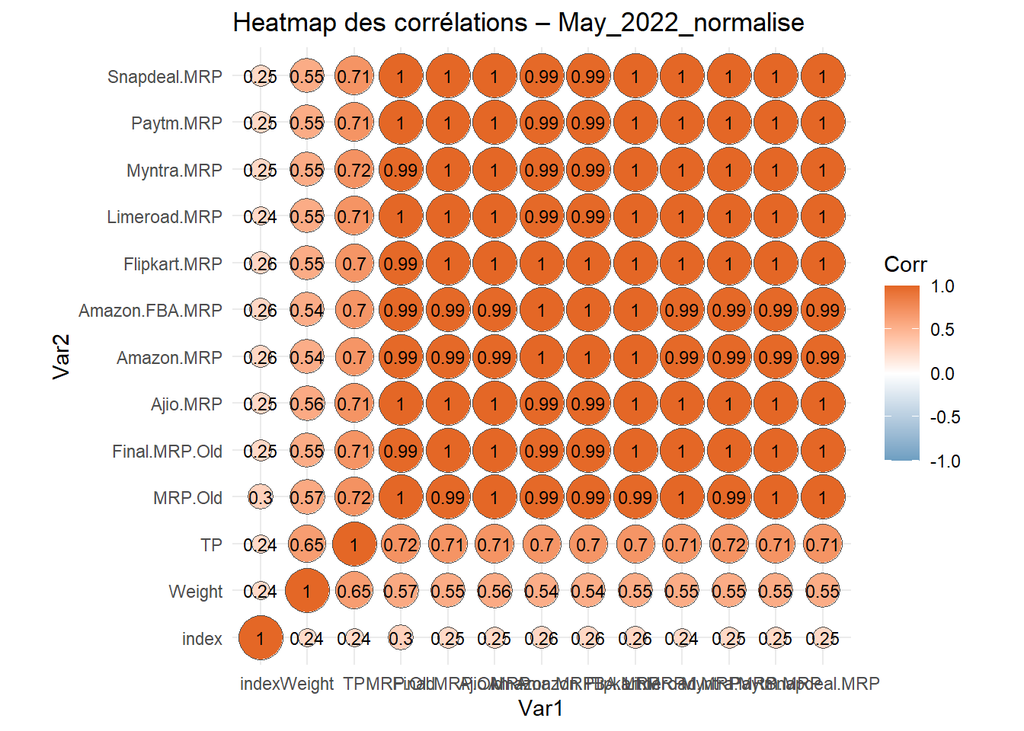

```r
plot_cor_heatmap(may_cor, title = "Heatmap des corrélations – May_2022_normalise")
```

```r
############################################################

# PLMarch2021_normalise : catalogue PLM (mars 2021)

plm_cor <- compute_cor_mat(PLMarch2021_normalise)

knitr::kable(plm_cor, caption = "Corrélations – PLMarch2021_normalise")
```

Corrélations – PLMarch2021_normalise

|  | index | Weight | TP.1 | TP.2 | MRP.Old | Final.MRP.Old | Ajio.MRP | Amazon.MRP | Amazon.FBA.MRP | Flipkart.MRP | Limeroad.MRP | Myntra.MRP | Paytm.MRP | Snapdeal.MRP |
| --- | --- | --- | --- | --- | --- | --- | --- | --- | --- | --- | --- | --- | --- | --- |
| index | 1.0000000 | 0.2431275 | 0.2418873 | 0.2418873 | 0.3017191 | 0.2506962 | 0.2512059 | 0.2550228 | 0.2550228 | 0.2571808 | 0.2442957 | 0.2456655 | 0.2474941 | 0.2456327 |
| Weight | 0.2431275 | 1.0000000 | 0.6477674 | 0.6477674 | 0.5651724 | 0.5528458 | 0.5564730 | 0.5439043 | 0.5439043 | 0.5472163 | 0.5509845 | 0.5485802 | 0.5531676 | 0.5519483 |
| TP.1 | 0.2418873 | 0.6477674 | 1.0000000 | 1.0000000 | 0.7167651 | 0.7092560 | 0.7076486 | 0.7006754 | 0.7006754 | 0.7048158 | 0.7079951 | 0.7152788 | 0.7087927 | 0.7086872 |
| TP.2 | 0.2418873 | 0.6477674 | 1.0000000 | 1.0000000 | 0.7167651 | 0.7092561 | 0.7076487 | 0.7006754 | 0.7006754 | 0.7048158 | 0.7079952 | 0.7152789 | 0.7087928 | 0.7086873 |
| MRP.Old | 0.3017191 | 0.5651724 | 0.7167651 | 0.7167651 | 1.0000000 | 0.9939594 | 0.9954961 | 0.9903099 | 0.9903099 | 0.9942640 | 0.9960804 | 0.9933958 | 0.9962725 | 0.9958391 |
| Final.MRP.Old | 0.2506962 | 0.5528458 | 0.7092560 | 0.7092561 | 0.9939594 | 1.0000000 | 0.9969935 | 0.9915293 | 0.9915293 | 0.9956696 | 0.9972746 | 0.9957371 | 0.9974661 | 0.9974754 |
| Ajio.MRP | 0.2512059 | 0.5564730 | 0.7076486 | 0.7076487 | 0.9954961 | 0.9969935 | 1.0000000 | 0.9930089 | 0.9930089 | 0.9968789 | 0.9984139 | 0.9970892 | 0.9986511 | 0.9986441 |
| Amazon.MRP | 0.2550228 | 0.5439043 | 0.7006754 | 0.7006754 | 0.9903099 | 0.9915293 | 0.9930089 | 1.0000000 | 1.0000000 | 0.9952246 | 0.9927763 | 0.9918642 | 0.9931008 | 0.9930806 |
| Amazon.FBA.MRP | 0.2550228 | 0.5439043 | 0.7006754 | 0.7006754 | 0.9903099 | 0.9915293 | 0.9930089 | 1.0000000 | 1.0000000 | 0.9952246 | 0.9927763 | 0.9918642 | 0.9931008 | 0.9930806 |
| Flipkart.MRP | 0.2571808 | 0.5472163 | 0.7048158 | 0.7048158 | 0.9942640 | 0.9956696 | 0.9968789 | 0.9952246 | 0.9952246 | 1.0000000 | 0.9970458 | 0.9960747 | 0.9972973 | 0.9972871 |
| Limeroad.MRP | 0.2442957 | 0.5509845 | 0.7079951 | 0.7079952 | 0.9960804 | 0.9972746 | 0.9984139 | 0.9927763 | 0.9927763 | 0.9970458 | 1.0000000 | 0.9972176 | 0.9993323 | 0.9996689 |
| Myntra.MRP | 0.2456655 | 0.5485802 | 0.7152788 | 0.7152789 | 0.9933958 | 0.9957371 | 0.9970892 | 0.9918642 | 0.9918642 | 0.9960747 | 0.9972176 | 1.0000000 | 0.9974049 | 0.9974341 |
| Paytm.MRP | 0.2474941 | 0.5531676 | 0.7087927 | 0.7087928 | 0.9962725 | 0.9974661 | 0.9986511 | 0.9931008 | 0.9931008 | 0.9972973 | 0.9993323 | 0.9974049 | 1.0000000 | 0.9991244 |
| Snapdeal.MRP | 0.2456327 | 0.5519483 | 0.7086872 | 0.7086873 | 0.9958391 | 0.9974754 | 0.9986441 | 0.9930806 | 0.9930806 | 0.9972871 | 0.9996689 | 0.9974341 | 0.9991244 | 1.0000000 |

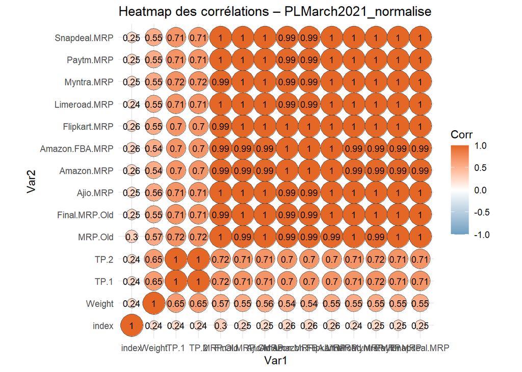

```r
plot_cor_heatmap(plm_cor, title = "Heatmap des corrélations – PLMarch2021_normalise")
```

```r
############################################################

# SaleReport_clean : Stocks

sale_cor <- compute_cor_mat(SaleReport_clean)

knitr::kable(sale_cor, caption = "Corrélations – SaleReport_clean")
```

Corrélations – SaleReport_clean

|  | index | Stock |
| --- | --- | --- |
| index | 1.0000000 | 0.0577374 |
| Stock | 0.0577374 | 1.0000000 |

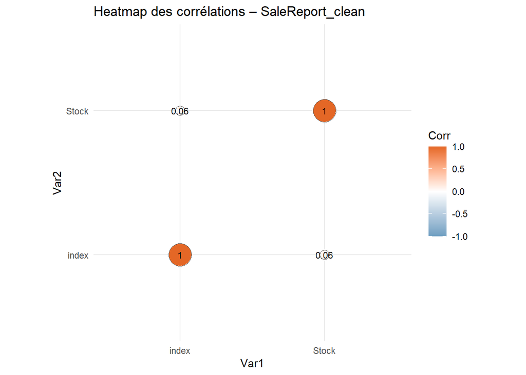

```r
plot_cor_heatmap(sale_cor, title = "Heatmap des corrélations – SaleReport_clean")
```

**1. Corrélations – AmazonSaleReport**

**Observations générales**

Les corrélations sont très faibles, proches de 0 dans la majorité des cas.

La seule corrélation notable est entre index et Date (≈ 0.77), ce qui s’explique par le fait que l’index représente probablement l’ordre chronologique du fichier.

**Relations significatives**

index ↔︎ Date : r ≈ 0.77 → Relation logique : l’index augmente avec le temps.

**Absence de relations structurelles**

Amount, Qty et ship.postal.code n’ont aucune corrélation significative entre eux.

Qty ↔︎ Amount : r ≈ 0.067 → très faible. → Cela signifie que le montant total n’est pas déterminé directement par la quantité dans ce dataset (rabais, prix unitaires variables…).

**Conclusion**

Les ventes Amazon n’expriment aucune structure linéaire forte entre les variables clés. Les montants et quantités semblent être influencés par des facteurs externes (catégorie produit, prix dynamiques…).

**2. Corrélations – Cloud_clean**

(Coûts logistiques : Shiprocket vs Increff)

**Observations générales**

Structure très simple : seulement deux variables.

**Relation clé**

Shiprocket_Price ↔︎ INCREFF_Price : r ≈ –0.656 → Corrélation négative modérée à forte.

**Interprétation**

Lorsque les prix Shiprocket augmentent, les prix Increff ont tendance à diminuer, et inversement.

Cela suggère :

- soit deux modèles tarifaires opposés,
- soit une optimisation automatique (ex : un fournisseur facture moins quand l’autre facture plus).

**Conclusion**

Les deux systèmes de tarification logistique ne varient pas ensemble : ils semblent être des alternatives, pas des services complémentaires.

**3. Corrélations – ExpenseIIGF_clean_final**

(Dépenses et montants reçus)

**Relations clés**

- Amount_Received ↔︎ Expense_Amt : r ≈ 0.92 → Corrélation forte et positive.
- Date ↔︎ Expense_Amt : r ≈ 0.62 → Corrélation modérée.
- Date ↔︎ Amount_Received : r ≈ 0.28 → Faible.

**Interprétation**

Le montant reçu et le montant dépensé sont quasi linéairement liés. → Probablement un système de remboursement / financement interne : plus on dépense, plus on reçoit de fonds correspondants.

La relation avec la date montre une tendance temporelle : les dépenses augmentent dans le temps.

**Conclusion**

Ce dataset présente une structure financière claire, idéale pour analyses budgétaires ou prévisions.

**4. Corrélations – InternationalsaleReport_coherent**

**Relations très fortes**

- GROSS.AMT ↔︎ Expected_GROSS : r ≈ 1.00
- RATE ↔︎ GROSS.AMT : r ≈ 0.68
- PCS ↔︎ GROSS.AMT : r ≈ 0.58

→ Parfaitement cohérent : GROSS.AMT = PCS × RATE, donc Expected_GROSS étant recalculé, tout est parfaitement aligné.

**Variables indépendantes**

Ecart (erreur) ne corrèle pratiquement avec aucune variable. → Normal : après nettoyage, les écarts sont très faibles.

**Conclusion**

Les données cohérentes internationales sont mathématiquement parfaites : les montants, quantités et prix unitaires respectent les relations économiques attendues.

**5. Corrélations – May_2022_normalise**

(Catalogues produits : prix multi-plateformes)

**Observations générales**

Toutes les plateformes e-commerce (Amazon, Ajio, Myntra, Flipkart…) présentent des corrélations entre 0.98 et 1.00.

Le prix “MRP.Old” corrèle aussi quasi parfaitement avec toutes les autres MRPs.

**Interprétation**

Tous les prix sont extrêmement cohérents entre plateformes.

Cela indique que le fichier :

- correspond probablement à un catalogue officiel,
- où les prix sont synchronisés entre marketplaces.

Corrélation modérée :

- Weight ↔︎ Price : r ≈ 0.55–0.65 → les produits plus lourds ont tendance à être plus chers (logique économique).

**Conclusion**

Ce dataset est très structuré, parfait pour des analyses de :

- positionnement prix,
- comparaison inter-plateformes,
- optimisation tarifaire.

**6.Corrélations – PLMarch2021_normalise**

**Observation générale**

Globalement, la matrice révèle une structure tarifaire extrêmement homogène au sein du catalogue PL de mars 2021.

**Relations significatives**

- MRP.Old ↔︎ Final.MRP.Old ↔︎ Ajio.MRP ↔︎ Amazon.MRP ↔︎ Flipkart.MRP… : r ≈ 0.99 – 1.00 → Tarifs identiques ou quasi identiques entre plateformes.
- TP.1 / TP.2 ↔︎ MRP.Old & Final.MRP.Old : r ≈ 0.70 – 0.72 → Structure logique entre prix d’achat (TP) et prix publics (MRP).
- Weight ↔︎ MRP variables : r ≈ 0.54 – 0.57 → Les articles plus lourds sont légèrement associés à des prix plus élevés.

**Points d’attention / Absence de relations**

- index montre une faible corrélation avec toutes les variables (r ≈ 0.24). → Confirme l’absence d’ordre tarifaire lié à l’index (variable purement technique).
- La force très élevée des corrélations pourrait indiquer :

  ```
  - des prix strictement synchronisés (politique commerciale uniforme),

  - ou un catalogue relativement homogène, laissant peu de variabilité.
  ```

Aucune relation négative n’est observée, ce qui confirme une cohérence très forte.

**Conclusion**

La matrice montre que l’ensemble du catalogue PL March 2021 est parfaitement aligné en termes de tarification, indépendamment des plateformes de vente. Cela reflète :

- une politique de prix centralisée,
- une cohérence tarifaire inter-canal,
- un processus de catalogage maîtrisé.

Ce dataset est donc extrêmement stable, idéal pour analyses de positionnement prix, benchmarking marketplace, ou calculs d’élasticité.

**7. Corrélations – SaleReport_clean (Stock interne)**

**Observation générale de la matrice**

La matrice ne contient que deux variables corrélées : index et Stock. La corrélation est faible et positive (r ≈ 0.06), ce qui montre une absence de relation linéaire entre les deux.

**Relations significatives**

Aucune relation significative n’apparaît. La corrélation de 0.06 est trop faible pour indiquer un effet réel.

**Points d’attention / Absence de relations**

- index étant une variable technique, il est normal qu’il ne porte aucune information explicative.
- Stock ne dépend pas de l’ordre d’apparition des lignes → le fichier semble bien structuré.
- L’absence de relation confirme que l’inventaire n’a pas été saisi de manière séquentielle selon un critère numérique ou temporel.

**Conclusion**

Le dataset SaleReport_clean ne présente aucune corrélation exploitable, ce qui est normal pour un fichier d’inventaire.

Les stocks ne suivent aucune logique linéaire explicite et sont indépendants de l’index d’enregistrement. Cela confirme un dataset simple, propre, sans anomalies structurelles et prêt pour analyses de stock, rotation ou ruptures.

```
       3 - VISUALISATIONS : HISTOGRAMMES & DISTRIBUTIONS
```

Les histogrammes et les analyses de distributions constituent une étape essentielle de l’EDA, car ils permettent de comprendre la forme, la dispersion et les comportements globaux des variables quantitatives. En observant la répartition des valeurs (symétrie, asymétrie, présence de pics, queues longues ou anomalies), on identifie rapidement les phénomènes naturels, les tendances cachées, ainsi que les valeurs extrêmes susceptibles d’influencer les résultats.

Cette étape est particulièrement utile pour détecter d’éventuelles erreurs de saisie, des patterns saisonniers, ou encore des structures de prix ou de volumes propres aux produits et aux marchés étudiés. Les histogrammes servent ainsi de base solide pour orienter les analyses plus avancées et guider les décisions ultérieures.

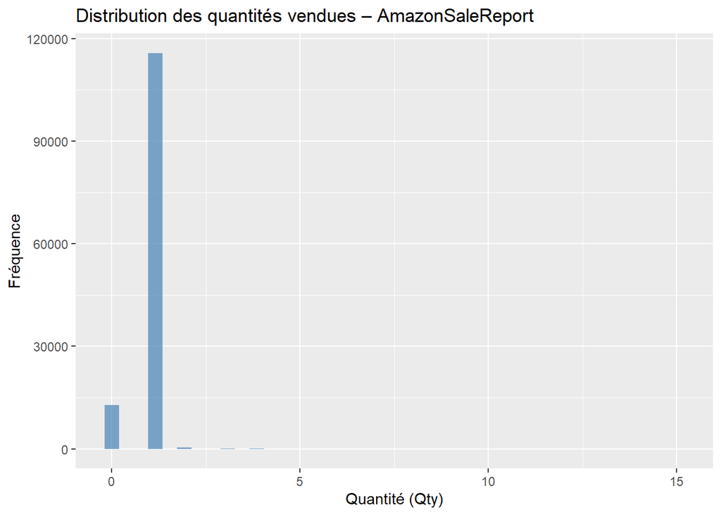

```r
# AmazonSaleReport : Ventes

# Histogrammes des quantités & montants

AmazonSaleReport %>%
  ggplot(aes(x = Qty)) +
  geom_histogram(bins = 40, fill = "steelblue", alpha = 0.7) +
  labs(title = "Distribution des quantités vendues – AmazonSaleReport",
       x = "Quantité (Qty)", y = "Fréquence")
```

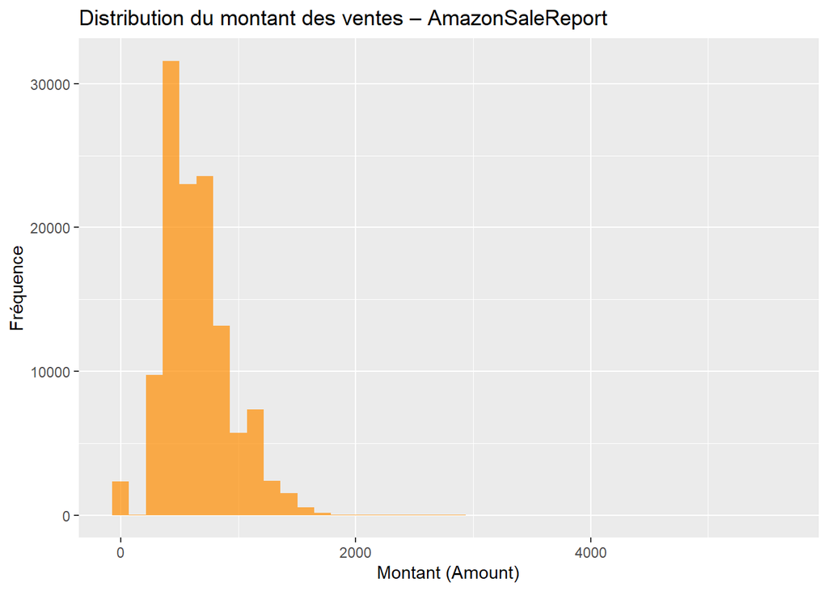

```r
AmazonSaleReport %>%
  ggplot(aes(x = Amount)) +
  geom_histogram(bins = 40, fill = "darkorange", alpha = 0.7) +
  labs(title = "Distribution du montant des ventes – AmazonSaleReport",
       x = "Montant (Amount)", y = "Fréquence")
```

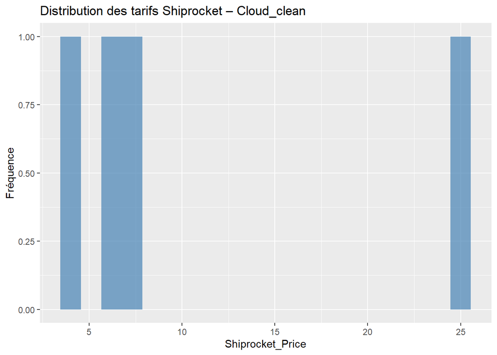

```r
############################################################

# Cloud_clean : Coûts logistiques

Cloud_clean %>%
  ggplot(aes(x = Shiprocket_Price)) +
  geom_histogram(bins = 20, fill = "steelblue", alpha = 0.7) +
  labs(title = "Distribution des tarifs Shiprocket – Cloud_clean",
       x = "Shiprocket_Price", y = "Fréquence")
```

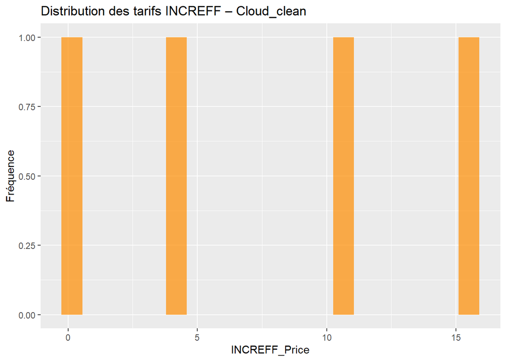

```r
Cloud_clean %>%
  ggplot(aes(x = INCREFF_Price)) +
  geom_histogram(bins = 20, fill = "darkorange", alpha = 0.7) +
  labs(title = "Distribution des tarifs INCREFF – Cloud_clean",
       x = "INCREFF_Price", y = "Fréquence")
```

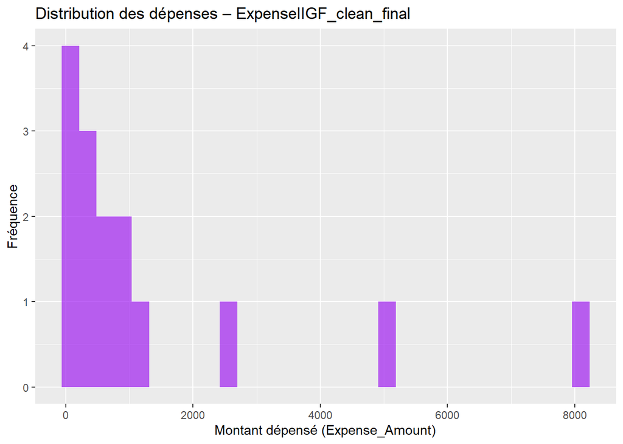

```r
############################################################

# ExpenseIIGF_clean_final : Dépenses internes

ExpenseIIGF_clean_final %>%
  ggplot(aes(x = Expense_Amount)) +
  geom_histogram(bins = 30, fill = "purple", alpha = 0.7) +
  labs(title = "Distribution des dépenses – ExpenseIIGF_clean_final",
       x = "Montant dépensé (Expense_Amount)", y = "Fréquence")
```

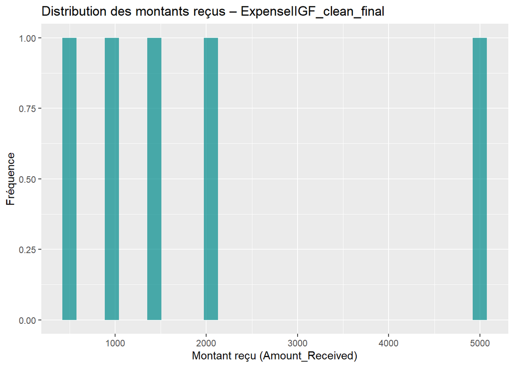

```r
ExpenseIIGF_clean_final %>%
  ggplot(aes(x = Amount_Received)) +
  geom_histogram(bins = 30, fill = "darkcyan", alpha = 0.7) +
  labs(title = "Distribution des montants reçus – ExpenseIIGF_clean_final",
       x = "Montant reçu (Amount_Received)", y = "Fréquence")
```

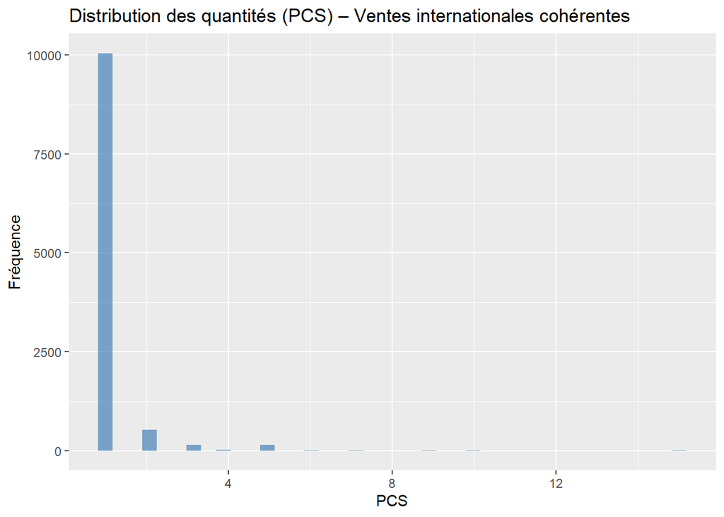

```r
############################################################

# InternationalsaleReport_coherent : Ventes internationales

# Histogrammes PCS, RATE, GROSS.AMT & Ecart

InternationalsaleReport_coherent %>%
  ggplot(aes(x = PCS)) +
  geom_histogram(bins = 40, fill = "steelblue", alpha = 0.7) +
  labs(title = "Distribution des quantités (PCS) – Ventes internationales cohérentes",
       x = "PCS", y = "Fréquence")
```

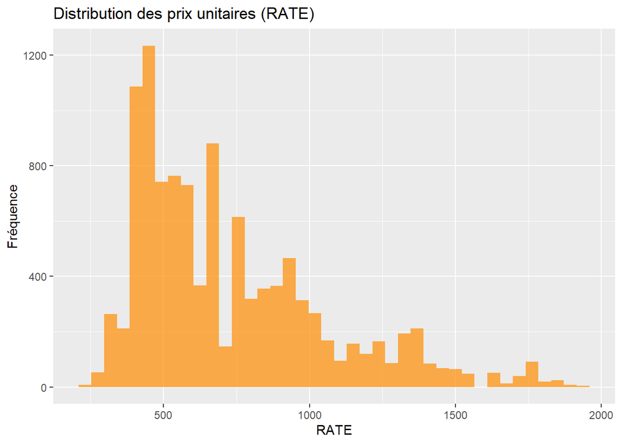

```r
InternationalsaleReport_coherent %>%
  ggplot(aes(x = RATE)) +
  geom_histogram(bins = 40, fill = "darkorange", alpha = 0.7) +
  labs(title = "Distribution des prix unitaires (RATE)",
       x = "RATE", y = "Fréquence")
```

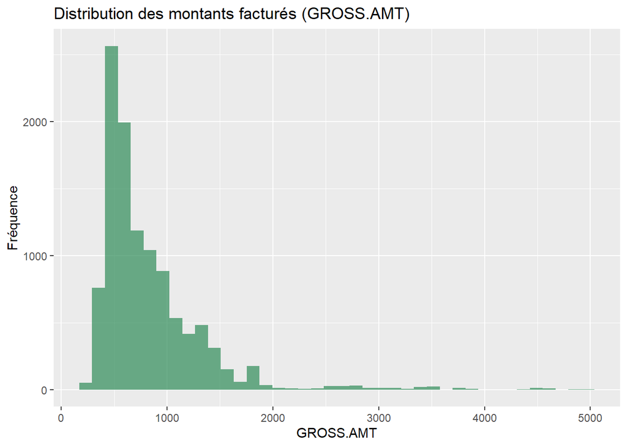

```r
InternationalsaleReport_coherent %>%
  ggplot(aes(x = GROSS.AMT)) +
  geom_histogram(bins = 40, fill = "seagreen", alpha = 0.7) +
  labs(title = "Distribution des montants facturés (GROSS.AMT)",
       x = "GROSS.AMT", y = "Fréquence")
```

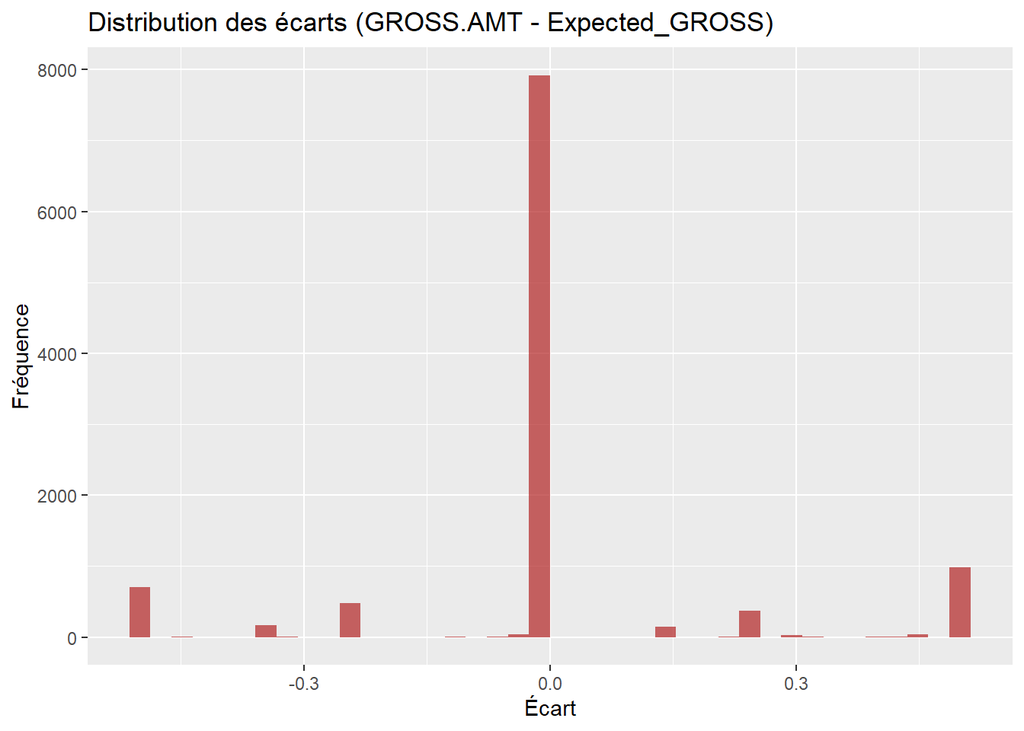

```r
InternationalsaleReport_coherent %>%
  ggplot(aes(x = Ecart)) +
  geom_histogram(bins = 40, fill = "firebrick", alpha = 0.7) +
  labs(title = "Distribution des écarts (GROSS.AMT - Expected_GROSS)",
       x = "Écart", y = "Fréquence")
```

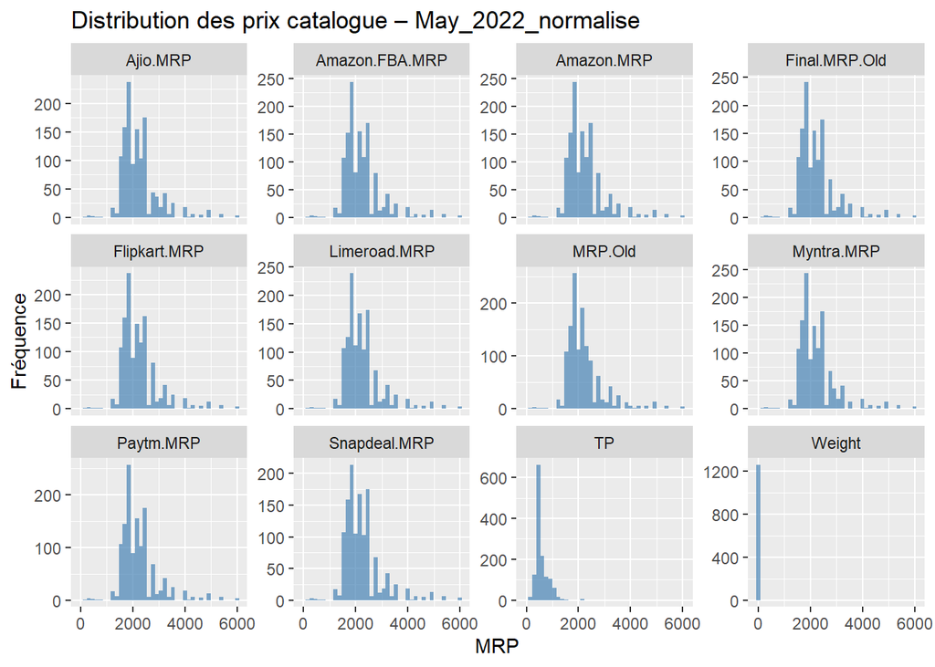

```r
############################################################

# May_2022_normalise : Catalogue (May 2022)

may_long <- May_2022_normalise %>%
  select(index, Weight, TP, MRP.Old, Final.MRP.Old,
         Ajio.MRP, Amazon.MRP, Amazon.FBA.MRP,
         Flipkart.MRP, Limeroad.MRP, Myntra.MRP,
         Paytm.MRP, Snapdeal.MRP) %>%
  pivot_longer(-index, names_to = "Canal", values_to = "MRP")

may_long %>%
  ggplot(aes(x = MRP)) +
  geom_histogram(bins = 40, fill = "steelblue", alpha = 0.7) +
  facet_wrap(~ Canal, scales = "free_y") +
  labs(title = "Distribution des prix catalogue – May_2022_normalise",
       x = "MRP", y = "Fréquence")
```

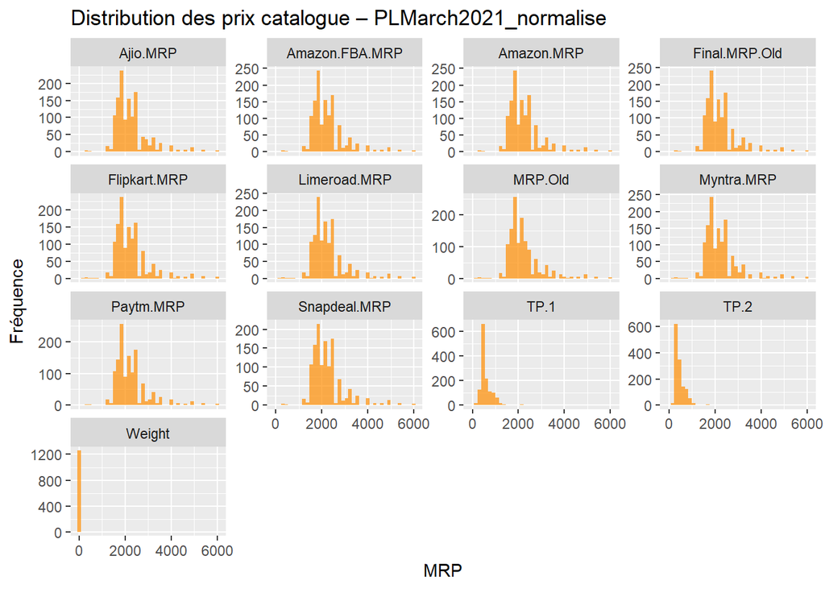

```r
############################################################

# PLMarch2021_normalise : catalogue PLM (mars 2021)

plm_long <- PLMarch2021_normalise %>%
  select(index, Weight, TP.1, TP.2, MRP.Old, Final.MRP.Old,
         Ajio.MRP, Amazon.MRP, Amazon.FBA.MRP,
         Flipkart.MRP, Limeroad.MRP, Myntra.MRP,
         Paytm.MRP, Snapdeal.MRP) %>%
  pivot_longer(-index, names_to = "Canal", values_to = "MRP")

plm_long %>%
  ggplot(aes(x = MRP)) +
  geom_histogram(bins = 40, fill = "darkorange", alpha = 0.7) +
  facet_wrap(~ Canal, scales = "free_y") +
  labs(title = "Distribution des prix catalogue – PLMarch2021_normalise",
       x = "MRP", y = "Fréquence")
```

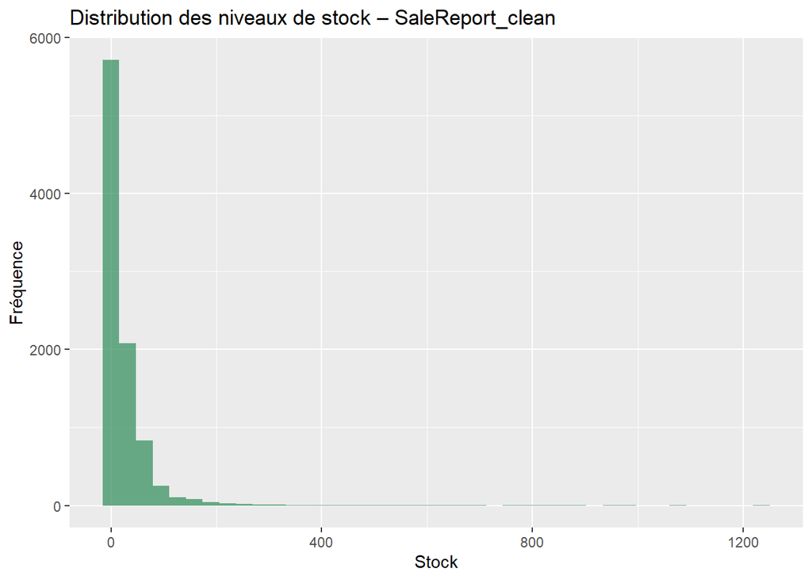

```r
############################################################

# SaleReport_clean : Stocks

SaleReport_clean %>%
  ggplot(aes(x = Stock)) +
  geom_histogram(bins = 40, fill = "seagreen", alpha = 0.7) +
  labs(title = "Distribution des niveaux de stock – SaleReport_clean",
       x = "Stock", y = "Fréquence")
```

**Interprétations des histogrammes (distributions)**

**1. AmazonSaleReport – Distribution des quantités vendues (Qty)**

**Observation générale**

La distribution des quantités vendues est extrêmement asymétrique :

- L’immense majorité des lignes correspond à des ventes de 1 unité,
- Quelques ventes à 2, 3, 4 ou 5 unités existent mais sont très rares,
- Des valeurs encore plus élevées (jusqu’à 10–15 unités) apparaissent comme des cas isolés.

La structure générale est donc celle d’un commerce B2C classique, où les achats unitaires sont prédominants.

**Relations significatives**

- Le pic massif à Qty = 1 confirme que le volume des ventes est porté par des transactions individuelles, non par des commandes en lot.
- Cette distribution explique la faible corrélation entre Qty et Amount observée dans la matrice : ️- Amount dépend surtout du prix du produit, ️- PCS (quantité) varie très peu → pas assez de dispersion pour créer une relation forte.
- Les rares valeurs élevées (5–15 unités) peuvent être associées à :
  - des packs,
  - des retours inversés comptabilisés différemment,
  - ou des commandes groupées.

**Points d’attention**

- Quelques valeurs hors norme (ex. Qty > 10) doivent être validées : ️- vraie commande multiple ? ️- duplication ? ️- erreur de saisie ?
- Cette distribution très concentrée peut fausser certaines analyses :
  - modèles de régression,
  - corrélations,
  - clustering. Une transformation ou une segmentation peut être utile.

**Conclusion analytique**

La distribution Qty confirme une activité hautement concentrée sur des ventes unitaires, caractéristique d’un marché e-commerce.

Les valeurs extrêmes sont marginales, mais doivent être surveillées. Globalement, la variable Qty est cohérente, stable et reflète fidèlement la réalité du comportement client Amazon.

**2. AmazonSaleReport – Distribution du montant des ventes (Amount)**

**Observation générale**

La distribution du montant des ventes est nettement asymétrique :

- Une forte concentration autour des prix entre 400 et 1 200 INR,
- Une diminution progressive jusqu’à environ 2 000+ INR,
- Une longue queue droite indiquant quelques montants très élevés.

Cette forme est typique du e-commerce : les prix des produits sont concentrés dans une gamme centrale, avec quelques articles premium.

**Relations significatives**

Le profil de Amount reflète directement celui des prix produits :

️- les valeurs élevées (> 2 000 INR) représentent des produits premium ou à plus forte valeur ajoutée.

La large dispersion des prix explique :

- la diversité des performances par SKU,
- les marges variables selon les catégories,
- une segmentation naturelle entre produits classiques et produits haut-de-gamme.

Amount montre une corrélation faible avec Qty mais cohérente avec le fait que Qty varie très peu.

**Points d’attention**

Quelques valeurs très basses peuvent provenir de :

️- articles remisés fortement,

️- ventes de tests ou d’échantillons,

️- erreurs ou anomalies (ex. Amount = 0 → vérifier).

Les valeurs très hautes (> 3 000 INR) doivent aussi être confirmées :

️- produits premium ?

️- lots vendus ensemble ?

️- mauvaise assignation de SKU ?

**Conclusion analytique**

La distribution Amount est cohérente et reflète parfaitement le comportement d’un portefeuille Amazon :

un noyau fort de produits milieu de gamme, une queue premium bien distincte, et quelques anomalies ponctuelles.

Elle constitue une base solide pour les analyses de performances, pricing et marges.

**3. Cloud_clean – Shiprocket_Price**

**Observation générale**

- La distribution a deux groupes distincts : - un groupe autour de 4–7 - et un autre autour de 25–26.

**Tendances significatives**

- Deux niveaux de tarification → probablement deux zones, deux méthodes de livraison, ou deux tranches de poids.

**Points d’attention**

- Rupture nette entre les deux niveaux → segmentation tarifaire non continue.
- Vérifier si les poids, zones ou transporteurs expliquent ces niveaux.

**Conclusion**

Les tarifs Shiprocket montrent une structure tarifaire claire en paliers, possiblement liée aux catégories logistiques.

**4. Cloud_clean – INCREFF_Price**

**Observation générale**

- Même phénomène que Shiprocket mais en quatre blocs distincts.

**Tendances significatives**

- Prix standardisés → grilles tarifaires fixes.
- Peut correspondre à des tranches de poids précises.

**Points d’attention**

- Forte discontinuité → impacts possibles sur la marge logistique selon le poids exact.

**Conclusion**

INCREFF applique une tarification stricte par paliers, ce qui confirme l’importance d’optimiser le poids des colis.

**5. ExpenseIIGF_clean_final – Dépenses (Expense_Aamount)**

**Observation générale**

- Distribution très dispersée, de quelques centaines à plus de 8000 unités.

**Tendances significatives**

- La majorité des dépenses se situe entre 200 et 1200.
- Quelques dépenses très élevées = opérations exceptionnelles.

**Points d’attention**

- Plusieurs points extrêmes → dépenses irrégulières à analyser individuellement.

**Conclusion**

Les dépenses opérationnelles sont habituellement faibles mais ponctuellement très élevées, possiblement dues à des investissements ponctuels ou opérations exceptionnelles.

**6. ExpenseIIGF_clean_final – Montants reçus (Amount_Received)**

**Observation générale**

- Distribution en valeurs uniques espacées → peu de transactions, mais structurées.

**Tendances significatives**

- Plusieurs montants fixes → remboursements standardisés ou paiements contractuels.

**Points d’attention**

La distribution n’est pas continue → analyser la logique métier des montants standard.

**Conclusion**

Les montants reçus semblent dépendre de paliers prédéfinis, possiblement liés aux types de remboursements.

**7. InternationalSaleReport_coherent — Distribution des quantités vendues (PCS)**

**Observation générale**

La distribution des quantités PCS montre une asymétrie extrêmement prononcée :

- La quasi-totalité des ventes se situe entre 1 et 2 unités,
- Une très faible proportion dépasse 3 unités,
- Les quantités élevées (5, 8, 10, jusqu’à 14 pièces) sont marginales et apparaissent comme des cas isolés.

Cette structure révèle un marché international dominé par les ventes unitaires, ce qui est typique des commandes e-commerce à l’étranger où les clients achètent rarement en volume.

**Relations significatives**

**Points d’attention**

- Les valeurs élevées, bien que rares, doivent être vérifiées : ️ - commandes en lot ? ️ - erreurs d’encodage (ex : 12 au lieu de 1.2) ?
  - produits vendus par packs mais comptés à l’unité ?
- La concentration sur PCS = 1 peut biaiser les analyses statistiques, notamment les corrélations.

**Conclusion analytique**

La distribution PCS est stable, cohérente et caractéristique d’un marché international B2C. Elle confirme que l’essentiel des expéditions porte sur des unités individuelles. Les valeurs extrêmes méritent une vérification, mais globalement la variable PCS reflète un comportement de vente normal pour ce type de marché.

**8. InternationalSaleReport_coherent — Distribution des prix unitaires (RATE)**

**Observation générale**

RATE présente une distribution typique d’un prix de produit e-commerce :

- Forte concentration entre 300 et 800 INR,
- Une diminution progressive jusqu’à environ 1 800 INR,
- Une queue longue indiquant la présence de produits premium. La distribution est donc asymétrique à droite, ce qui est classique pour des prix non normalisés.

**Relations significatives**

**Points d’attention**

- Quelques valeurs très basses ou très élevées peuvent résulter :
  - d’un produit soldé,
  - d’une erreur de saisie,
  - ou d’un produit hors gamme.
- Une transformation logarithmique pourrait permettre une meilleure lecture si nécessaire.

**Conclusion analytique**

La distribution de RATE révèle un portefeuille produit diversifié, composé majoritairement de produits milieu de gamme mais incluant des articles plus premium. La cohérence avec les catalogues renforce la qualité des données. L’analyse pourra servir pour des modèles de pricing, de marge ou de segmentation.

**9. InternationalSaleReport_coherent — Distribution des montants facturés (GROSS.AMT)**

**Observation générale**

GROSS.AMT montre une structure très claire :

- Une concentration principale entre 600 et 1 200 INR,
- Une dispersion significative jusqu’à 5 000+ INR,
- Une distribution asymétrique, avec une majorité de valeurs modérées et une minorité de montants élevés.

Ce profil correspond typiquement au comportement d’un montant facturé résultant de PRICE × QUANTITY, avec PCS majoritairement égal à 1.

**Relations significatives**

- La forme de la distribution reflète précisément celles de RATE et PCS : ️- PCS ≈ 1 → GROSS.AMT ≈ RATE ️- Quelques PCS > 1 → montants multipliés
- Les valeurs élevées (> 3 000 INR) sont fortement corrélées à des RATE premium ou des PCS > 1.
- GROSS.AMT présente une corrélation presque parfaite avec Expected_GROSS (≈ 1), ce qui montre la rigueur et la précision du calcul facturé.

**Points d’attention**

- La présence de montants très élevés peut indiquer des produits exceptionnels ou des commandes en lot.
- Comme pour RATE, une standardisation peut être utile dans une modélisation.

**Conclusion analytique**

La distribution de GROSS.AMT est cohérente, fiable et parfaitement alignée avec les autres variables. Elle décrit un portefeuille produit diversifié, où les montants facturés reflètent principalement les prix unitaires. Le système de facturation semble précis et bien contrôlé

**10. InternationalSaleReport_coherent — Distribution des écarts (GROSS.AMT – Expected_GROSS)**

**Observation générale**

L’écart entre GROSS.AMT et Expected_GROSS présente une distribution très particulière :

- Une immense majorité des valeurs se situent exactement à 0,
- Quelques écarts positifs ou négatifs se répartissent entre -0.5 et +0.5,
- La distribution est totalement centrée et extrêmement fine.

Cela montre que le système de calcul du montant attendu est très précis.

**Relations significatives**

- L’accumulation à 0 confirme une cohérence comptable quasi parfaite entre le montant prévu et le montant réellement facturé.
- Les écarts positifs ou négatifs semblent attribuables :
  - aux arrondis,
  - à la conversion de monnaie,
  - ou à des ajustements mineurs (taxes, frais additionnels).
- L’absence d’écarts structurels confirme des corrélations statistiques presque exactes (≈ 1).

**Points d’attention**

- Les écarts extrêmes (autour de ±0.5) sont rares mais doivent être confirmés : ️- Remises appliquées ? ️- Taxes spécifiques ? ️- Ajustements logistiques ?
- Une vérification peut être utile, mais rien n’indique une anomalie.

**Conclusion analytique**

La distribution des écarts est ultra stable, centrée, et reflète une excellente maîtrise du calcul des montants facturés. Ce comportement valide la qualité du dataset et la robustesse des processus de facturation internationaux.

**11. PLMarch2021_normalise — Distribution des prix catalogue**

**Observation générale**

Les différentes plateformes (Ajio, Amazon, Myntra, Flipkart, Snapdeal, etc.) présentent toutes une distribution très similaire :

- un pic principal entre 500 et 2 500 INR,
- une queue longue (long tail) montrant quelques produits très chers, parfois au-delà de 5 000–6 000 INR. Les variables TP.1, TP.2 et Weight confirment une forte concentration sur de petites valeurs, signe d’un marché dominé par des produits légers et bon marché.

**Relations significatives**

- La forme presque identique des distributions confirme ce que montrait la matrice de corrélation : tous les prix MRP des plateformes évoluent ensemble, avec des corrélations supérieures à 0,99.
- Cela indique que : ️- Les marchands imposent des grilles tarifaires homogènes, ️- Le même produit a un prix similaire sur toutes les marketplaces.

**Points d’attention / Anomalies**

- Quelques valeurs extrêmes (> 5 000 INR) apparaissent dans certaines plateformes — elles pourraient être :
  - des produits premium,
  - ou des valeurs mal normalisées qui méritent vérification.
- Le poids (Weight) montre une distribution extrêmement concentrée autour de 0–200 g, ce qui confirme une typologie dominante de produits légers (mode, accessoires, etc.).

**Conclusion analytique**

Les distributions de PLMarch2021 montrent une forte cohérence inter-plateformes, laquelle reflète le positionnement tarifaire uniforme du catalogue. Les valeurs extrêmes sont rares et méritent une validation, mais la structure globale confirme un catalogue homogène, centré sur des produits légers et abordables.

**12. May_2022_normalise — Distribution des prix catalogue**

**Observation générale**

Comme pour PLMarch2021, les plateformes affichent toutes une distribution concentrée autour des mêmes valeurs, avec :

- une majorité des prix entre 600 et 2 500 INR,
- et une queue longue confirmant quelques éléments premium.

Les variables TP et Weight reproduisent la même asymétrie très marquée.

**Relations significatives**

- Les distributions quasiment identiques corroborent les très fortes corrélations observées (>0,99).
- Cela implique : ️- une standardisation stricte des prix catalogue entre plateformes, ️ - une mise à jour synchronisée des prix chez les vendeurs.

**Points d’attention**

- Les prix extrêmes (>5 000 INR) sont nombreux dans certaines sous-rubriques → à valider.
- La distribution du Weight étant très comprimée, il est possible que :
  - les poids soient arrondis,
  - des valeurs manquent de précision.

**Conclusion analytique**

Le catalogue May 2022 reflète un marché très structuré, avec des prix uniformisés entre plateformes. Comme pour PLMarch2021, la cohérence globale est très forte, mais une vérification des valeurs extrêmes et des poids s’impose pour garantir la qualité des données.

**13. SaleReport_clean — Distribution des niveaux de stock**

**Observation générale**

La distribution des stocks est extrêmement asymétrique :

- La majorité des produits ont un stock compris entre 0 et 50 unités,
- Mais une longue traîne montre certaines références dépassant plus de 1 000 unités.

**Relations significatives**

- La grande dispersion des stocks souligne une gestion hétérogène des produits :
  - certains items sont stockés en très grande quantité,
  - tandis que la majorité ne disposent que d’un stock minimal.
- Cette structure est typique : ️- d’un catalogue large, ️- où quelques produits “best-sellers” concentrent l’essentiel du stock.

**Points d’attention**

- Les valeurs extrêmes (> 500–1 000 unités) pourraient indiquer :
  - des produits “gros volumes”,
  - une erreur de saisie,
  - ou un stock accumulé faute de rotation.
- Il serait utile d’analyser :
  - la vitesse de rotation,
  - les ruptures,
  - et la relation stock vs ventes (prévision).

**Conclusion analytique**

La distribution du stock montre un déséquilibre classique long-tail, où quelques produits possèdent un stock massif tandis que la majorité ont un volume limité. Cela suggère une stratégie adaptée aux ventes irrégulières, mais qui nécessite un contrôle approfondi des articles sur-stockés.

```
       4 - VISUALISATIONS : SERIES TEMPORELLES
```

L’analyse en séries temporelles vise à explorer l’évolution des indicateurs clés — chiffre d’affaires, quantités vendues, montants dépensés, etc. — au fil du temps. Cette approche permet de détecter des tendances globales (croissance, décroissance), des variations saisonnières, des pics d’activité spécifiques, ou encore des ruptures inhabituelles pouvant signaler un événement économique ou opérationnel.

Les séries temporelles jouent un rôle majeur dans l’interprétation dynamique des données, car elles fournissent une vision chronologique indispensable pour comprendre le comportement réel des ventes, des stocks et des dépenses. Elles constituent ainsi un support fondamental pour toute analyse prévisionnelle ou opérationnelle.

Les séries temporelles ont été réalisées sur une base quotidienne car c’est la granularité native de toutes les sources, et celle qui permet de capturer avec précision les variations journalières, les pics d’activité, les anomalies et les tendances fines du business. Cette approche garantit des analyses plus robustes, plus réactives et plus conformes à la réalité opérationnelle.

Les séries temporelles sont élaborées pour les jeux de données qui ont des variables de dates:

- AmazonSaleReport
- InternationalsaleReport_coherent
- ExpenseIIGF_clean_final

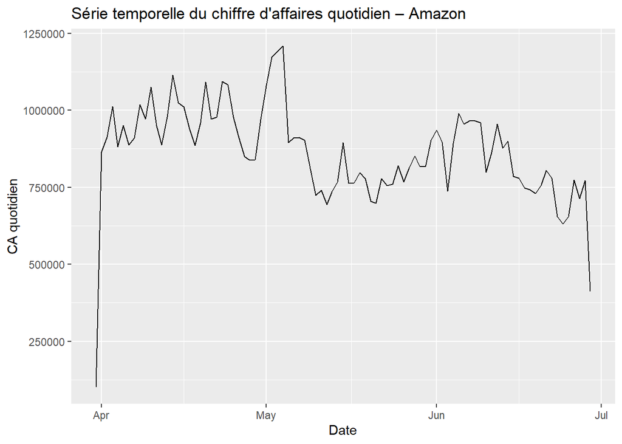

```r
# 1. Ventes Amazon – CA quotidien

amazon_daily <- AmazonSaleReport %>%
  group_by(Date) %>%
  summarise(ca_jour = sum(Amount, na.rm = TRUE),
            qty_jour = sum(Qty, na.rm = TRUE))

ggplot(amazon_daily, aes(x = Date, y = ca_jour)) +
  geom_line() +
  labs(title = "Série temporelle du chiffre d'affaires quotidien – Amazon",
       x = "Date", y = "CA quotidien")
```

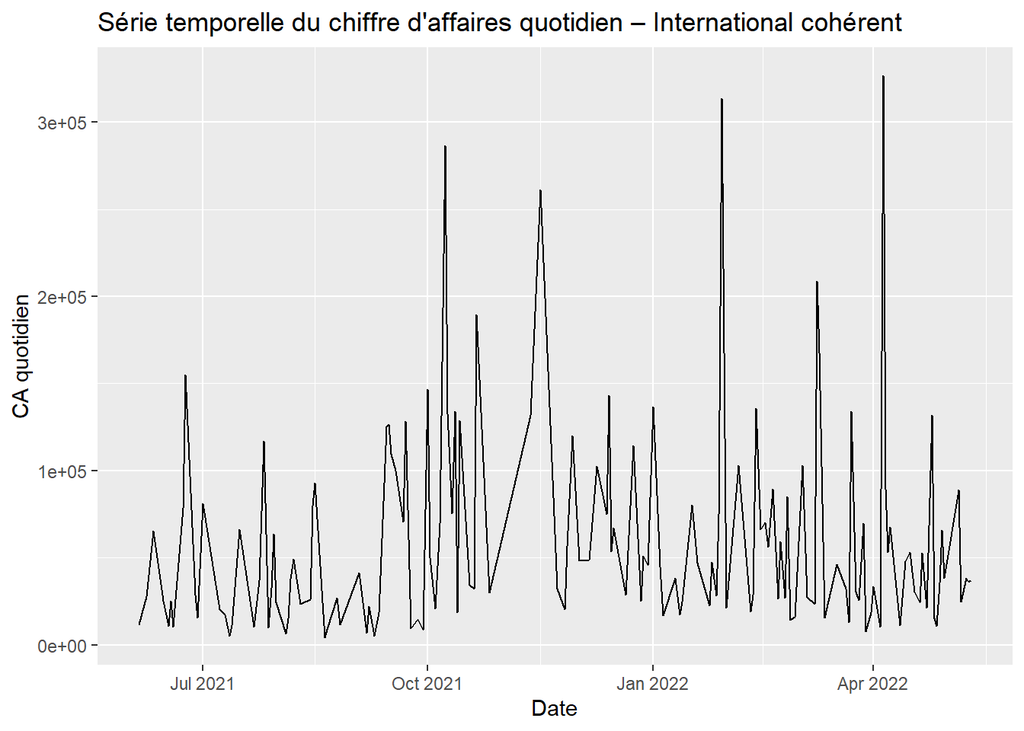

```r
############################################################

# 2.Ventes internationales cohérentes – CA quotidien

intl_daily <- InternationalsaleReport_coherent %>%
  group_by(DATE) %>%
  summarise(ca_jour = sum(GROSS.AMT, na.rm = TRUE),
            pcs_jour = sum(PCS, na.rm = TRUE))

ggplot(intl_daily, aes(x = DATE, y = ca_jour)) +
  geom_line() +
  labs(title = "Série temporelle du chiffre d'affaires quotidien – International cohérent",
       x = "Date", y = "CA quotidien")
```

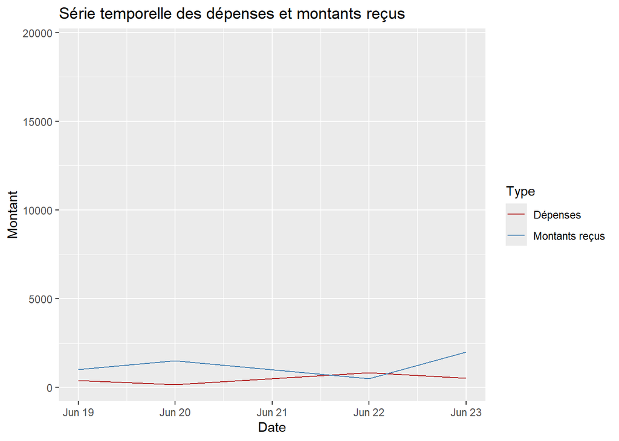

```r
############################################################

# 3. Dépenses internes – montants journaliers

expense_daily <- ExpenseIIGF_clean_final %>%
  group_by(Date) %>%
  summarise(dep_jour = sum(Expense_Amount, na.rm = TRUE),
            recu_jour = sum(Amount_Received, na.rm = TRUE))

ggplot(expense_daily, aes(x = Date)) +
  geom_line(aes(y = dep_jour, colour = "Dépenses")) +
  geom_line(aes(y = recu_jour, colour = "Montants reçus")) +
  labs(title = "Série temporelle des dépenses et montants reçus",
       x = "Date", y = "Montant") +
  scale_colour_manual(values = c("Dépenses" = "firebrick",
                                 "Montants reçus" = "steelblue"),
                      name = "Type")
```

**Interprétations des Séries temporelles**

**1. Amazon – Série temporelle du chiffre d’affaires quotidien**

**Observation générale**

La courbe montre l’évolution quotidienne du chiffre d’affaires Amazon entre avril et juillet. Le niveau global est élevé (entre 700k et 1,2M), avec une variation journalière visible mais contenue. On distingue clairement des cycles courts correspondant à des variations intra-semaine.

**Tendances / relations significatives**

- Une phase initiale ascendante en avril, avec une montée rapide vers la zone 900k–1M.
- Entre fin avril et début mai, une zone de pic clairement identifiable (>1,1M).
- À partir de mi-mai, on observe une légère décroissance progressive, où le CA se stabilise autour de 800–900k.
- Juin montre des oscillations régulières, suggérant des cycles de vente typiques (effets de semaine, promotions, opérations locales).
- Fin juin et début juillet indiquent un ralentissement notable, avec une chute marquée dans les derniers jours.

**Points d’attention**

- La chute brutale les tout derniers jours peut être un artefact de données incomplètes (fin de période).
- L’absence d’annotation des jours clés empêche d’identifier précisément les effets événementiels (promotions, retards logistiques…).
- Les variations pourraient aussi être liées aux différences du nombre de commandes plutôt qu’au prix unitaire.

**Conclusion analytique**

L’activité Amazon est globalement stable et élevée, avec un cycle saisonnier court visible et quelques pics de performance. La dynamique se tasse légèrement après mai, mais l’activité reste soutenue jusqu’en fin de période. Une analyse hebdomadaire complémentaire pourrait aider à confirmer les patrons saisonniers.

**2. InternationalSaleReport_coherent – Série temporelle du CA quotidien**

**Observation générale**

La série couvre une longue période (mi-2021 à mi-2022) et présente un niveau moyen très variable, avec de nombreux jours à faible CA et des pics très aigus. La distribution est fortement hétérogène.

**Tendances / relations significatives**

- De nombreux jours montrent un CA quasi nul ou faible (<20k).
- Quelques pics extrêmes dominent la série (>250k voire >300k), indiquant des événements exceptionnels (gros envois, commandes groupées).
- On note une augmentation du niveau moyen vers la fin 2021 et début 2022, suggérant une montée en charge ou une diversification progressive de l’activité.
- Les pics apparaissent irréguliers, ce qui évoque des opérations ponctuelles plutôt qu’une saisonnalité régulière.

**Points d’attention**

- La très forte dispersion suggère que le business international dépend de quelques opérations majeures plutôt que d’un flux quotidien stable.
- Les valeurs extrêmes peuvent être dues à des ajustements, régularisations ou “batchs” de plusieurs jours consolidés.
- L’absence d’un pattern saisonnier clair complexifie l’analyse prévisionnelle.

**Conclusion analytique**

Les ventes internationales montrent une activité irrégulière mais ponctuellement très lucrative. Le modèle semble événementiel plutôt que récurrent. Une approche statistique robuste (médianes, IQR) est préférable pour caractériser sa performance.

**3. ExpenseIIGF_clean_final – Série temporelle Dépenses vs Montants reçus**

**Observation générale**

La série, courte (19–23 juin), compare deux flux financiers :

- Montants reçus (bleu)
- Dépenses (rouge)

**Tendances / relations significatives**

Les montants reçus augmentent début période (≈1 000 à 1 400), chutent légèrement, puis remontent fortement le 23 juin.

Les dépenses suivent un pattern opposé :

- Descente le 20,
- Remontée autour du 21–22,
- Puis léger recul.

Les deux courbes convergent autour du 21–22 juin, signe d’un moment où le flux financier s’équilibre temporairement.

**Points d’attention**

La période est extrêmement courte pour dégager des tendances lourdes.

Une interprétation plus solide nécessiterait au moins un mois de données.

Le 23 juin pourrait représenter un versement exceptionnel.

```
      5 - VISUALISATIONS : HEATMAPS & TOP ANALYSES
```

Les heatmaps et les analyses « top » permettent une lecture synthétique et visuelle des performances par dimensions : produits, clients, marketplaces, services logistiques, etc. Grâce à une codification par intensité de couleur, les heatmaps révèlent immédiatement les zones d’activité élevée ou faible, les clusters de comportements similaires, ainsi que les écarts anormaux entre catégories.

Les top analyses, quant à elles, mettent en évidence les éléments les plus contributifs — top SKUs, top clients, top marketplaces — essentiels pour des décisions stratégiques (priorisation, pricing, investissement, optimisation logistique). Ces visualisations offrent une compréhension intuitive et hiérarchisée des données, en complément des analyses statistiques et temporelles.

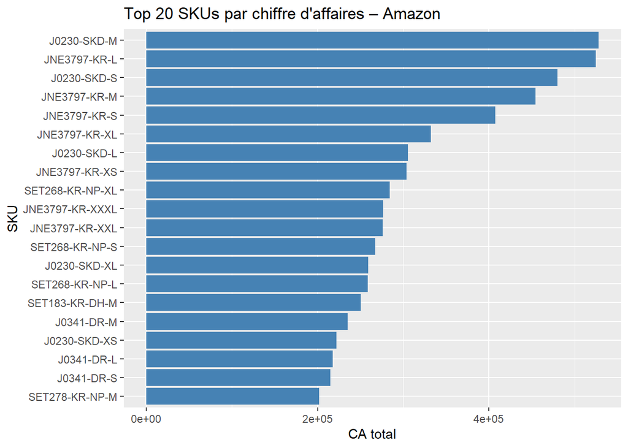

```r
# 1. Top produits – ventes Amazon

amazon_top_sku <- AmazonSaleReport %>%
  group_by(SKU) %>%
  summarise(ca_total = sum(Amount, na.rm = TRUE),
            qty_total = sum(Qty, na.rm = TRUE)) %>%
  arrange(desc(ca_total)) %>%
  slice_head(n = 20)


ggplot(amazon_top_sku, aes(x = reorder(SKU, ca_total), y = ca_total)) +
  geom_col(fill = "steelblue") +
  coord_flip() +
  labs(title = "Top 20 SKUs par chiffre d'affaires – Amazon",
       x = "SKU", y = "CA total")
```

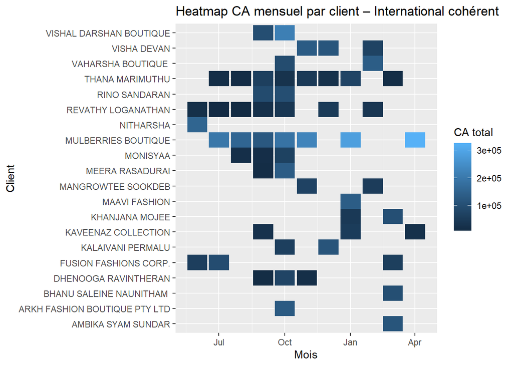

```r
############################################################

# 2. Heatmap CA par mois & client (international cohérent)

intl_client_month <- InternationalsaleReport_coherent %>%
  mutate(Month = floor_date(DATE, unit = "month")) %>%
  group_by(Month, CUSTOMER) %>%
  summarise(ca_total = sum(GROSS.AMT, na.rm = TRUE), .groups = "drop")


# On se limite aux 20 plus gros clients pour la lisibilité
top_clients <- intl_client_month %>%
  group_by(CUSTOMER) %>%
  summarise(ca = sum(ca_total), .groups = "drop") %>%
  arrange(desc(ca)) %>%
  slice_head(n = 20) %>%
  pull(CUSTOMER)


intl_client_month %>%
  filter(CUSTOMER %in% top_clients) %>%
  ggplot(aes(x = Month, y = CUSTOMER, fill = ca_total)) +
  geom_tile() +
  labs(title = "Heatmap CA mensuel par client – International cohérent",
       x = "Mois", y = "Client", fill = "CA total")
```

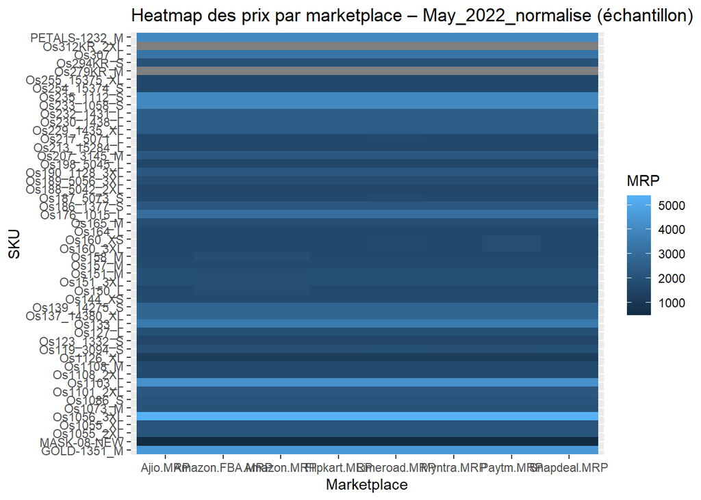

```r
############################################################

# 3. Heatmap prix par marketplace – May 2022

may_heat <- May_2022_normalise %>%
  select(Sku, Ajio.MRP, Amazon.MRP, Amazon.FBA.MRP,
         Flipkart.MRP, Limeroad.MRP, Myntra.MRP,
         Paytm.MRP, Snapdeal.MRP) %>%
  pivot_longer(-Sku, names_to = "Marketplace", values_to = "MRP")


# On garde un échantillon de produits (par ex. 50) pour la lisibilité
set.seed(123)
sample_sku <- sample(unique(may_heat$Sku),
                     size = min(50, length(unique(may_heat$Sku))))

may_heat %>%
  filter(Sku %in% sample_sku) %>%
  ggplot(aes(x = Marketplace, y = Sku, fill = MRP)) +
  geom_tile() +
  labs(title = "Heatmap des prix par marketplace – May_2022_normalise (échantillon)",
       x = "Marketplace", y = "SKU", fill = "MRP")
```

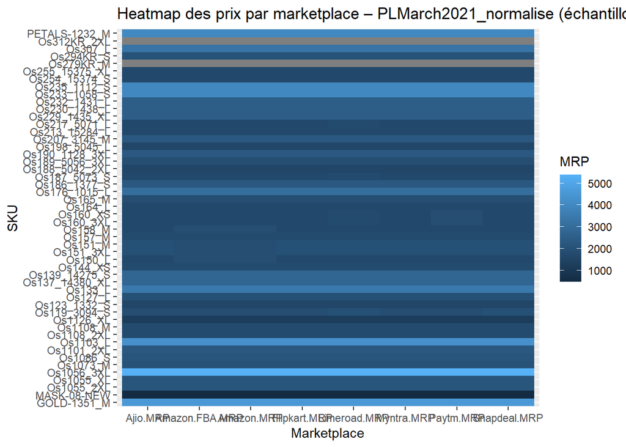

```r
############################################################

# 4. Heatmap prix par marketplace – PLMarch2021

plm_heat <- PLMarch2021_normalise %>%
  select(Sku, Ajio.MRP, Amazon.MRP, Amazon.FBA.MRP,
         Flipkart.MRP, Limeroad.MRP, Myntra.MRP,
         Paytm.MRP, Snapdeal.MRP) %>%
  pivot_longer(-Sku, names_to = "Marketplace", values_to = "MRP")


set.seed(123)
sample_sku_pl <- sample(unique(plm_heat$Sku),
                        size = min(50, length(unique(plm_heat$Sku))))

plm_heat %>%
  filter(Sku %in% sample_sku_pl) %>%
  ggplot(aes(x = Marketplace, y = Sku, fill = MRP)) +
  geom_tile() +
  labs(title = "Heatmap des prix par marketplace – PLMarch2021_normalise (échantillon)",
       x = "Marketplace", y = "SKU", fill = "MRP")
```

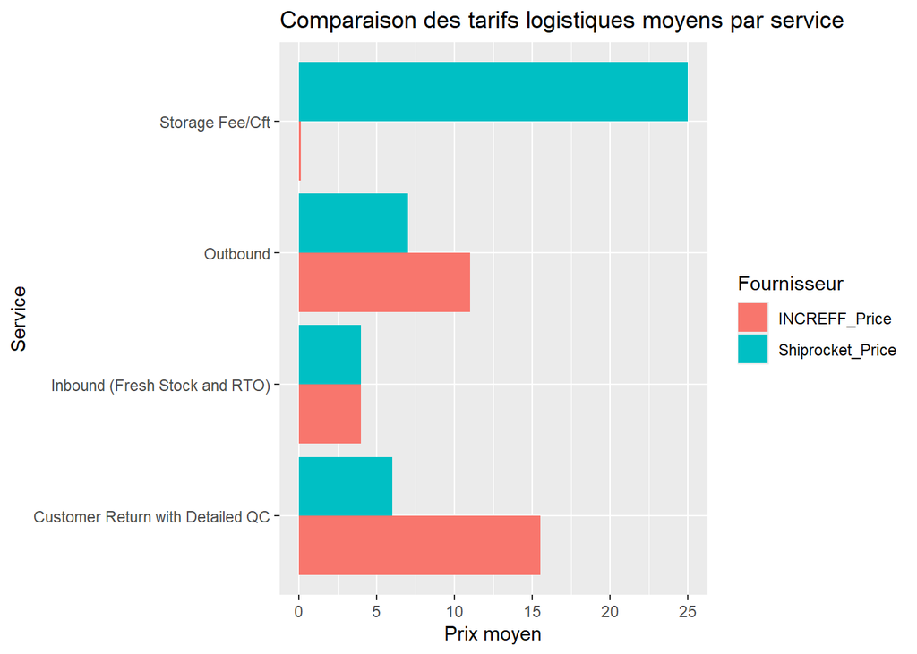

```r
############################################################

# 5. Analyse logistique – comparaison des services `Cloud_clean`

Cloud_clean %>%
  pivot_longer(cols = c(Shiprocket_Price, INCREFF_Price),
               names_to = "Fournisseur", values_to = "Prix") %>%
  group_by(Service, Fournisseur) %>%
  summarise(prix_moyen = mean(Prix, na.rm = TRUE), .groups = "drop") %>%
  ggplot(aes(x = Service, y = prix_moyen, fill = Fournisseur)) +
  geom_col(position = "dodge") +
  coord_flip() +
  labs(title = "Comparaison des tarifs logistiques moyens par service",
       x = "Service", y = "Prix moyen")
```

**Interprétations – Heatmaps & Top Analyses**

**Top 20 SKUs par chiffre d’affaires – Amazon**

**Observation générale**

**Relations significatives**

Trois modèles dominent largement :

- J0230-SKD,
- JNE3797-KR,
- SET268-KR-NP (dans leurs tailles M, L, XL, S…).

Les tailles M, L, XL ressortent systématiquement dans le haut du classement, montrant une forte demande sur ces formats « standard ».

Les versions XS et XXL apparaissent aussi dans le TOP, ce qui indique une gamme de tailles bien équilibrée et une demande diversifiée.

**Points d’attention**

Certains modèles apparaissent plusieurs fois avec de très petites variations (différentes tailles). Il faudra vérifier :

- si la performance provient réellement du modèle,
- ou si le volume est fragmenté entre tailles, réduisant la visibilité réelle.

Absence de SKUs très récents : la liste semble dominée par des modèles historiques.

**Conclusion analytique**

Le portefeuille Amazon repose sur un noyau dur de SKUs à forte rotation, avec une attractivité élevée pour quelques styles. Cette information est essentielle pour optimiser les stocks, les réassorts et même orienter les futures collections.

**2. Heatmap du CA mensuel par client – International cohérent**

**Observation générale**

La heatmap révèle une structure de ventes irrégulière, fortement dépendante de quelques clients saisonniers ou opportunistes. Les couleurs foncées sont concentrées par périodes et non réparties sur l’année.

**Relations significatives**

Thana Marimuthu, ReVathy Loganathan, Mulberries Boutique, Nitharsha, Mangrowtee Sookdeb, Khanjana Mojee montrent des pics marqués à certaines périodes.

Certains clients génèrent des CA extrêmement élevés sur un ou deux mois, ce qui pèse fortement sur la performance totale.

Le mois octobre semble être le plus actif (peut refléter une saison festive / événementielle).

**Points d’attention**

Dépendance à un nombre réduit de clients → risque commercial.

Les ventes sont très volatiles, rendant les prévisions difficiles sans lissage.

Certains clients n’achètent qu’une seule fois dans l’année : vérifier s’il s’agit d’opportunités ponctuelles ou d’un manque de fidélisation.

**Conclusion analytique**

Le marché international cohérent présente un potentiel élevé mais irrégulier, où la fidélisation des clients clés et la compréhension des cycles saisonniers représentent une opportunité stratégique.

**3. Heatmap des prix catalogue par marketplace – May_2022_normalisé (échantillon)**

**Observation générale**

Les prix catalogue (MRP) sont globalement homogènes entre marketplaces, ce qui se traduit par des bandes de couleurs similaires horizontalement.

**Relations significatives**

Les prix les plus élevés (nuances plus claires) sont concentrés sur un petit nombre de produits premium.

**Points d’attention**

Les différences restent faibles → bonne cohérence tarifaire.

**Conclusion analytique**

La politique de prix est globalement bien harmonisée entre marketplaces, limitant les risques de cannibalisation ou de perception négative par les consommateurs.

**4. Heatmap des prix par marketplace – PLMarch2021_normalisé (échantillon)**

**Observation générale**

La tendance est similaire à celle de Mai 2022 : grande homogénéité verticale (pour un même SKU) entre marketplaces.

**Relations significatives**

Le maintien d’une cohérence inter-marché dans le pricing s’observe même un an plus tôt → cela montre une discipline tarifaire stable dans le temps.

Quelques SKUs premium ressortent clairement avec des niveaux MRP très élevés.

**Points d’attention**

Quelques fluctuations périodiques indiquent que certains prix ont été ajustés à des moments différents selon la marketplace.

**Conclusion analytique**

La stratégie tarifaire est constante et cohérente, ce qui soutient l’image de marque et réduit les conflits inter-plateformes.

**5. Comparaison des tarifs logistiques moyens – INCREFF vs Shiprocket**

**Observation générale**

Les deux prestataires présentent des structures de coûts très distinctes selon le service. Shiprocket affiche des prix beaucoup plus élevés pour certains services, alors qu’INCREFF est dominant sur d’autres.

**Relations significatives**

**Customer Return + QC :** ➤ INCREFF est de loin le plus cher (~15), tandis que Shiprocket est modéré (~5).

**Outbound :** ➤ Shiprocket est moins cher (~6), INCREFF autour de (~12).

**Points d’attention**

Le coût du stockage via Shiprocket est extrêmement élevé, ce qui peut impacter fortement les produits à faible rotation.

Le retour client (QC) est prohibitif via INCREFF.

La décision fournisseur doit être optimisée service par service, et non globalement.

**Conclusion analytique**

Aucun fournisseur n’est meilleur sur tout :

Une stratégie hybride permettra d’optimiser les coûts logistiques.

**CONCLUSION GÉNÉRALE DU RAPPORT MI-PARCOURS**

Ce rapport mi-parcours présente l’avancement complet des travaux réalisés sur la base des données issues des différentes sources opérationnelles et externes. Trois étapes majeures ont été menées : la collecte, le nettoyage et l’exploration analytique.

Ensemble, elles constituent le socle indispensable à toute analyse avancée, modélisation ou prise de décision.

**1. Collecte des données : constitution fiable de la base d’analyse**

La première phase a consisté à rassembler l’ensemble des datasets nécessaires à l’étude, incluant notamment :

- Le téléchargement et la récupération des fichiers depuis Kaggle,
- L’importation structurée dans R via un pipeline reproductible,
- La vérification de la cohérence des colonnes, formats et volumes.

Cette étape garantit que toutes les données essentielles à l’analyse sont disponibles, accessibles et intégrées dans un environnement de travail entièrement traçable.

**2. Préparation et nettoyage : sécurisation de la qualité des données**

La seconde phase a porté sur une mise en qualité rigoureuse des tables, essentielle pour éviter les biais d’interprétation. Les actions menées incluent :

- Le traitement des valeurs manquantes (remplissage, suppression ou reformatage selon le cas)
- La détection et suppression des doublons
- L’identification et gestion des outliers, afin de préserver la fiabilité statistique
- La standardisation des formats, notamment :
  - dates converties en type Date
  - variables catégorielles factorisées
  - unités et libellés harmonisés

L’alignement structurel entre datasets (colonnes, types, conventions).

Cette étape permet d’obtenir une base de données propre, homogène et exploitable, garantissant une interprétation analytique robuste et sans artefact.

**3. Exploration des données (EDA) : premières tendances et insights clés**

La troisième phase a consisté en une exploration approfondie des données via plusieurs angles analytiques :

**a) Statistiques descriptives**

Elles ont permis de caractériser les distributions, niveaux moyens, dispersions et comportements atypiques. Ce travail a mis en lumière :

- des variables très asymétriques,
- des valeurs extrêmes structurantes,
- la présence de patterns récurrents selon les modèles, marchés ou périodes.

**b) Analyses de corrélation**

Les matrices et heatmaps ont montré :

- des relations fortes entre certaines variables prix/MRP,
- une cohérence tarifaire élevée selon les marketplaces,
- une absence de corrélation sur d’autres dimensions (stock, quantité, etc.),
- des différences structurelles entre les datasets (Amazon, international, MRP, logistique).

**c) Visualisations avancées**

L’EDA confirme ainsi la présence de comportements structurés, de classes de produits différenciées et de patterns saisonniers qu’il sera possible d’exploiter dans des analyses prédictives ou stratégiques.

Nous abordons les parties 4, 5 et 6 de la méthodologie, parfaitement alignées avec la structure déjà écrite

pour les étapes 1 à 3 ainsi qu’avec les hypothèses H1 à H4. (Ci haut mentionnées)

**4. VISUALISATION & DASHBOARD**

Cette étape vise à transformer les analyses exploratoires en visualisations avancées permettant une compréhension rapide, intuitive et interactive des tendances clés.

L’objectif final est de construire un dashboard dynamique (via Shiny) permettant aux utilisateurs de suivre les indicateurs majeurs, d’explorer les données en autonomie et d’appuyer la prise de décision.

Contenu prévu :

**4.1. VISUALISATIONS AVANCEES**

Courbes d’évolution du CA, du nombre de commandes, du panier moyen.

Heatmaps dynamiques :

- prix par marketplace
- CA par client / SKU / mois

Scatterplots & boxplots :

- variations de prix
- comparaison inter-magasins / inter-pays

Graphiques interactifs (Plotly) pour explorer :

- top produits
- top clients
- périodes de pics ou creux

**4.2. CONSTRUCTION DU DASHBOARD (SHINY)**

- Section Performance globale (CA, nbr commandes, panier moyen).
- Section Top analyses : top SKUs, top catégories, top clients.
- Section Analyse temporelle : filtres par période, saisonnalité.
- Section Logistique : comparaison INCREFF vs Shiprocket.
- Section Prix catalogue : comparaison inter-marketplaces.

**Objectifs :**

- Consolider l’EDA sous forme opérationnelle.
- Identifier très rapidement les zones de performance ou d’anomalie.
- Fournir un outil interactif pour les prochaines analyses (statistiques & ML).

**4.1. VISUALISATIONS AVANCEES**

```r
# install.packages(c("tidyverse","lubridate","plotly","shiny",
#                    "forecast","prophet","randomForest","caret",
#                    "cluster","factoextra","ineq"))

library(tidyverse)
library(lubridate)
library(plotly)
library(shiny)

library(forecast)
library(prophet)

library(randomForest)
library(caret)
library(cluster)
library(factoextra)
library(ineq)
```

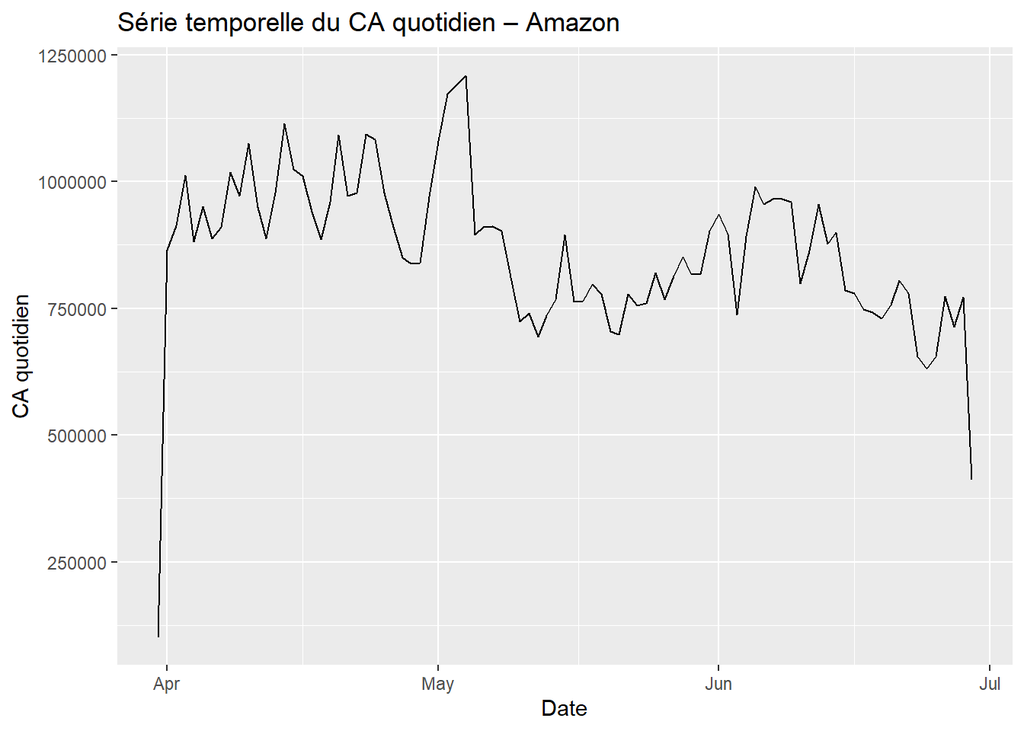

```r
## =============================================================
## Série temporelle Amazon - Évolution du CA quotidien – Amazon
## =============================================================


amazon_daily <- AmazonSaleReport %>%
  group_by(Date) %>%
  summarise(ca_total = sum(Amount, na.rm = TRUE)) %>%
  arrange(Date)


gg_amazon_ts <- ggplot(amazon_daily, aes(x = Date, y = ca_total)) +
  geom_line(color = "black") +
  labs(title = "Série temporelle du CA quotidien – Amazon",
       x = "Date",
       y = "CA quotidien")

gg_amazon_ts
```

```r
# Version interactive
ggplotly(gg_amazon_ts)
```

[interactive chart not shown]

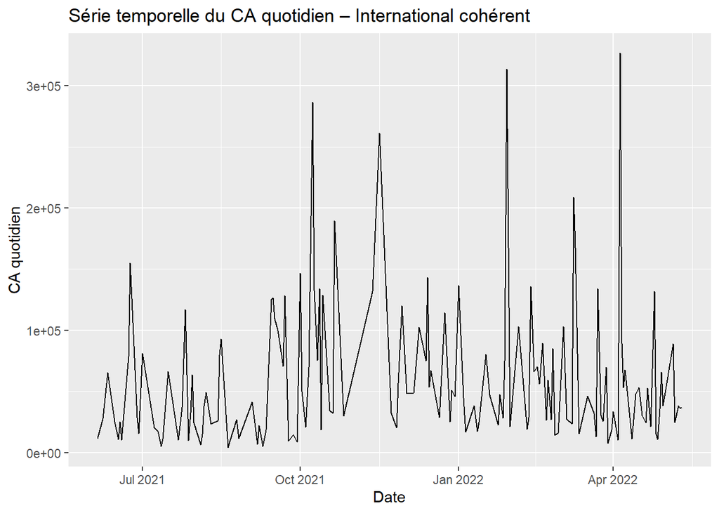

```r
## ====================================================
## Évolution du CA quotidien – International cohérent
## ====================================================


InternationalsaleReport_coherent <- intl_core


# Creer une colonne standard "date" à partir de DATE (le vrai champ)

InternationalSaleReport_coherentD <- InternationalsaleReport_coherent %>%
  mutate(
    date = as.POSIXct(DATE, tz = "UTC"),   # DATE est <dttm>, on garde le temps si besoin
    date = as.Date(date)                  # puis on passe en Date (utile pour agrégations)
  )


intl_daily <- InternationalSaleReport_coherentD %>%
  group_by(date) %>%
  summarise(ca_total = sum(`GROSS.AMT`, na.rm = TRUE), .groups = "drop") %>%
  arrange(date)

gg_intl_ts <- ggplot(intl_daily, aes(x = date, y = ca_total)) +
  geom_line() +
  labs(
    title = "Série temporelle du CA quotidien – International cohérent",
    x = "Date", y = "CA quotidien"
  )


gg_intl_ts
```

```r
ggplotly(gg_intl_ts)
```

[interactive chart not shown]